# **历史**思维和其他非自然行为

What happens to critical reading when attitudinal metadiscourse is delayed until adulthood and readers are not encouraged to become active participants in the reading process?…Young readers need to see author biases and evaluate them at an early age; textbooks and teachers need to teach them how to do this.<sup>116</sup>

教学

Teaching

在1950年至1975年的二十五年间，课堂教学研究明显带有行为主义色彩，主要关注诸如课堂提问频率和教师回应的强化作用等具体的教学行为。这种方法的核心假设是各学科之间存在根本的相似性。内容上的差异被视为“情境变量”，即便有所提及，也只是在对研究结果局限性的简短讨论中出现。在20世纪60年代和70年代，教学研究在具体技能的教学方面取得了最大的成功，教师会检查学生对某个具体结果的理解程度，然后指导学生完成类似的练习或习题。但正如巴拉克·罗森沙因在分析时任教育部长威廉·贝内特讲授的关于《联邦党人文集》第十篇的历史课时所指出的那样，技能教学的研究几乎没有涉及内容教学：“我们甚至没有一个合适的名称来描述它……如何教授这些内容和思想？技能模式对我们帮助不大。” <sup>117</sup>

For the twenty-five years between 1950 and 1975, research on classroom teaching had a decidedly behaviorist cast that focused on discrete teaching acts like the frequency of classroom questions and the reinforcing qualities of teacher's responses. At the core of this approach was an assumption about the fundamental similarity among the school subjects. Variations in content were cast as “context variables” and emerged (if at all) in brief discussions about the limitations of research findings. Throughout the 1960s and 1970s, research on teaching witnessed its greatest success in the teaching of discrete skills, in which a teacher checks for understanding on a concrete outcome and then guides students in doing similar problems or exercises. But as Barak Rosenshine noted in his analysis of a history lesson on Federalist No. 10, taught by then-Secretary of Education William Bennett, research on skill teaching had virtually nothing to say about the teaching of content: “We do not even have a good name for it…. How does one teach this content and these ideas? The skill model does not help us much.”<sup>117</sup>

斯坦福大学的李·舒尔曼（Lee Shulman）称教学内容研究的匮乏是一个“缺失的范式”，并着手开展一项研究计划来解决这个问题。 <sup>118</sup> “教学知识增长项目”（1983-1989）是一项纵向研究，追踪教师从师范教育项目开始到全职教学的第一年和第二年的知识变化。对四位历史/社会研究教师的知识增长情况的考察是该项目最早的研究报告之一（见本书第六章）。

Stanford University's Lee Shulman called the lack of research on teaching content a “missing paradigm” and went on to develop a research program to address it.<sup>118</sup> The Knowledge Growth in Teaching Project (1983–89) was a longitudinal study that tracked changes in teacher's knowledge from the beginning of their teacher education programs into the first and second years of full-time teaching. An examination of the knowledge growth of four history/social studies teachers was one of the first research reports (see Chapter 6 of this volume) to emerge from this project.

为了进一步探讨学科知识与教学之间的关系，我们开展了一系列“实践智慧”研究。在这些研究中，我们观察了11位杰出教师教授美国革命单元的过程。教师们还参与了一系列访谈，访谈形式多样，包括“知识自传”（教师们在访谈中重述了他们中学和大学教育的精彩瞬间）以及改良版的“出声思考法”（教师们在阅读华盛顿告别演说、《联邦党人文集》第84篇（汉密尔顿反对权利法案的论证）和其他原始文献时，将自己的想法表达出来）。（详见第八章，其中有相关示例。）

Work on the relationship between subject matter knowledge and teaching was extended in a series of “Wisdom of Practice” studies in which eleven accomplished teachers were observed teaching a unit on the American Revolution. Teachers also engaged in a series of interviews, ranging from an “intellectual autobiography” in which they reconstructed the high points of their high school and college education, to modified think-alouds in which they verbalized their thoughts as they read Washington's Farewell Address, Federalist No. 84 (Hamilton's argument against a bill of rights), and other primary documents. (See Chapter 8 for examples of this work.)

盖亚·莱因哈特是最早将认知原理应用于教学研究的研究者之一，她对理解历史教学所需的技能也做出了重大贡献。<sup>119</sup>在一项基于76节AP美国历史课的案例研究中，莱因哈特重点关注了一位经验丰富的历史教师的历史讲解方式，并区分出两种主要类型。 <sup>120</sup> 在“块状讲解”中，教师提供独立、相对模块化的解释。在“伊卡特讲解”中，教师给出简要的叙述或对某些内容进行简要提及，之后再进行扩展和阐述。在学年伊始，由于学生们难以理解宪法批准过程中的多重因果关系，或者难以理解比尔德和霍夫施塔特等人的不同解读，几乎所有的讲解都由教师完成。随着学年的进行，教师逐渐引导学生参与到构建解释的过程中。衡量她成功的一个指标是学生发言与教师发言的比例，年初时约为 40%，到第十三周时增长了近四倍。

Gaea Leinhardt, one of the first researchers to apply cognitive principles to research on teaching, has also made major contributions to understanding the skills that teaching history demands.<sup>119</sup> In a case study of an experienced history teacher based on over seventy-six sessions in an Advanced Placement U.S. history class,<sup>120</sup> Leinhardt focused on the teacher's historical explanations, distinguishing two main types. In “blocked explanations” the teacher provided a self-contained, relatively modular explanation. In “ikat explanations” the teacher gave an abbreviated account or made a passing reference to something that was later extended and elaborated. At the beginning of the school year, the teacher provided nearly all the explanations, as students struggled with notions of multiple causation in the ratification of the Constitution or the conflicting interpretations of a Beard or a Hofstadter. As the year went on, the teacher progressively drew students into the process of formulating explanations. One measure of her success was the proportion of student talk to teacher talk, which was about 40 percent at the beginning of the year and increased almost fourfold by the thirteenth week.

学生参与度的提高也具有重要的质性意义。学生们不仅仅是对老师的讲解做出更多回应；他们回应的内容也日益复杂。到一月份，莱因哈特分析的学生之一保罗已经将棉花经济的衰落与英国的贸易政策和在亚洲的殖民扩张，以及南方领导人未能把握英国的民意联系起来。学生们不仅学习了大量的事实材料，还学习如何运用这些材料构建他们自己相互关联的历史解释。<sup>121</sup>

This increase in student participation had an important qualitative dimension as well. Students were not simply saying more in response to the teacher's explanations; the content of their responses was characterized by an ever-increasing complexity. By January, Paul, one of the students Leinhardt analyzed, had linked the fall of a cotton-based economy to British trade policy and colonial ventures in Asia as well as to the failure of southern leaders to read public opinion in Great Britain. Students were learning not only a body of factual material but also how to use this material to craft their own interconnected historical explanations.<sup>121</sup>

对教师知识的研究标志着与20世纪70年代和80年代初的教学研究截然不同。研究人员放弃了行为观察法，转而采用深入访谈和针对少数教师的重点观察。与每六个月进行一两个小时的简短观察不同，这些课堂观察力求保持教学的流畅性，通常持续一个单元，但像莱因哈特那样，有时甚至长达近半年。这项研究也涉足了新的方法论领域，借鉴并改进了人类学家或社会语言学家常用的方法，而非心理学家常用的方法。这些研究并非试图构建适用于所有学科的教学理论，而是旨在生成适用于特定学科教学的中层理论，这些理论范围更窄，更具暂时性，或许对物理或体育教学有所启发，也或许没有。<sup>122</sup>这项工作的重点不是脱离教师思想的教师行为，而是教师的知识和他们的行为之间深刻而根本的联系。

The work on teacher knowledge represents a significant departure from the research on teaching that characterized the 1970s and early 1980s. Researchers abandoned behavioral observation schemes for intensive interviews and focused observations of a small number of teachers. Rather than brief samples of an hour or two every six months, observations in these classes tried to preserve the flow of instruction, usually over a unit but, as in Leinhardt's case, sometimes for nearly half a year. This work also ventured into new methodological territory, borrowing and modifying methods more commonly found in the anthropologist's or sociolinguist’ toolbox than in the psychologist's laboratory. Rather than attempting to formulate a theory of instruction that would hold for all subjects, these investigations aimed at generating theories of the middle range, narrower and more provisional theories that applied to the teaching of a particular subject, theories that might or might not have implications for teaching physics or physical education.<sup>122</sup> The focus of this work was not teacher behavior isolated from teacher thought, but the deep and fundamental nexus between what teachers know and what they do.

这项研究描绘了令人信服的优秀教学案例。然而，这项研究的优势——对知识运用过程的细致刻画——也可能正是其不足之处。如同博物馆的展品吸引眼球，将目光聚焦于当下，这些案例更多地展现了现状，而非其形成过程。这些教师的学科知识是本科教育的产物，还是与之相关的因素？他们是如何引导学生将历史作为一种认知方式的？他们的失败是什么样的？他们又是如何从中吸取教训的？既然没有哪个教师能够通过参加为期两天的历史阐释工作坊就成为大师，那么我们该如何改变教师根深蒂固的关于历史本质的认知观念？最后一个问题尤为重要，因为这项关于教学的新研究的核心假设是：从专家身上汲取的经验可以用于指导新手。但是，我们究竟该如何将这些卓越的案例转化为能够培养卓越教师的教学方案呢？这些只是关于教师历史学科知识的新研究中提出的一些尚未解答的问题。

This research offers compelling portraits of exemplary teaching. But the strength of this work—its finely etched accounts of knowledge use in action—may also be its weakness. Like museum pieces that arrest the attention and focus it on the here and now, these images tell us more about what is than about how it came to be. Was the subject matter knowledge of these teachers a consequence of their undergraduate training or a covariate of it? How did these teachers learn to socialize students into history as a way of knowing? What did their failures look like, and how did they learn from them? Since no teacher is going to become a master by taking a two-day workshop on developing historical explanations, how do we alter teacher's deep-seated epistemic beliefs about the nature of history? This last question has special meaning, for at the core of this new work on teaching is the assumption that the lessons learned from experts can be used to teach novices. But how, exactly, do we turn portraits of excellence into programs that develop it? These are just some of the unanswered questions that arise from new research on teacher's subject matter knowledge in history.

结论

CONCLUSION

当前历史教学与学习研究的特点是研究方法多样，体现了认知方法的活力。在某些领域，历史并非其他学科研究成果的最终受益者，而是这些成果最初萌芽和扎根的地方。

Current research on history teaching and learning is characterized by diverse investigations that reflect the vigor of cognitive approaches. In several areas, history has not been the final beneficiary of insights gleaned from research on other subjects, but the site where these insights first germinated and took root.

有几个理由表明，人们对历史的重新关注绝非昙花一现。教育工作者和政策制定者日益认识到，历史推理问题的影响远远超出了历史课程的范畴。<sup>123</sup>历史蕴藏着大量复杂而丰富的问题，与我们在日常生活中面临的社会问题颇为相似。探究这些问题需要一种超越“在文本中查找信息”技能的解读能力，而这种技能在许多学校作业中占据主导地位。了解学生如何应对这种复杂性，以及教师如何帮助他们应对，不仅能为改进学校历史教学提供知识基础，还能丰富阅读理解理论——令人惊讶的是，这些理论对人们如何解读复杂文本的过程却鲜有提及。<sup>124</sup>

There are several reasons to think that the new interest in history is more than a passing fad. There is a growing recognition by educators and policymakers that questions of historical reasoning carry implications that go well beyond the curricular borders of history.<sup>123</sup> History offers a storehouse of complex and rich problems, not unlike those that confront us daily in the social world. Examining these problems requires an interpretive acumen that extends beyond the “locate information in the text” skills that dominate many school tasks. Understanding how students deal with such complexity, and how teachers aid them in doing so, would not only provide a knowledge base for improving school history but would also inform theories of reading comprehension, which are surprisingly mute about the processes used to form interpretations of complex written texts.<sup>124</sup>

还有三项发展有望继续引领历史研究的潮流。首先，近年来人们对叙事的关注日益增加，叙事的形成被视为一种“认知成就” <sup>125</sup> ，而将这一关注扩展到历史叙事的形成领域，无疑将大有裨益<sup>126</sup> 。专业历史学家们已经开始以日益增强的自我意识来探讨这一主题，而心理学家们也将在此方面做出重要贡献<sup>127</sup> 。其次，超媒体和计算机数据库等新技术为历史研究创造了几年前难以想象的可能性。目前正在开展多项研究，探索技术在增进历史理解方面的作用<sup>128</sup> 。最后，历史研究已成为学生和教师评估领域新发展的先河，并有望在未来继续成为一个充满活力的发展领域 <sup>129</sup> 。

Three additional developments promise to keep the spotlight on history. First, recent attention to narrative, which sees the formation of narrative as a “cognitive achievement”<sup>125</sup> stands to gain much by extending its scope to the formation of historical narratives.<sup>126</sup> This topic is already being taken up with increasing self-awareness by professional historians, and psychologists would have much to contribute to this effort.<sup>127</sup> Second, new technologies such as hypermedia and computer data bases have created possibilities in history that were unimaginable a few years ago. A variety of efforts are under way that explore technology's role in enhancing historical understanding.<sup>128</sup> Finally, history has already been the site of new developments in student and teacher assessment and promises to continue to be a rich development site in the future.<sup>129</sup>

对历史感兴趣的心理学家历来都从浩瀚的史学著作中寻找线索，以探究历史思维的本质。这些主要由历史学家和历史哲学家撰写的论文和专著，并非着眼于历史作品揭示的1812年战争、中世纪的日常生活或法属印度支那的灭亡，而是探究它们对更普遍的历史认知方式的阐释。<sup>130</sup>仔细研读历史著作并从中推断其创作过程的策略，能够提供诸多洞见。然而，运用这种方法构建教学理论的问题在于……学习的本质在于，历史思维的最终产物可以通过诉诸完全不同的中间过程来解释。<sup>131</sup>史学教我们如何识别熟练的认知，但对于如何获得这种认知却鲜有指导。

Psychologists interested in history have traditionally looked to the extensive body of historiographic writings for clues to the nature of historical thinking. This storehouse of essays and monographs, composed largely by historians and philosophers of history, looks at historical works not for what they disclose about the War of 1812, daily life in the Middle Ages, or the demise of French Indochina, but for what they say about historical knowing more generally.<sup>130</sup> The strategy of looking carefully at written histories and inferring from them the processes used in their composition offers many insights. The problem with using this approach to build a theory of teaching and learning is that the final products of historical thinking can be explained by appealing to wholly different intermediate processes.<sup>131</sup> Historiography teaches us how to recognize skilled cognition but gives us scant advice for how to achieve it.

理解历史思维的第二种途径。这种方法不如史学传统那样成熟，它考察了历史解释和结论形成过程中的步骤和误区。这项工作由研究者开展，他们进行实证研究，探究学生、教师和历史学家如何理解历史。 <sup>132</sup>它提出的问题涉及人们知道什么以及他们如何获得这些知识。通过这种方式，这种方法将认识论问题从虚无缥缈的表象中剥离出来，使其成为实证探究的对象。 <sup>133</sup>

There is a second way to understand what it means to think historically. Less developed than the historiographic tradition, this approach examines the steps and missteps that lead to the formation of historical interpretations and conclusions. This work is carried out by researchers who conduct empirical studies into how students, teachers, and historians come to understand history.<sup>132</sup> It asks questions about what people know and how they come to know it. In so doing, this approach wrests questions of epistemology from the clouds and turns them into objects of empirical inquiry.<sup>133</sup>

此类研究可以追溯到二十世纪初，当时美国心理学会和美国哲学学会举行联合会议，因为心理学家和哲学家往往是同一人。作为一种研究策略，这种方法的思想渊源并非来自对哲学问题缺乏耐心的爱德华·桑代克 <sup>134</sup> ，而是来自威廉·冯特。与他作为一位致力于将心理学确立为一门实证科学的实验主义者的大众形象相反<sup>135</sup>，鲜为人知的冯特是一位实证研究与他的认识论、逻辑学和伦理学著作相互交融的学者，他认为心理学和哲学相互依存，二者一旦分离，都将衰落 <sup>136</sup> 。历史理解本质上是一项跨学科的事业，只有采用多学科方法才能接近其复杂性。在这方面，目前的努力表明，未来将比过去更加丰富。

Such research would hark back to the beginning of the twentieth century, when the American Psychological Association and the American Philosophical Society held joint meetings because the psychologist and the philosopher were often one and the same. As a research strategy, this approach would trace its intellectual ancestry not to Edward Thorndike, who displayed little patience with questions philosophical,<sup>134</sup> but to Wilhelm Wundt. Contrary to his popular image as an experimentalist singularly determined to establish psychology as an empirical science,<sup>135</sup> the lesser known Wundt was a man whose empirical investigations informed and were informed by his writings on epistemology, logic, and ethics, a man who argued that psychology and philosophy were so interdependent that, separated from one another, both would atrophy.<sup>136</sup> At its heart, historical understanding is an interdisciplinary enterprise, and nothing less than a multidisciplinary approach will approximate its complexity. In this regard, present efforts suggest that the future will be richer than the past.

笔记

NOTES

本章最初发表于罗伯特·卡尔菲和戴维·柏林纳编辑的*《教育心理学手册》*（纽约，1996年）。自该书出版以来，关于历史教学与学习的新研究成果呈爆炸式增长。相关论文集包括彼得·N·斯特恩斯、彼得·塞克斯和萨姆·温伯格合著的*《历史的认知、教学与学习：国家与国际视角》*（纽约，2000年），以及詹姆斯·F·沃斯和马里奥·卡雷特罗*合著的《历史中的学习与推理》*（俄勒冈州波特兰，1998年）。另请参阅*《叙事与生活史杂志》*（1994年第4期）和*《文化与心理学》*（1994年第1期）的特刊。这两部著作均由詹姆斯·V·沃奇编辑。更新的文献综述包括：理查德·帕克斯顿和萨姆·温伯格合著的短文《历史教学》，载于《*劳特利奇国际教育指南*》 （伦敦，2000年）；苏珊娜·M·威尔逊的《历史教学评论》，载于弗吉尼亚·理查森主编的《*教学研究手册》*（纽约，2001年）；以及詹姆斯·沃斯的《历史学习中的问题》*，载于《教育问题：教育心理学贡献》*第4卷第2期（1998年），第163-209页。本文所载的评论已略作更新和编辑，以方便普通读者阅读。

This chapter originally appeared in the *Handbook of Educational Psychology*, edited by Robert Calfee and David Berliner (New York, 1996). Since its appearance there has been an explosion of new work on teaching and learning history. Edited collections of this work include Peter N. Stearns, Peter Seixas, and Sam Wineburg, *Knowing, Teaching, and Learning History: National and International Perspectives* (New York, 2000), and James F. Voss and Mario Carretero, *Learning and Reasoning in History* (Portland, Oreg., 1998). See, as well, the special issues of the *Journal of Narrative and Life History* (1994, no. 4) and *Culture & Psychology* (1994, no. 1), both of which were edited by James V. Wertsch. Updated literature reviews include a short co-written piece, Richard Paxton and Sam Wineburg, “History Teaching” in the *Routledge International Companion to Education* (London, 2000); Suzanne M. Wilson, “Review of History Teaching” in Virginia Richardson, ed., *Handbook of Research on Teaching* (New York, 2001); and James Vos's “Issues in the Learning of History” *Issues in Education: Contributions from Educational Psychology* 4, no. 2 (1998), 163–209. The review that appears here has been updated slightly and edited for a general audience.

1.我仅关注英文文献，但也承认其他语言中也存在重要的研究成果。例如，参见 J. Pozo 和 Mario Carretero 合著的《青少年作为历史学家》（“El Adolescente Como Historiador”），*载于《儿童与学习》（Infancia y Aprendizaje）* 23 (1983)，75–90；Bodo von Borries 的《历史学习与自我发展》（“Geschichtslernen und Persönlichkeits-entwick-lung”），载于《历史教学》（*Geschichts-Didaktic*）12 (1987)，1–14；以及 V. A. Kol'tsova 的《沟通中认知活动的实验研究（以概念形成为例）》（“Experimental Study of Cognitive Activity in Communication (with Specific Reference to Concept Formation)”），载于《苏联心理学》（*Soviet Psychology* ） 17 (1978)，23–38。有关欧洲和中东历史教学趋势的概述，请参阅 Bodo von Borries 编辑的《*青年与历史：欧洲青少年历史意识和政治态度比较调查》*（德国汉堡，1997 年）。

1. I limit my focus to work in English while recognizing that important work has appeared in other languages. See, for example, J. Pozo and Mario Carretero, “El Adolescente Como Historiador” [The adolescent as historian], *Infancia y Aprendizaje* 23 (1983), 75–90; Bodo von Borries, “Geschichtslernen und Persönlichkeits-entwick-lung” [The learning of history and the development of self], *Geschichts-Didaktic* 12 (1987), 1–14; V. A. Kol'tsova, “Experimental Study of Cognitive Activity in Communication (with Specific Reference to Concept Formation)” *Soviet Psychology* 17 (1978), 23–38. For an overview of trends in history teaching in Europe and the Middle East, see Bodo von Borries, ed., *Youth and History: A Comparative European Survey on Historical Consciousness and Political Attitudes Among Adolescents* (Hamburg, Germany, 1997).

2.例如，Michael Frisch，“美国历史与集体记忆的结构：经验图像学的初步练习”，《美国*历史杂志*》 75（1989），1130-55；M. M. Miller 和 Peter N. Stearns，“在历史教学中应用认知学习方法：世界历史课程的实验”，*《历史教师*》 28（1995），183-204；Peter Seixas，“多元文化背景下青少年对历史的理解”，*《课程探究》* 23（1993），301-27；以及 Peter Seixas，“当心理学家讨论历史思维时：历史学家的视角”，*《教育心理学家》* 29（1999），107-9。

2. For example, Michael Frisch, “American History and the Structure of Collective Memory: A Modest Exercise in Empirical Iconography” *Journal of American History* 75 (1989), 1130–55; M. M. Miller and Peter N. Stearns, “Applying Cognitive Learning Approaches in History Teaching: An Experiment in a World History Course” *History Teacher* 28 (1995), 183–204; Peter Seixas, “Historical Understanding Among Adolescents in a Multicultural Setting” *Curriculum Inquiry* 23 (1993), 301–27; and Peter Seixas, “When Psychologists Discuss Historical Thinking: A Historian's Perspective” *Educational Psychologist* 29 (1999), 107–9.

3. Michelene T. H. Chi、Paul J. Feltovich 和 Robert Glaser，“专家和新手对物理问题的分类和表示”，*认知科学*5 (1981)，121-52。

3. Michelene T. H. Chi, Paul J. Feltovich, and Robert Glaser, “Categorization and Representation of Physics Problems by Experts and Novices” *Cognitive Science* 5 (1981), 121–52.

4.有关早于此传统的英国著作的例子，请参阅 Frances Collie的《小学历史课程中的问题教学法》，载于《*实验教育学与培训学院记录》* 1 (1911)，第 236-39 页；以及 R. E. Aldrich 的《新历史：历史视角》，载于 Alaric K. Dickinson、Peter J. Lee 和 Peter J. Rogers 编，《*学习历史》*（伦敦，1984 年），第 210-24 页。

4. For an example of British work that predates this tradition, see Frances Collie, “The Problem Method in the History Courses of the Elementary School” *Journal of Experimental Pedagogy and Training College Record* 1 (1911), 236–39; and R. E. Aldrich, “New History: An Historical Perspective” in Alaric K. Dickinson, Peter J. Lee, and Peter J. Rogers, eds., *Learning History* (London, 1984), 210–24.

5. Edward L. Thorndike，*《教育心理学简明教程》*（纽约，1923 年），第 345 页。

5. Edward L. Thorndike, *Educational Psychology—Briefer Course* (New York, 1923), 345.

6. Edward L. Thorndike，*《教育：第一本书》*（纽约，1912 年），第 144 页。

6. Edward L. Thorndike, *Education: A First Book* (New York, 1912), 144.

7. G. Stanley Hall，*《教育问题》*，第2 卷（纽约，1911 年），第 285-286 页。

7. G. Stanley Hall, *Educational Problems*, vol. 2 (New York, 1911), 285–86.

8.同上，第 296 页。

8. Ibid., 296.

9.查尔斯·哈伯德·贾德，*《高中生心理学》*（波士顿，1915 年），第 384 页。

9. Charles Hubbard Judd, *Psychology of High-School Subjects* (Boston, 1915), 384.

10.美国历史学会七人委员会，《学校*历史研究》*（纽约，1899 年）。

10. Committee of Seven, American Historical Association, *The Study of History in Schools* (New York, 1899).

11.五人委员会，美国历史学会，*《中学历史研究》*（纽约，1911 年）。

11. Committee of Five, American Historical Association, *The Study of History in Secondary Schools* (New York, 1911).

12. Judd，《*高中科目》*，第379页。

12. Judd, *High-School Subjects*, 379.

13. J. Carleton Bell，“历史感”，*《教育心理学杂志》* 8 （1917），317。

13. J. Carleton Bell, “The Historic Sense” *Journal of Educational Psychology* 8 (1917), 317.

14.同上，第 317 页。

14. Ibid., 317.

15.同上，第 318 页。

15. Ibid., 318.

16.同上。

16. Ibid.

17.同上。

17. Ibid.

18. J. Carleton Bell 和 David F. McCollum，“美国历史上学生成就的研究”，*《教育心理学杂志*》8（1917 年），257-74。

18. J. Carleton Bell and David F. McCollum, “A Study of the Attainments of Pupils in United States History” *Journal of Educational Psychology* 8 (1917), 257–74.

19.同上，第 257 页。

19. Ibid., 257.

20.同上。

20. Ibid.

21.同上，第 258 页。

21. Ibid., 258.

22.同上。

22. Ibid.

23.同上。

23. Ibid.

24.同上，第 268-69 页。

24. Ibid., 268–69.

25. D. H. Eikenberry，“高中学习的持久性”，*《教育心理学杂志*》14（1923），463-81。

25. D. H. Eikenberry, “Permanence of High School Learning” *Journal of Educational Psychology* 14 (1923), 463–81.

26. Allan Nevins，“美国人的美国历史”，《*纽约时报杂志》*（1942 年 5 月 3 日），第 6、28-29 页；参见Bernard DeVoto，“安乐椅”，《*哈珀斯杂志》*（1943 年 6 月），第 129-132 页；Diane Ravitch 和 Chester E. Finn, Jr.，《*我们的 17 岁青少年知道什么？**关于第一次全国历史和文学评估的报告》*（纽约：1987 年）。

26. Allan Nevins, “American History for Americans” *New York Times Magazine* (May 3, 1942), 6, 28–29; cf. Bernard DeVoto, “The Easy Chair” *Harper's Magazine* (June 1943), 129–32; Diane Ravitch and Chester E. Finn, Jr., *What Do Our 17-Year-Olds Know? A Report on the First National Assessment of History and Literature* (New York: 1987).

27. Chester E. Finn 和 Diane Ravitch，“调查结果：美国17 岁青少年对历史和文学的了解少得惊人”，《*美国学校董事会杂志》* 174 (1987)，32。

27. Chester E. Finn and Diane Ravitch, “Survey Results: U.S. 17-Year-Olds Know Shockingly Little About History and Literature” *American School Board Journal* 174 (1987), 32.

28.这种“可耻”的描述出自 Ravitch 和 Finn 的《*17 岁青少年》*，第 201 页。参见Jack Granatstein 的《*谁扼杀了加拿大历史？》*（多伦多，1998 年），其中也提到了加拿大语境下的类似情况。关于 Granatstein 未能将其研究结果置于比较语境中进行考察的深刻批评，请参见 Chris Lorenz 的《比较史学：问题与视角》，载于《*历史与理论*》第 38 卷（1999 年），第 25-39 页。

28. This characterization as “shameful” comes from Ravitch and Finn, *17- Year-Olds*, 201. See the parallels in a Canadian context, Jack Granatstein, *Who Killed Canadian History?* (Toronto, 1998). For a penetrating critique of Granatstein's failure to consider his findings in a comparative context, see Chris Lorenz, “Comparative Historiography: Problems and Perspectives” *History and Theory* 38 (1999), 25–39.

29. Dale Whittington，“17 岁青少年过去知道些什么？”*美国教育研究杂志*28 (1991)，759–80。

29. Dale Whittington, “What Have 17-Year-Olds Known in the Past?” *American Educational Research Journal* 28 (1991), 759–80.

30. Garry C. Myers，“历史中的延迟回忆”，《*教育心理学杂志*》8（1917），275-83。

30. Garry C. Myers, “Delayed Recall in History” *Journal of Educational Psychology* 8 (1917), 275–83.

31.同上，第 277 页。

31. Ibid., 277.

32.同上，第 282 页。

32. Ibid., 282.

33.同上。

33. Ibid.

34. Garry C. Myers，“回忆中的困惑”，*《教育心理学杂志》* 8（1917），174；Francis C. Bartlett，*《记忆：实验和社会心理学研究》*（纽约，1932）。

34. Garry C. Myers, “Confusion in Recall” *Journal of Educational Psychology* 8 (1917), 174; Francis C. Bartlett, *Remembering: A Study in Experimental and Social Psychology* (New York, 1932).

35. Myers，“混乱”175。有关艾宾豪思想的概述，请参阅 Gordon H. Bower 和 Ernest R. Hilgard 的《*学习理论》*，第 5 版（新泽西州恩格尔伍德克利夫斯，1981 年）。

35. Myers, “Confusion” 175. For an overview of Ebbinhau's ideas, see Gordon H. Bower and Ernest R. Hilgard, *Theories of Learning*, 5th ed. (Englewood Cliffs, N.J., 1981).

36.迈尔斯， 《混乱》175。

36. Myers, “Confusion” 175.

37. David P. Ausubel，“学习中预先组织者的使用”对有意义的语言材料的保留” *《教育心理学杂志》* 51（1960），267-72。

37. David P. Ausubel, “The Use of Advance Organizers in the Learning and Retention of Meaningful Verbal Material” *Journal of Educational Psychology* 51 (1960), 267–72.

38. B. R. Buckingham，“美国历史教学效果指标建议”，《*教育研究杂志*》1（1920），164。

38. B. R. Buckingham, “A Proposed Index in Efficacy in Teaching United States History” *Journal of Educational Research* 1 (1920), 164.

39. M. J. Van Wagenen，《*小学生的历史信息和判断力》*（纽约，1919 年）。

39. M. J. Van Wagenen, *Historical Information and Judgment in Pupils of Elementary Schools* (New York, 1919).

40. Buckingham，“拟议指数”168 。

40. Buckingham, “Proposed Index” 168.

41.同上，第 170 页，原文强调。

41. Ibid., 170, emphasis in original.

42.同上，第 171 页。

42. Ibid., 171.

43. F. S. Camp，“需要：历史尺度制造者”教育*研究杂志*2 (1920)，517。

43. F. S. Camp, “Wanted: A History Scale Maker” *Journal of Educational Research* 2 (1920), 517.

44.同上，第 518 页。

44. Ibid., 518.

45.同上。

45. Ibid.

46.例如，C. L. Harlan，“历史领域的教育测量”，*《教育研究杂志*》2（1920），849-53；C. W. Odell，“美国历史中的巴尔诊断测试”，《*学校与社会*》16（1922），501-3；以及L. W. Sackett，“美国历史中的量表”，*《教育心理学杂志》* 10（1919），345-48。

46. For example, C. L. Harlan, “Educational Measurement in the Field of History” *Journal of Educational Research* 2 (1920), 849–53; C. W. Odell, “The Barr Diagnostic Tests in American History” *School and Society* 16 (1922), 501–3; and L. W. Sackett, “A Scale in United States History” *Journal of Educational Psychology* 10 (1919), 345–48.

47.参见 R. B. Weaver 和 A. E. Traxler，“美国初中历史论文考试和客观测试”，《*学校评论》* 39（1931 年），689-95。

47. See R. B. Weaver and A. E. Traxler, “Essay Examinations and Objective Tests in United States History in the Junior High School” *School Review* 39 (1931), 689–95.

48. F. R. Gorman 和 D. S. Morgan，“关于明确的书面练习对美国历史课程学习的影响的研究”，*印第安纳州教育学院公报*6 (1930)，80-90。

48. F. R. Gorman and D. S. Morgan, “A Study of the Effect of Definite Written Exercises Upon Learning in a Course of American History” *Indiana School of Education Bulletin* 6 (1930), 80–90.

49.同上，第 90 页。

49. Ibid., 90.

50.同上，第 81 页。

50. Ibid., 81.

51.同上，第 90 页。

51. Ibid., 90.

52. Raymond Callahan，*《教育与效率崇拜》*（芝加哥，1962 年）。

52. Raymond Callahan, *Education and the Cult of Efficiency* (Chicago, 1962).

53. Peter Novick，《*那个高尚的梦想：* “*客观性问题”与美国历史学界》*（英国剑桥，1988 年），第 23 页。

53. Peter Novick, *That Noble Dream: The* “*Objectivity Question” and the American Historical Profession* (Cambridge, England, 1988), 23.

54.同上。

54. Ibid.

55. Sackett， “ A Scale” 348。

55. Sackett, “A Scale” 348.

56.引自诺维克，《*高贵的梦想》*，200。

56. Cited in Novick, *Noble Dream*, 200.

57.在零星短暂的例外中，有 M. Clark 的作品《历史证据使用练习的构建》，载于 T. L. Kelly 和 A. C. Krey 编辑的《*社会科学中的测试和测量*》 （纽约，1934 年），第 302-39 页。

57. Among the scattered and short-lived exceptions was the work of M. Clark, “The Construction of Exercises in the Use of Historical Evidence” in T. L. Kelly and A. C. Krey, eds., *Tests and Measurements in the Social Sciences* (New York, 1934), 302–39.

58. H. F. Arnold ，“历史领域某些学习技巧的比较有效性”*教育心理学杂志*33（1942），449-57。

58. H. F. Arnold, “The Comparative Effectiveness of Certain Study Techniques in the Field of History” *Journal of Educational Psychology* 33 (1942), 449–57.

59. Robert M. Gagné，“教学方法的学习基础”，载于 N. L. Gage 编，《教学*方法心理学：全国教育研究学会第七十五届年鉴》*（芝加哥，1976 年），第 30 页。

59. Robert M. Gagné, “The Learning Basis of Teaching Methods” in N. L. Gage, ed., *The Psychology of Teaching Methods: Seventy-fifth Yearbook of the National Society for the Study of Education* (Chicago, 1976), 30.

60. Martin B. Booth，“技能、概念和态度：青少年儿童历史思维的发展”，《*历史与理论*》 22 (1983)，101–17。另见 Booth 关于英国发展情况的最新进展，“历史认知：英国视角”，*《教育心理学家*》 (1994)，61–70，以及 Peter Lee 的著作。“英国历史教育研究：示意图评述”论文发表于 1999 年新奥尔良举行的美国教育研究协会年会。

60. Martin B. Booth, “Skills, Concepts, and Attitudes: The Development of Adolescent Children's Historical Thinking” *History and Theory* 22 (1983), 101–17. See Booth's update on developments in Great Britain, “Cognition in History: A British Perspective” *Educational Psychologist* (1994), 61–70, as well as Peter Lee, “History Education Research in the UK: A Schematic Commentary” paper presented at the annual meeting of the American Educational Research Association, New Orleans, 1999.

61. E. A. Peel，“理解学校教材”，《*教育评论》* 24（1972），164。

61. E. A. Peel, “Understanding School Material” *Educational Review* 24 (1972), 164.

62.例如，E. A. Peel ，“历史教学心理学中的一些问题：历史思想和概念”，载于 W. H. Burston 和 D. Thompson 编，*《历史的性质和教学研究》*（伦敦，1967 年），第 159-172 页；以及 E. A. Peel，“历史教学心理学中的一些问题：学生的思维和推理”，同上，第 173-190 页。

62. For example, E. A. Peel, “Some Problems in the Psychology of History Teaching: Historical Ideas and Concepts” in W. H. Burston and D. Thompson, eds., *Studies in the Nature and Teaching of History* (London, 1967), 159–72; and E. A. Peel, “Some Problems in the Psychology of History Teaching: The Pupil's Thinking and Inference” ibid., 173–90.

63. Roy N. Hallam，“历史中的逻辑思维”，《*教育评论》* 19（1967），183-202。

63. Roy N. Hallam, “Logical Thinking in History” *Educational Review* 19 (1967), 183–202.

64.例如，D. Case 和 J. M. Collinson，“语言理解中形式思维的发展”， 《英国教育心理学*杂志》* 32 (1962)，103-11；参见 E. A. Peel，“对皮亚杰关于儿童感知和思维的一些图式的实验检验及其教育意义的讨论”，*《英国教育心理学杂志》* 29 (1959)，89-103 中引用的其他研究。

64. For example, D. Case and J. M. Collinson, “The Development of Formal Thinking in Verbal Comprehension” *British Journal of Educational Psychology* 32 (1962), 103–11; see the references to other studies cited in E. A. Peel, “Experimental Examination of Some of Piaget's Schemata Concerning Children’ Perception and Thinking, and a Discussion of Their Educational Significance” *British Journal of Educational Psychology* 29 (1959), 89–103.

65. Hallam，“逻辑思维”195 。

65. Hallam, “Logical Thinking” 195.

66.同上。

66. Ibid.

67.参见 Martin B. Booth，“年龄与概念：对皮亚杰历史教学方法的批判”，载于 Christopher Portal 编，《*教师历史课程》*（伦敦，1987 年），第 22-38 页。

67. See Martin B. Booth, “Ages and Concepts: A Critique of the Piagetian Approach to History Teaching” in Christopher Portal, ed., *The History Curriculum for Teachers* (London, 1987), 22–38.

68.引自 Booth，“技能、概念和态度”104 。

68. Quoted in Booth, “Skills, Concepts, and Attitudes” 104.

69. Roy N. Hallam，“皮亚杰与历史思维”，载于 M. Ballard 编，《*历史研究与教学的新运动》*（伦敦，1970），第 168 页。Peter Lee 最近提醒我们，Hallam 的研究计划涵盖了历史思维和宗教思维，这一事实应该缓和我们对 Hallam 著作的批评。参见 Peter Lee，“跨越水域的历史：英国视角下的历史教育研究” *，《教育问题：教育心理学贡献*》 4 (1998)，第 211-220 页。

69. Roy N. Hallam, “Piaget and Thinking in History” in M. Ballard, ed., *New Movements in the Study and Teaching of History* (London, 1970), 168. Peter Lee has recently reminded us that Hallam's research program embraced both historical and religious thinking, a fact that should temper this critique of Hallam's work. See Peter Lee, “History Across the Water: A U.K. Perspective on History Education Research” *Issues in Education: Contributions from Educational Psychology* 4 (1998), 211–20.

70. Margaret F. Jurd，“历史类材料中的青少年思维”，*《澳大利亚教育杂志》* 17 （1973），2-17；以及 Margaret F. Jurd，“历史类材料中操作性思维的实证研究”，载于 J. A. Keats、K. F. Collis 和 G. S. Halford 编，《*认知发展：基于新皮亚杰方法的研究》*（纽约，1978），315-48。

70. Margaret F. Jurd, “Adolescent Thinking in History-Type Material” *Australian Journal of Education* 17 (1973), 2–17; and Margaret F. Jurd, “An Empirical Study of Operational Thinking in History-Type Material” in J. A. Keats, K. F. Collis, and G. S. Halford, eds., *Cognitive Development: Research Based on a Neo-Piagetian Approach* (New York, 1978), 315–48.

71. Jurd ，“运营思维” 322。

71. Jurd, “Operational Thinking” 322.

72.同上。

72. Ibid.

73.参见 James West Davidson 和 Mark Hamilton Lytle 的*《事后：历史侦查的艺术》*（纽约，1982 年）；另见 J. H. Hexter 的*《历史入门》*（纽约，1971 年）中对背景的广泛讨论。

73. See James West Davidson and Mark Hamilton Lytle, *After the Fact: The Art of Historical Detection* (New York, 1982); see also the extensive discussion of context in J. H. Hexter, *The History Primer* (New York, 1971).

74.参见伯纳德·贝林 (Bernard Bailyn) 的文章“历史学家工作的问题：评论”，载于西德尼·胡克 (Sidney Hook) 主编的《*哲学与历史》*（纽约，1963 年），第 93-101 页；以及路易斯· O·明克 ( Louis O. Mink ) 主编的*《历史理解》*（伊萨卡，纽约，1987 年）。

74. See Bernard Bailyn, “The Problems of the Working Historian: A Comment” in Sidney Hook, ed., *Philosophy and History* (New York, 1963), 93–101; and Louis O. Mink (Brian Fay, Eugene O. Golob, and Richard T. Vann, eds.), *Historical Understanding* (Ithaca, N.Y., 1987).

75. Hallam，“逻辑思维”198 。

75. Hallam, “Logical Thinking” 198.

76. Henry G. Macintosh，“历史技能测试”，载于 Portal，《*教师历史课程》*，第 184 页。

76. Henry G. Macintosh, “Testing Skills in History” in Portal, *History Curriculum for Teachers*, 184.

77. John Fines，“导论” ，载于 Denis Shemilt 编，《*学校理事会 13-16 岁历史项目》*（爱丁堡，1980 年），第 iii 页。Peter Lee 认为皮亚杰对英国历史教学的影响被夸大了。参见他的《跨越水域的历史》，第 211-220 页。

77. John Fines, “Introduction” in Denis Shemilt, ed., *Schools Council History 13–16 Project* (Edinburgh, 1980), iii. Peter Lee believes that Piaget's influence on British history teaching has been exaggerated. See his “History Across the Water” 211–20.

78. G. R. Elton，“我们应该教授什么样的历史？”载于 Ballard，*《历史研究和教学的新运动*》。

78. G. R. Elton, “What Sort of History Should We Teach?” in Ballard, *New Movements in the Study and Teaching of History*.

79. H. Dawson，引自 L. W. Rosenzweig 和 T. P. Weinland，“历史课程的新方向：20 世纪 80 年代的挑战”，《*历史教师》* 19 (1986)，263–77。

79. H. Dawson, cited in L. W. Rosenzweig and T. P. Weinland, “New Directions of the History Curriculum: A Challenge for the 1980s” *History Teacher* 19 (1986), 263–77.

80. Denis J. Shemilt，《*历史 13-16：评估研究》*（爱丁堡，1980 年）。

80. Denis J. Shemilt, *History 13–16: Evaluation Study* (Edinburgh, 1980).

81. Paul H. Hirst，“博雅教育与知识的本质”，载于 R. S. Peters 编，《教育*哲学》*（牛津，1973 年），第 87-101 页。学校理事会的创始人也受到了杰罗姆·布鲁纳的*《教育过程*》 （马萨诸塞州剑桥，1961 年）中提出的“学科结构”概念的影响。

81. Paul H. Hirst, “Liberal Education and the Nature of Knowledge” in R. S. Peters, ed., *Philosophy of Education* (Oxford, 1973), 87–101. Schools Council founders were influenced as well by notions of “structure of the disciplines” as formulated in Jerome Bruner's *Process of Education* (Cambridge, Mass., 1961).

82. Denis J. Shemilt，“魔鬼的火车头”，历史*与理论*22 (1983)，15。

82. Denis J. Shemilt, “The Devil's Locomotive” *History and Theory* 22 (1983), 15.

83. Shemilt，*《历史》13-16页*。“配对”设计将一名学习新课程的学生与一名背景和能力相似、学习传统课程的学生配对。这是心理学实验中常用的研究设计。

83. Shemilt, *History 13–16*. A “matched-pairs” design pairs a student in the new curriculum with a student similar in background and ability who has studied the traditional curriculum. It is a common research design in psychological experimentation.

84. Shemilt，“魔鬼的火车” 7。

84. Shemilt, “Devil's Locomotive” 7.

85. Shemilt，《*历史 13–16》*，第 20 页。

85. Shemilt, *History 13–16*, 20.

86.同上，第14页。

86. Ibid., 14.

87.罚款，“引言” ii.

87. Fines, “Introduction” ii.

88. Shemilt，《*历史》13-16，50-52*。

88. Shemilt, *History 13–16*, 50–52.

89.参见 Matt T. Downey 和 Linda S. Levstik 的文章“历史的教学与学习”，载于 James P. Shaver 主编的《*社会研究手册》*（纽约，1991 年），第 400-410 页。

89. See Matt T. Downey and Linda S. Levstik, “Teaching and Learning History” in James P. Shaver, ed., *Handbook of Research on Social Studies* (New York, 1991), 400–410.

90. Shemilt，《*历史》13-16，14*。

90. Shemilt, *History 13–16*, 14.

91.同上，第 76 页。

91. Ibid., 76.

92.同上。

92. Ibid.

93.霍华德·加德纳通常被认为是“认知革命”一词的发明者。参见他在*《心灵的新科学：认知革命史》*（纽约，1985 年）中对从行为主义到认知主义的过渡历史的通俗易懂的描述。

93. Howard Gardner is generally credited with inventing the term “cognitive revolution.” See his readable history of the transition from behaviorism to cognitivism in *The Mind's New Science: A History of the Cognitive Revolution* (New York, 1985).

94. Ellen D. Gagné，*《学校学习的认知心理学》*（波士顿，1985 年）。

94. Ellen D. Gagné, *The Cognitive Psychology of School Learning* (Boston, 1985).

95. Gustav Jahoda，“儿童的时间和历史概念”，*《教育评论》* 15（1963），87-104；R. N. Smith 和 P. Tomlinson，“儿童历史持续性建构的发展”，《*教育研究》* 19（1977），163-170。另见 Downey 和 Levstik，“历史的教与学”，400-410。

95. Gustav Jahoda, “Children's Concepts of Time and History” *Educational Review* 15 (1963), 87–104; R. N. Smith and P. Tomlinson, “The Development of Children's Construction of Historical Duration” *Educational Research* 19 (1977), 163–70. See also Downey and Levstik, “Teaching and Learning History” 400–410.

96. Gail M. Sinatra、Isabel L. Beck 和 Margaret G. McKeown，“对年轻学生了解本国政府的纵向特征描述”，《*美国教育研究杂志》* 29（1992 年），633-62。

96. Gail M. Sinatra, Isabel L. Beck, and Margaret G. McKeown, “A Longitudinal Characterization of Young Student's Knowledge of Their Country’ Government” *American Educational Research Journal* 29 (1992), 633–62.

97. Bruce VanSledright 和 Jere Brophy，“儿童历史重建中的故事讲述、想象力和奇幻的阐述”，《*美国教育研究杂志》* 29（1992），837-61。

97. Bruce VanSledright and Jere Brophy, “Storytelling, Imagination, and Fanciful Elaboration in Children's Historical Reconstructions” *American Educational Research Journal* 29 (1992), 837–61.

98.同上，第 846 页。

98. Ibid., 846.

99. Hayden White，*《元历史：十九世纪欧洲的历史想象》*（巴尔的摩，马里兰州，1973 年）。

99. Hayden White, *Metahistory: The Historical Imagination in Nineteenth Century Europe* (Baltimore, Md., 1973).

100. David N. Perkins 和 R. Simmons，“误解的模式：科学、数学和编程的综合模型”，《*教育研究评论》* 58 (1988)，303-26。

100. David N. Perkins and R. Simmons, “Patterns of Misunderstanding: An Integrative Model for Science, Math, and Programming” *Review of Educational Research* 58 (1988), 303–26.

101. Rosalyn Ashby 和 Peter J. Lee，“儿童对历史的同理心和理解的概念”，载于 Portal，《*教师历史课程》*，第 62-88 页。

101. Rosalyn Ashby and Peter J. Lee, “Children's Concepts of Empathy and Understanding in History” in Portal, *History Curriculum for Teachers*, 62–88.

102.参见 Alaric K. Dickinson 和 Peter J. Lee 合著的《*历史教学与历史理解》*（伦敦，1978 年）；以及 Alaric K. Dickinson 和 Peter J. Lee 合著的《理解历史》，载于 Dickinson、Lee 和 Rogers 合编的《*学习历史》*，第 117-154 页。Peter Lee、Rosalyn Ashby 和 Alaric Dickinson 发起了一项关于儿童历史推理的重要研究。参见 Peter Lee、Alaric Dickinson 和 Rosalyn Ashby 合著的《又一位皇帝：理解过去的行动》，载于*《国际教育研究杂志》* 27 (1997)，第 233-244 页。

102. See Alaric K. Dickinson and Peter J. Lee, *History Teaching and Historical Understanding* (London, 1978); and Alaric K. Dickinson and Peter J. Lee, “Making Sense of History” in Dickinson, Lee, and Rogers, *Learning History*, 117–54. Peter Lee, Rosalyn Ashby, and Alaric Dickinson have launched a major study into children's historical reasoning. See Peter Lee, Alaric Dickinson, and Rosalyn Ashby, “Just Another Emperor: Understanding Action in the Past” *International Journal of Educational Research* 27 (1997), 233–44.

103. Ashby和 Lee，“儿童概念” 63。

103. Ashby and Lee, “Children's Concepts” 63.

104.同上，第68页。

104. Ibid., 68.

105. David Lowenthal，“永恒的过去：一些英美历史先入之见”，《*美国历史杂志*》75（1989），1263-80。

105. David Lowenthal, “The Timeless Past: Some Anglo-American Historical Preconceptions” *Journal of American History* 75 (1989), 1263–80.

106.例如，Bonnie J. F. Meyer ，*《散文的组织及其对记忆的影响》*（纽约，1975 年）；以及 T. A. van Dijk 和 Walter Kintsch，*《话语理解策略》*（纽约，1983 年）。

106. For example, Bonnie J. F. Meyer, *The Organization of Prose and Its Effects on Memory* (New York, 1975); and T. A. van Dijk and Walter Kintsch, *Strategies of Discourse Comprehension* (New York, 1983).

107. Bonnie B. Armbruster 和 Tom H. Anderson，“历史教科书中的解释结构，或者如果斯坦福州长错过了钉道钉并撞上了铁轨又会怎样？”*课程研究杂志*16 (1984)，247–74。

107. Bonnie B. Armbruster and Tom H. Anderson, “Structures of Explanations in History Textbooks, or So What If Governor Stanford Missed the Spike and Hit the Rail?” *Journal of Curriculum Studies* 16 (1984), 247–74.

108.同上，第 249 页。

108. Ibid., 249.

109. Isabel L. Beck、Margaret G. McKeown 和 Erika W. Gromoll ，“从社会研究文本中学习”*认知与教学*6 (1989)，99-158。

109. Isabel L. Beck, Margaret G. McKeown, and Erika W. Gromoll, “Learning from Social Studies Texts” *Cognition and Instruction* 6 (1989), 99–158.

110. Isabel L. Beck、Margaret G. McKeown、Gail M. Sinatra 和 J. A. Loxterman，“从文本处理的角度修改社会研究文本：提高可理解性的证据”，《*阅读研究季刊》* 26 (1991)，251–76。

110. Isabel L. Beck, Margaret G. McKeown, Gail M. Sinatra, and J. A. Loxterman, “Revising Social Studies Texts from a Text-Processing Perspective: Evidence of Improved Comprehensibility” *Reading Research Quarterly* 26 (1991), 251–76.

111.同上，第 257 页。

111. Ibid., 257.

112. Margaret G. McKeown、Isabel L. Beck、Gail M. Sinatra 和 J. A. Loxterman，“先前知识和连贯文本对理解的贡献”*阅读研究季刊*27 (1992)，79-93。

112. Margaret G. McKeown, Isabel L. Beck, Gail M. Sinatra, and J. A. Loxterman, “The Contribution of Prior Knowledge and Coherent Text to Comprehension” *Reading Research Quarterly* 27 (1992), 79–93.

113. Avon Crismore，“教科书的修辞：元话语”，《*课程研究杂志*》16（1984），279-96。

113. Avon Crismore, “The Rhetoric of Textbooks: Metadiscourse” *Journal of Curriculum Studies* 16 (1984), 279–96.

114.参见 Robert F. Berkhofer, Jr. 的《揭开历史权威的神秘面纱：课堂中的批判性文本分析》*，载于《美国历史学会通讯*》 26（1988 年 2 月），第 13-16 页；Carl N. Degler 的《重塑美国历史》，*载于《美国历史杂志*》 67（1980 年），第 7-25 页；James L. Lorence 的《文献证据的批判性分析：历史课堂中的基本技能》，载于*《历史教学：方法杂志》* 8（1983 年），第 77-84 页。

114. See expansions of this point in Robert F. Berkhofer, Jr., “Demystifying Historical Authority: Critical Textual Analysis in the Classroom” *Perspectives: Newsletter of the American Historical Association* 26 (February 1988), 13–16; Carl N. Degler, “Remaking American History” *Journal of American History* 67 (1980), 7–25; James L. Lorence, “The Critical Analysis of Documentary Evidence: Basic Skills in the History Classroom” *History Teaching: A Journal of Methods* 8 (1983), 77–84.

115. J. D. McNeil，“社会研究文本的个人意义与考试驱动的反应”，《*阅读心理学*》10（1989），311-19。

115. J. D. McNeil, “Personal Meanings Versus Test-Driven Responses to Social Studies Texts” *Reading Psychology* 10 (1989), 311–19.

116. Crismore，“教科书的修辞”，第296页。理查德·J·帕克斯顿启动了一项研究项目，旨在考察学生对更接近真实历史写作的教科书的反应。参见理查德·J·帕克斯顿，“‘有人与《如人生如书：可见作者对高中历史学生的影响》*教育心理学杂志*89 (1997)，235–50；以及 Richard J. Paxton，“震耳欲聋的沉默：历史教科书和阅读它们的学生”*教育研究评论*69 (1999)，315–39。

116. Crismore, “Rhetoric of Textbooks” 296. Richard J. Paxton has begun a research program that examines how students respond to textbooks that better approximate authentic historical writing. See Richard J. Paxton, “'someone with Like a Life Wrote It's: The Effects of a Visible Author on High School History Students” *Journal of Educational Psychology* 89 (1997), 235–50; and Richard J. Paxton, “A Deafening Silence: History Textbooks and the Students Who Read Them” *Review of Educational Research* 69 (1999), 315–39.

117. Barak Rosenshine，“教学内容中未解决的问题：对联邦党人文集第 10 号课程的批判”，《*教学与教师教育*》2（1986 年），301-8。

117. Barak Rosenshine, “Unsolved Issues in Teaching Content: A Critique of a Lesson on Federalist Paper No. 10” *Teaching and Teacher Education* 2 (1986), 301–8.

118. Lee S. Shulman，“教学研究的范式和研究计划：当代视角”，载于 Merlin Wittrock 编，《*教学研究手册》*，第 3 版（纽约，1986 年），第 3-36 页。

118. Lee S. Shulman, “Paradigms and Research Programs in the Study of Teaching: A Contemporary Perspective” in Merlin Wittrock, ed., *Handbook of Research on Teaching*, 3rd ed. (New York, 1986), 3–36.

119. Gaea Leinhardt，“数学教学中的专业知识”，*《教育领导*》 43（1986），28-33；Gaea Leinhardt 和 James G. Greeno，“教学的认知技能”，*《教育心理学杂志》* 78 （1986），75-95。

119. Gaea Leinhardt, “Expertise in Mathematics Teaching” *Educational Leadership* 43 (1986), 28–33; Gaea Leinhardt and James G. Greeno, “The Cognitive Skill of Teaching” *Journal of Educational Psychology* 78 (1986), 75–95.

120. Gaea Leinhardt，“在历史中编织教学解释”，《*英国教育心理学杂志*》63（1993），46-74。

120. Gaea Leinhardt, “Weaving Instructional Explanations in History” *British Journal of Educational Psychology* 63 (1993), 46–74.

121.自这篇评论最初发表以来，盖亚·莱因哈特撰写了数篇关于熟练历史教学的重要分析文章。例如，参见凯瑟琳·M·杨和盖亚·莱因哈特合著的《从原始文献中写作：一种历史认知方式》，载于《*书面交流*》 15（1998），第25-68页；以及盖亚·莱因哈特的《从保罗的笔下汲取历史教学经验》，载于彼得·N·斯特恩斯、彼得·塞克斯和萨姆·温伯格主编的《*认识、教学和学习历史：国家和国际视角》*（纽约：2000），第223-245页。

121. Since the original publication of this review, Gaea Leinhardt has written several important analyses of skilled history teaching. See, for example, Kathleen M. Young and Gaea Leinhardt, “Writing from Primary Documents: A Way of Knowing in History” *Written Communication* 15 (1998), 25–68; and Gaea Leinhardt, “Lessons in Teaching and Learning History from Paul's Pen” in Peter N. Stearns, Peter Seixas, and Sam Wineburg, eds., *Knowing, Teaching, and Learning History: National and International Perspectives* (New York: 2000), 223–45.

122. Robert K. Merton，*《社会理论与社会结构*》，第3版（纽约，1968年）。

122. Robert K. Merton, *Social Theory and Social Structure*, 3rd ed. (New York, 1968).

123.例如，参见布拉德利学校历史委员会，《*构建历史课程：学校历史教学指南》*（华盛顿特区，1988年）；加州教育部，《*加州公立学校K-12历史-社会科学框架》*（萨克拉门托，1988年）；伯纳德·R·吉福德， 《*学校历史》*（纽约，1988年）。关于近期一项探讨复杂文本解读的研究，参见琼·佩斯金，《阅读诗歌时的意义建构：一项专家-新手研究》，载*《认知与教学*》 16（1998年），第235-263页。

123. For example, Bradley Commission on History in Schools, *Building a History Curriculum: Guidelines for Teaching History in Schools* (Washington, D.C., 1988); California State Department of Education, *History-Social Science Framework for California Public Schools, K-12* (Sacramento, 1988); Bernard R. Gifford, *History in the Schools* (New York, 1988). For a recent example of research that examines sophisticated textual interpretation, see Joan Peskin, “Constructing Meaning When Reading Poetry: An Expert-Novice Study” *Cognition and Instruction* 16 (1998), 235–63.

124.参见 I. Athey和 Harry Singer，“发展国家在技术时代的阅读潜力”，*《哈佛教育评论》* 57（1987），84-93；以及 Walter Kintsch，“从文本中学习”，*《认知与教学*》3（1986），87-108。

124. See I. Athey and Harry Singer, “Developing the Nation's Reading Potential for a Technological Era” *Harvard Educational Review* 57 (1987), 84–93; and Walter Kintsch, “Learning from Text” *Cognition and Instruction* 3 (1986), 87–108.

125.参见大卫·R·奥尔森，*《纸上的世界》*（纽约，1994 年）。

125. See David R. Olson, *The World on Paper* (New York, 1994).

126.参见 E. B. Freeman 和 Linda S. Levstik，“重现过去：社会研究课程中的历史小说”，*《小学杂志》* 88 (1988)，329–37；以及 Linda S. Levstik 和 Christine C. Pappas，“探索历史理解的发展”，《*教育研究与发展杂志》* 21 (1987)，1–15。

126. See E. B. Freeman and Linda S. Levstik, “Recreating the Past: Historical Fiction in the Social Studies Curriculum” *Elementary School Journal* 88 (1988), 329–37; and Linda S. Levstik and Christine C. Pappas, “Exploring the Development of Historical Understanding” *Journal of Research and Development in Education* 21 (1987), 1–15.

127.例如，汤姆·霍尔特，《*历史思维：叙事、想象和理解》*（普林斯顿，1990 年）；以及威廉·克罗农，“故事的场所：自然、历史和叙事”，*《美国历史杂志*》78（1992 年），1347-76。

127. For example, Tom Holt, *Thinking Historically: Narrative, Imagination, and Understanding* (Princeton, 1990); and William Cronon, “A Place for Stories: Nature, History, and Narrative” *Journal of American History* 78 (1992), 1347–76.

128.例如，Jon Nichol 和 J. Dean，“计算机与儿童的历史思维和理解”，载于 R. Ennals、R. Gwyn 和 L. Zdravchev 编，《*信息技术与教育：变革中的学校》*（英国西萨塞克斯郡，1986 年），第 160-176 页；Gavriel Salomon，“超越定性与定量之争：教育研究的分析与系统方法”，*《教育研究者》* 20 (1991), 10–18；以及 Katheryn T. Spoehr 和 Luther W. Spoehr，“学习历史思维”，*《教育心理学家*》 29 (1994), 71–77。有关技术与历史之间关系的激动人心的发展，请参见[http://historymatters.gmu.edu](http://www.http//historymatters.gmu.edu)，以及 Randy Bass 和 Roy Rosenzweig 的“重塑历史和社会研究课堂：需求、框架、危险和建议”（美国教育部，华盛顿特区，1999 年）。

128. For example, Jon Nichol and J. Dean, “Computers and Children's Historical Thinking and Understanding” in R. Ennals, R. Gwyn, and L. Zdravchev, eds., *Information Technology and Education: The Changing School* (West Sussex, England, 1986), 160–76; Gavriel Salomon, “Transcending the Qualitative-Quantitative Debate: The Analytic and Systemic Approaches to Educational Research” *Educational Researcher* 20 (1991), 10–18; and Katheryn T. Spoehr and Luther W. Spoehr, “Learning to Think Historically” *Educational Psychologist* 29 (1994), 71–77. For exciting developments on the relationship between technology and history see http://historymatters.gmu.edu, as well as Randy Bass and Roy Rosenzweig, “Rewiring the History and Social Studies Classroom: Needs, Frameworks, Dangers, and Proposals” (U.S. Department of Education, Washington, D.C., 1999).

129.参见 Martin B. Booth，“现代世界历史课程与青少年学生的思维”，*《教育评论》* 32 (1980)，245–57。另见 Eva Baker，“基于学习的历史理解评估”，《*教育心理学家》* 29，第2 期（1994 年春季），97–106。

129. See Martin B. Booth, “A Modern World History Course and the Thinking of Adolescent Pupils” *Educational Review* 32 (1980), 245–57. See also Eva Baker, “Learning-Based Assessments of History Understanding” *Educational Psychologist* 29, no. 2 (Spring 1994), 97–106.

130.例如，卡尔·贝克尔，*《人人皆可成为历史学家》*（芝加哥，1935年；1966年重印版）；伯克霍弗，《揭秘》；马克·布洛赫，《*历史学家的技艺》*（英国曼彻斯特，1954年）；克罗农，《故事的容身之处》；戴维森和莱特尔，*《事后》；*德格勒，《重塑美国历史》；大卫·哈克特·费舍尔，《*历史学家的谬误：走向历史思想的逻辑*》 （纽约，1970年）；路易斯·戈特沙尔克，*《理解历史：历史方法入门》*（芝加哥，1958年）；赫克斯特，*《历史入门》；*艾伦·梅吉尔，《重述过去：史学中的“描述”、解释和叙事》，*《美国历史评论*》 94（1989年），627-53；诺维克，*《高贵的梦想》；* W. J. Dibble，“从文献推断事件的四种类型”，*《历史与理论》* 3 (1963)，203–21；William H. Dray，*《历史的哲学分析》*（纽约，1966）；Haskel Fain，*《哲学与历史之间：分析传统中思辨历史哲学的复兴》*（普林斯顿，1970）；Maurice Mandelbaum，*《历史知识问题》*（纽约，1938）；Mink（Fay、Golob 和 Vann 编），*《历史理解》；* Jörn Rüsen，*《元历史研究》*（南非比勒陀利亚：人文科学研究委员会，1993）；Quentin Skinner 编，*《人文科学中宏大理论的回归》*（马萨诸塞州剑桥，1985）；Michael Stanford，*《历史知识的本质》*（纽约，1986）。

130. For example, Carl Becker, *Everyman His Own Historian* (Chicago, 1935; reprint ed. 1966); Berkhofer, “Demystifying”; Marc Bloch, *The Historian's Craft* (Manchester, England, 1954); Cronon, “A Place for Stories”; Davidson and Lytle, *After the Fact;* Degler, “Remaking American History”; David Hackett Fischer, *Historian's Fallacies: Toward a Logic of Historical Thought* (New York, 1970); Louis Gottschalk, *Understanding History: A Primer of Historical Method* (Chicago, 1958); Hexter, *History Primer;* Allan Megill, “Recounting the Past: ‘Description,’ Explanation, and Narrative in Historiography” *American Historical Review* 94 (1989), 627–53; Novick, *Noble Dream;* W. J. Dibble, “Four Types of Inferences from Documents to Event” *History and Theory* 3 (1963), 203–21; William H. Dray, *Philosophical Analysis of History* (New York, 1966); Haskel Fain, *Between Philosophy and History: The Resurrection of Speculative Philosophy of History Within the Analytic Tradition* (Princeton, 1970); Maurice Mandelbaum, *The Problem of Historical Knowledge* (New York, 1938); Mink (Fay, Golob, and Vann, eds.), *Historical Understanding;* Jörn Rüsen, *Studies in Metahistory* (Pretoria, South Africa: Human Sciences Research Council, 1993); Quentin Skinner, ed., *The Return of Grand Theory in the Human Sciences* (Cambridge, Mass., 1985); Michael Stanford, *The Nature of Historical Knowledge* (New York, 1986).

131.参见 K. Anders Ericsson 和 Herbert A. Simon，《*协议分析：口头报告作为数据》*（马萨诸塞州剑桥，1984 年）；Jill Larkin，“在物理学中教授问题解决：心理实验室和实践课堂”，载于 David T. Tuma 和 F. Reif 编，《*问题解决与教育：教学和研究中的问题》*（新泽西州希尔斯代尔，1980 年），第 111-125 页。

131. See K. Anders Ericsson and Herbert A. Simon, *Protocol Analysis: Verbal Reports as Data* (Cambridge, Mass., 1984); Jill Larkin, “Teaching Problem Solving in Physics: The Psychological Laboratory and the Practical Classroom” in David T. Tuma and F. Reif, eds., *Problem Solving and Education: Issues in Teaching and Research* (Hillsdale, N.J., 1980), 111–25.

132.参见注释2 。

132. See note 2.

133.参见 Kenneth A. Strike 和 George J. Posner，“课程组织和学习概念的认识论视角”，载于 Lee S. Shulman 编，《教育*研究评论》*（伊利诺伊州伊塔斯卡，1976 年），第 10-141 页。

133. See Kenneth A. Strike and George J. Posner, “Epistemological Perspectives on Conceptions of Curriculum Organization and Learning” in Lee S. Shulman, ed., *Review of Research in Education* (Itasca, Ill., 1976), 10–141.

134.参见 Geraldine M. Joncich， 《理智的实证主义者：爱德华·L·*桑代克*传记*》*（康涅狄格州米德尔敦，1968 年）。

134. See Geraldine M. Joncich, *The Sane Positivist: A Biography of Edward L. Thorndike* (Middletown, Conn., 1968).

135.例如，埃德温·G·博林， 《实验心理学*史》*（纽约，1929 年）。

135. For example, Edwin G. Boring, *A History of Experimental Psychology* (New York, 1929).

136. M. G. Ash，“威廉·冯特和奥斯瓦尔德·库尔佩论心理学的制度地位：历史背景下的学术争论”，载于 W. G. Bringmann 和 R. D. Tweney 编，*《冯特研究》*（多伦多，1980 年），第 396-421 页；史蒂文·图尔明和大卫·E·利里，“心理学及其他领域的经验主义崇拜”，载于大卫·E ·利里和 S. Koch 编，《*心理学作为科学的一个世纪》*（纽约，1985 年），第 594-617 页。

136. M. G. Ash, “Wilhelm Wundt and Oswald Kulpe on the Institutional Status of Psychology: An Academic Controversy in Historical Context” in W. G. Bringmann and R. D. Tweney, eds., *Wundt Studies* (Toronto, 1980), 396–421; Steven Toulmin and David E. Leary, “The Cult of Empiricism in Psychology, and Beyond” in David E. Leary and S. Koch, eds., *A Century of Psychology as Science* (New York, 1985), 594–617.

## 二

## II

## 学生面临的挑战

## CHALLENGES FOR THE STUDENT

## 3

## 3

## 论历史文本的阅读

## On the Reading of Historical Texts

*关于学校与学院之间裂痕的说明*

*Notes on the Breach Between School and Academy*

**在一篇关于阅读历史文本的文章中，威廉·威尔科克斯要求我们考虑攻占巴士底狱的两种说法，一种是***旧制度*成员的说法，另一种是雅各宾派的说法：

**I**n an essay about reading historical texts, William Willcox asks us to consider two accounts of the storming of the Bastille, one by a member of the *ancien régime* and the other by a Jacobin:

无论这两个人多么诚实，他们各自描述的事件都带有截然不同的色彩。正如兰克的名言“ *wie es eigentlich gewesen”（意为“亲眼所见”），历史学家永远无法亲眼目睹事件本身；*他只能通过目击者的视角来了解事件，并且既依赖于他们的笔，也依赖于他们的观察和情感。这并非意味着历史学家必须认同他们的偏见；恰恰相反。但他必须理解这种偏见，才能允许它的存在。<sup>1</sup>

No matter how honest the two men may have been, the event described by one has a quite different flavor from that described by the other. The historian can never see the event itself, in Ranke's famous phrase, *wie es eigentlich gewesen;* he can see it only through witnesses, and is as dependent on their eyes and emotions as on their pens. This is not to say that he must share their bias; quite the contrary. But he must understand it in order to allow for it.<sup>1</sup>

在历史学家的反思性著述中， “理解史料的偏见”这一呼吁十分常见。然而，作为一个群体，历史学家们却一反常态地对他们如何做到这一点讳莫如深。<sup>2</sup>这令人遗憾，因为这个过程绝非不言而喻。历史学家究竟是如何将情感重新注入他们所阅读的冰冷文本中的？他们如何赋予那些已逝数百年甚至数千年的人们以声音？而对于历史专业的学生来说，历史文本通常就是教科书，他们又该如何理解呢？他们是否能够参与到这种文本的“活化”过程中？学生们是否意识到，他们不仅依赖于作者的理性思考，也同样依赖于作者的情感？

The call to “understand the bias” of a source is quite common in the reflective writings of historians. Yet as a guild, historians have been uncharacteristically tight-lipped about how they do so.<sup>2</sup> This is unfortunate, for the process is by no means self-evident. How exactly do historians put emotion back into the inanimate texts that they read? How do they provide voices to people who have been dead hundreds or thousands of years? And what about students of history, for whom a historical text is most often a textbook? Are they capable of engaging in this form of textual animation? Do students realize that they are as dependent on author's hearts as on their heads?

在提出这些问题时，我借鉴了我对历史学家和高中生的研究成果。这些高中生在阅读一系列历史文献时进行了“思考分享”。首先，我概述了我从历史学家那里了解到的信息，并大致勾勒出一位熟练的历史读者的形象。接下来，我将这一形象与高中生对这些文献的反应分析结果进行比较。然后，我推测历史学家和学生之间差异的根源。最后，我概述了这项研究对我们如何定义历史在学校课程中的地位的一些启示。

In asking these questions I draw on my research with historians and high school students who “thought aloud” as they reviewed a series of historical documents. I begin by providing an overview of what I learned from historians, sketching in broad strokes an image of the skilled reader of history. Next, I compare this image to what emerged from an analysis of high school student's responses to these same documents. I then speculate about the source of differences between historians and students. I end by outlining some of the implications of this work for how we define the place of history in the school curriculum.

熟练地解读历史

THE SKILLED READING OF HISTORY

首先，我想解释一下我是如何与历史学家和学生一起进行阅读的。我与八位历史学家坐下来，教他们一边阅读有关列克星顿战役（美国独立战争的开端）的文献，一边进行“思考出声”练习。（我也对八位高中生采用了同样的方法，但稍后会详细介绍。）“思考出声”技巧要求人们在解决复杂问题或阅读晦涩文本时，将自己的想法用语言表达出来。它与实验研究的不同之处在于，它关注的是认知过程的中间环节，而不仅仅是最终结果。此外，“思考出声”与它已被摒弃的前身——内省法——有两个不同之处：首先，它要求人们在记忆中立即记录下自己的想法，而不是几分钟或几天之后；其次，它要求人们表达的是想法的内容，而不是产生这些想法的过程。<sup>3</sup>

Let me begin by explaining how my readings with historians and students were generated. I sat down with eight historians and taught them to think aloud as they read documents about the Battle of Lexington, the opening volley of the Revolutionary War. (The same procedure was followed for eight high school students, but more about them later.) The think-aloud technique asks people to verbalize their thoughts as they solve complex problems or read sophisticated texts. It departs from experimental research by focusing on the intermediate processes of cognition, not just on its outcomes. Moreover, thinking aloud differs from its discredited ancestor, introspection, in two ways: First, it asks people to report their thoughts as they are heeded in memory, not minutes or days later; and, second, it asks people to verbalize the contents of their thoughts, not the processes used to generate them.<sup>3</sup>

我特意招募了不同专业和背景的历史学家。 <sup>4</sup>有些历史学家对殖民时期历史颇有研究，但另一些历史学家，例如日本历史专家和中世纪史专家，对革命的了解仅限于高中时的记忆。我收集的文本也同样丰富多样，从目击者的记述和报纸文章，到历史研究中鲜少涉及的材料，例如学校教科书中的一段文字和一部历史小说。 <sup>5</sup>除了要求历史学家们进行思考并大声朗读之外，我还要求他们根据每份文献作为历史资料的可信度对其进行排名。

I purposely recruited historians with varied specialties and backgrounds.<sup>4</sup> Some were steeped in the colonial period, but others, such as a specialist in Japanese history and a medievalist, knew little more about the Revolution than what they remembered from high school. The texts I assembled were similarly varied, from eyewitness accounts and newspaper articles to materials rarely considered in historical research, such as a passage from a school textbook and a piece of historical fiction.<sup>5</sup> In addition to asking historians to think aloud, I asked them to rank each document in terms of its trustworthiness as a historical source.

第一份文本为他们接下来要阅读的七份文件奠定了基础。这是一封1775年4月28日由马萨诸塞省议会主席约瑟夫·沃伦写给殖民地驻伦敦代表本杰明·富兰克林的信。莱克星顿流血事件发生后，沃伦收集了目击者的证词，并附上了一封信。他写了信，并将包裹寄给了富兰克林。在信中，他将列克星顿事件描述为“政府对马萨诸塞湾殖民地的报复，因为该殖民地拒绝与其他殖民地一起屈服于奴隶制。” <sup>6</sup> 杰克是一位精通殖民时期美洲原住民历史的专家，他读到这句话后评论道：

The first text set the stage for the other seven documents they would read. This was a letter sent on April 28, 1775, by Joseph Warren, president of the Massachusetts Provincial Congress, to Benjamin Franklin, the colonist's representative in London. After the bloodshed at Lexington, Warren assembled depositions from eyewitnesses, attached a cover letter, and sent the bundle off to Franklin. In his letter, he characterized the events at Lexington as “marks of ministerial vengeance against [Massachusetts-Bay] for refusing with her sister colonies a submission to slavery.”<sup>6</sup> Jack, a specialist in Native American history well versed in the colonial period, read this sentence and remarked:

我想到的是拉科夫<sup>7</sup>写的一本书，书中谈到当时面临的问题之一是如何让各个殖民地团结起来，努力实现某种程度的统一。所以，她“拒绝与姐妹殖民地一起行动”某种程度上是对其他群体的一种呼吁。

What I think of is a book I read by Rakove<sup>7</sup> talking about how one of the problems at the time was getting the colonies to hang together, and to try to get some unity. So the “refusing with her sister colonies” is kind of an appeal to the other groups.

这段评论的微妙之处很容易被忽略。首先，这并非是对历史学家所读文本的字面解读，因为文本中并未提及殖民地之间的不和或分裂。此外，尽管将这封信视为“呼吁”似乎合情合理，但该信是寄给富兰克林，由他分发给议会成员，因此其呼吁的直接对象是英国。事实上，杰克在这里看到的并非文本本身，也无法用文本命题的图表来表示。对他而言，最重要的不是文本说了什么，而是文本做了什么。

The subtlety of this comment is easily missed. To begin, this is not a commentary on the literal text read by the historian, for there is nothing in the text about discord or disunity among the colonies. Furthermore, while it might make sense to see the letter as an “appeal” the letter was sent to Franklin for circulation among members of Parliament, so the appeal is literally directed to Great Britain. Indeed, what Jack sees here cannot be found on the page or represented in a diagram of textual propositions. What is most important to him is not what the text says, but what it does.

那么，根据杰克的说法，这段文字的作用是什么呢？首先，它将列克星顿的冲突描绘成一场意义极其重大的事件，而非紧张的农民和疲惫的士兵之间的小争执——国王代表与北美十三殖民地代表之间的生死之战。“拒绝与姐妹殖民地同流合污”这句话具有双重含义：它为人们理解八名士兵的死亡提供了一个框架，同时也呼吁巴尔的摩或萨凡纳的读者（这份文件也会传阅到这些地方）将自己的命运与北方的同胞们紧紧联系在一起。换句话说，这份“呼吁”的目的不仅在于煽动伦敦的情绪，也在于鼓舞国内的士气。

And what does the text do, according to Jack? First of all, it casts the confrontation at Lexington not as a minor squabble between nervous farmers and tired soldiers, but as a meeting of the broadest import—a fateful clash between representatives of the king and those of the thirteen American colonies. The phrase “refusing with her sister colonies” carries a dual purpose: It provides a frame in which to view the deaths of eight men, and it asks readers in Baltimore or Savannah (to whom this document would also be circulated) to bind their own fates to their northern cousins. In other words, this “appeal” was only partly designed to stir passions in London; it was also intended to rally the forces at home.

这位历史学家理解的并非字面文本，甚至也不是通常意义上的推断文本，而是潜文本，即隐藏的、潜在的含义。历史文献的潜文本可以分为两个既独立又相互关联的领域：作为修辞工具的文本和作为人为产物的文本。在第一个领域，即作为修辞工具的文本中，历史学家试图重构作者的目的、意图和目标。但潜文本的意义远不止于重构作者的意图，也远不止于将语言作为一种说服的语言技巧。事实上，许多潜文本包含与作者意图相悖的元素，从而揭示出更深层次的含义。作者可能并未意识到或有意隐瞒某些信念。这些方面属于第二个范畴，即文本作为一种人类产物，它构建现实并揭示作者的假设、世界观和信仰。这种解读方式从作者使用的词语跃升至作者本身，将文本视为构建世界的方式，而非描述世界的方式。

It is not the literal text, or even the inferred text (as that word is commonly used), that this historian comprehends, but the subtext, a text of hidden and latent meanings. Subtexts of historical documents can be divided into two distinct but related spheres: the text as a rhetorical artifact and the text as a human artifact. In the first sphere, the text as a rhetorical artifact, historians try to reconstruct author's purposes, intentions, and goals. But the subtext goes beyond a reconstruction of the author's intentions, beyond the use of language as a linguistic technology for persuasion. In fact, many subtexts include elements that work at cross-purposes with author's intentions, bringing to the surface convictions authors may have been unaware of or may have wished to conceal. These aspects fall into the second sphere, the text as a human artifact that frames reality and discloses information about its author's assumptions, world view, and beliefs. Such a reading leaps from the words authors use to the types of people authors are, a reading that sees texts not as ways to describe the world but as ways to construct it.

让我们回到杰克对沃伦信的解读。他需要了解哪些信息才能将这封信视为对其他殖民地的呼吁？当然，他需要了解美国独立战争的二手文献——事实上，他引用了历史学家杰克·拉科夫的专著。但我研究的八位历史学家中，有些人缺乏如此详尽的知识，无法识别萨拉托加战役、虚拟代表制、汤森法案、1763年公告和内部税收——这些都是美国历史教科书章节评述中的常见知识点识别题，也是我作为一项任务给历史学家出的简短测验的一部分。<sup>8</sup>然而，即使在这些“知识较少”的历史学家中，我们也看到他们在解读文献时采用了相同的总体方法，尽管具体程度有所不同。例如，中世纪史学家弗雷德对沃伦的信作出了如下评论：

Let's return to Jack's reading of the Warren letter. What did he need to know in order to see this letter as an appeal to the other colonies? To be sure, he needed to know the secondary literature of the Revolution—in fact, he quotes a monograph by the historian Jack Rakove. But some of the eight historians I studied lacked such detailed knowledge and could not identify the Battle of Saratoga, virtual representation, the Townshend Acts, the Proclamation of 1763, and internal taxation—stock identification questions in a chapter review of a U.S. history textbook and part of a short quiz I gave to historians as part of the task.<sup>8</sup> Yet even among these “less knowledgeable” historians, we see the same general approach, if not the same specificity, in how they read documents. For example, Fred, the medievalist, made this comment on Warren's letter:

这是一种试图让英国民众接受他们观点的方式；它鼓励民众效忠国王，但同时也指出政府犯了错误。它清楚地表明，正规军应对列克星顿的暴行负责……这不仅仅是对事件的重述，它实际上是从王室与其政府的关系角度来解读事件的，而这两者是截然不同的。

It's a way to try and get people in England to see things their way; it's encouraging loyalty to the king but it's saying the government has messed up. It clearly shows that the Regular troops are guilty of the violence at Lexington…. It's not just a recapitulation of events, but it in fact frames events in terms of…the relationship of the crown to its government, and these are two different things.

尽管弗雷德缺乏事实知识（他只回答了三分之一的辨认问题），但他的解读与那些知识更渊博的同事们的解读却极为相似。在弗雷德看来，这份文件不仅仅是对事件的客观描述，而是试图“影响人们的观点”，以安抚他们，让他们相信，尽管莱克星顿发生了流血事件，殖民地居民仍然“效忠国王”。<sup>9</sup>在这种解读下，这封信从王室与其政府的关系角度“构建”了事件，殖民地居民一方面效忠于前者，另一方面又谴责后者的政策。换句话说，沃伦的信通过将罪责归咎于国王的任命官员，从而为国王开脱了罪责。

Despite his lack of factual knowledge (he answered only a third of the identification questions), Fred's reading bears a strong likeness to that of his more knowledgeable colleagues. For Fred, the document goes beyond a neutral description of events and attempts to “affect people's opinions” to reassure them that, despite the bloodshed at Lexington, the colonists still pledge “allegiance to the king.”<sup>9</sup> In this reading, the letter “frames events” in terms of the relationship of the crown to its government, with the colonists pledging loyalty to the former while indicting the policies of the latter. In other words, Warren's letter absolves the king by laying the guilt at the feet of his appointees.

在这两种解读中，字面文本仅仅是历史学家所理解文本的外壳。文本并非为了传递信息、讲述故事，甚至也不是为了澄清事实。相反，它们难以捉摸、含糊不清、变化莫测，反映了现实世界的不确定性和虚伪性。文本以“言语行为”的形式出现，<sup>10</sup>即记录了社会互动。纸上文字的意义，只有通过重构其发生的社会背景才能理解。对文本的理解超越了词语和短语本身，涵盖了意图、动机、目的和计划——这些概念与我们用来解读人类行为的概念相同。

In both of these readings, the literal text is only the shell of the text comprehended by historians. Texts come not to convey information, to tell stories, or even to set the record straight. Instead, they are slippery, cagey, and protean, reflecting the uncertainty and disingenuity of the real world. Texts emerge as “speech acts,”<sup>10</sup> social interactions set down on paper that can be understood only by reconstructing the social context in which they occurred. The comprehension of text reaches beyond words and phrases to embrace intention, motive, purpose, and plan—the same set of concepts we use to decipher human action.

阅读学校课本

THE READING OF SCHOOL TEXTS

将文本视为言语行为的观点或许适用于我提供给历史学家的原始资料，但学校教材又该如何解释呢？表面上看，这类文本与这些历史学家审阅的那些明显带有论战色彩的文献截然不同。学校教材的编写目的在于让学生能够阅读并记住其中的信息，<sup>11</sup>因此似乎属于不同的范畴，不太适合进行文本深层解读。为了验证这一点，我让历史学家阅读了以下摘自美国历史教科书的段落：

The view of texts as speech acts may apply to the primary sources I gave historians, but what about school texts? On the surface, such texts are worlds apart from the patently polemical documents these historians reviewed. It would seem that the school text, written so that students can read and retain the information it contains,<sup>11</sup> falls into a different category and would be less amenable to subtextual readings. To test this, I had historians read the following excerpt from an American history textbook:

1775年4月，马萨诸塞州军事总督盖奇将军派遣一支部队前往波士顿附近的康科德，占领那里的军需品。在莱克星顿，几名得到保罗·里维尔通风报信的“坚守阵地的农民”挡住了英军的去路。“叛军”被命令解散，但他们坚守阵地。英军开火，八名爱国者被打死。不久之后，骑着骏马的保罗·里维尔便将这起暴行的消息传到了邻近的殖民地。新英格兰各地的爱国者，虽然人数仍然不多，但都已准备好与英军作战。甚至在遥远的北卡罗来纳州，爱国者们也组织起来抵抗英军。<sup>12</sup>

In April 1775, General Gage, the military governor of Massachusetts, sent out a body of troops to take possession of military stores at Concord, a short distance from Boston. At Lexington, a handful of “embattled farmers” who had been tipped off by Paul Revere, barred the way. The “rebels” were ordered to disperse. They stood their ground. The English fired a volley of shots that killed eight patriots. It was not long before the swift-riding Paul Revere spread the news of this new atrocity to the neighboring colonies. The patriots of all of New England, although still a handful, were now ready to fight the English. Even in faraway North Carolina, patriots organized to resist them.<sup>12</sup>

当被要求对这八份文件的可信度进行排名时，历史学家们将这段摘录排在最后，甚至比霍华德·法斯特的小说《*四月清晨》*中的一段摘录还要不可信。这并非没有道理，因为上述段落与英美双方的第一手资料都相矛盾，双方都没有将民兵描述为“坚守阵地”或“阻挡道路”。然而，除了指出这段记载的事实矛盾之外，历史学家们还对其潜在含义进行了复杂的解读。弗雷德对这段文字的评论颇具代表性：“（这段摘录）夸大了我们这边发动战争的人们的英雄气概和决心。他们消息灵通，骑着快马，坚守阵地。”

When asked to rank the relative trustworthiness of the eight documents, historians ranked this excerpt dead last, even less trustworthy than an excerpt from Howard Fast's novel *April Morning*. And for good reason, since the above passage contradicts primary accounts from both British and American sides, neither of which portrays the minutemen as “standing their ground” or “barring the way.” But beyond noting the factual inconsistencies of this account, historians constructed elaborate subtexts of its latent meaning. Fred's comment on this passage was fairly representative: “[The excerpt] aggrandizes the heroism and resolve of the people who begin the war on our side. They are informed, they ride fast horses, and they stand their ground.”

学生的回答呈现出不同的趋势。首先需要指出的是，这八名学生并非普通学生。他们的SAT平均分高达1227分，远高于全国大学预科生的平均水平。他们的平均绩点（GPA）同样优异，平均分为3.5，其中两名学生保持了优异的成绩。满分4.0。此外，与同龄人相比，这些学生掌握了丰富的历史知识。他们都学习了四年历史课程，并且在全国教育进步评估（NAEP）历史考试中，所有学生的得分都显著高于全国平均水平。 <sup>13</sup> 简而言之，这些学生代表了我们教育体系的成功。

Student's responses followed a different course. I should begin by noting that these eight students were no ordinary group. They had average SAT scores of 1227, well above the national average for college-bound seniors. Their grade point averages (GPAs) were equally distinguished, with a mean of 3.5, and with two of eight students maintaining a perfect 4.0. Moreover, these students, when compared with their peers, knew a lot of history. All had taken four years of history courses, and all scored significantly higher than a national sample on items from the history examination of the National Assessment of Educational Progress (NAEP). <sup>13</sup> In short, these students represented the successes of our educational system.

德里克<sup>14</sup>是一位雄心勃勃、即将进入大学的高三学生，他的回答颇具启发性。德里克保持着完美的4.0 GPA，SAT成绩为630分（阅读）和690分（数学），在我采访他时，他正在修读美国历史AP课程。在聆听并随后分析德里克对这些文件的阅读过程中，我惊讶地发现他很好地体现了教育文献中描述的优秀读者的诸多特征。他认真监控自己的理解，并运用阅读策略，例如在理解出现偏差时回溯阅读；他会在阅读每一段后停下来总结要点；并且他会尝试将阅读内容与自己已有的知识联系起来。<sup>15</sup>尽管如此，德里克仍然认为他所阅读的八份文件中，教科书是最值得信赖的。尽管德里克拥有出色的阅读能力和深厚的史实知识，但他仍然认为教科书中的摘录“只是在陈述事实——‘叛军奉命解散，但他们坚守阵地。’简洁明了，有点像新闻报道，只是如实讲述了发生了什么。”这种反应并非个例。另一位学生则将教科书描述为“客观信息”，是对莱克星顿绿地事件的客观描述。对于这类学生而言，教科书而非目击者的证词，才是主要信息来源。

The responses of Derek,<sup>14</sup> an ambitious college-bound senior, are illuminating. Derek maintained a perfect 4.0 GPA, scored 630 (verbal) and 690 (math) on his SAT, and was enrolled in an Advanced Placement American history course when I interviewed him. As I listened to and later analyzed Derek's reading of these documents, I was struck by how well he embodies many of the features of the good reader described in the education literature. He carefully monitors his comprehension and uses reading strategies such as backtracking when meaning breaks down; he pauses and formulates summaries after each paragraph; and he tries to connect the content of what he reads to what he already knows.<sup>15</sup> Nonetheless, Derek rated the textbook as the most trustworthy of the eight documents he reviewed. Despite excellent reading skills and in-depth factual knowledge, Derek believed that the textbook excerpt was “just reporting the facts—‘The rebels were ordered to disperse. They stood their ground.’ Just concise, journalistic in a way, just saying what happened.” Nor was this response atypical. Another student characterized the textbook as “straight information,” a neutral account of the events at Lexington Green. For such students, the textbook, not the eyewitness accounts, emerged as the primary source.

总体而言，学生们在理解这些文献的主旨、预测接下来的内容、在文本中查找信息以及回答有关文本内容的字面理解和推断性问题方面几乎没有遇到困难。然而，在分析教科书时，很少有学生意识到将列克星顿事件贴上“暴行”的标签会歪曲事实，并引发人们将其与其他“暴行”（如纳粹大屠杀、美莱村大屠杀、柬埔寨大屠杀）联系起来。没有学生注意到“叛军”一词上的引号，也没有人推测作者使用引号的意图。学生们对“饱受战火蹂躏的农民”与乔治国王军队之间的对比缺乏敏感度，而这种对比迎合了我们同情弱者的倾向。与历史学家不同，没有学生注意到对殖民者描述的演变过程：他们从“饱受战火蹂躏的农民”到“叛军”，最终，在去掉引号后，变成了“爱国者”。没有学生注意到文本对第一枪的开火含糊其辞，但其结构却使得“‘叛军’……坚守阵地”和“英国人齐射”这两句话之间很容易看出因果关系。总之，学生们未能将文本视为一种精心设计的社会工具，以达到某种社会目的。

Overall students had little problem formulating the main idea of these documents, predicting what might come next, locating information in the text, and answering literal and inferential questions about the content of the text. When analyzing the textbook, however, few students recognized that labeling the encounter at Lexington as an “atrocity” slants events and sets off associations with other “atrocities”—the Holocaust, My Lai, Kampuchea. None accounted for the quotation marks bracketing the word “rebels” or speculated about the author's intentions in putting them there. Students displayed little sensitivity to the contrast drawn between the “embattled farmers” and the troops of King George, a contrast that appeals to our tendency to side with the underdog. Unlike historians, no student commented on the progression in the description of the colonists, who go from “embattled farmers” to “rebels” and finally, shedding their quotation marks, emerge as “patriots” No student noticed how the text hedges on the firing of the first shot, yet is constructed so that a causal relationship is easily perceived between the statements “The ‘rebel’…stood their ground” and “the English fired a volley of shots” In sum, students failed to see the text as a social instrument skillfully crafted to achieve a social end.

我们不应过分苛责学生，因为这些文本特征虽然对熟练阅读历史至关重要，但在学校课程或教育学、心理学领域关于阅读理解的文献中却鲜有提及。<sup>16</sup>例如，一篇关于熟练阅读的文章提出了一个“理解失败分类法”，列举了阅读过程中可能出现的各种问题。作者列举了诸如无法理解单词、无法理解句子、无法理解句子之间的关系以及无法理解整篇文章的结构等问题。然而，文章却只字未提无法理解作者的意图、无法把握文本的论辩、无法识别词语的内涵（而不仅仅是外延）、无法将文本置于学科框架中，以及其他诸多在阅读历史文本时至关重要的问题。同样，当研究人员将目光聚焦于“理解监控”时，这些阅读方面也常常被忽视。由于熟练的阅读理解被视为一个相对流畅和自动的过程，因此阅读理解监控通常被视为所谓的“阅读的医学模式”——读者在遇到困难或陷入困境时所做的事情。

We should not be overly critical of students, since these aspects of text, while central to the skilled reading of history, are rarely addressed in school curricula or in the educational or psychological literature on reading comprehension.<sup>16</sup> For example, one article on skilled reading lays out a “Taxonomy of Comprehension Failures” cataloging the things that can go wrong during reading. The authors cite such problems as the failure to understand a word, the failure to understand a sentence, the failure to understand the relationship between sentences, and the failure to understand how the whole text fits together. But no mention is made of the failure to understand the author's intention, the failure to grasp the polemic of the text, the failure to recognize the connotations (not just the denotations) of words, the failure to situate the text in a disciplinary matrix, or the failure to do any of a host of other things that loom large when reading historical texts. Similarly, these aspects of reading are overlooked when researchers train their lens on “comprehension monitoring.” Because skilled comprehension is viewed as a relatively fluid and automatic process, comprehension monitoring is often seen in light of what might be called the “medical model of reading”—something readers do when they are in trouble or bogged down.

例如，安妮玛丽·帕林萨尔和安·布朗认为，熟练的阅读是一个相对自动化的过程，直到“某个触发事件提醒读者理解出现问题”。此时，熟练的读者必须“放慢速度，并投入更多精力处理问题区域。他们必须运用调试工具或主动策略，这需要时间和精力。” <sup>17</sup>但对于具有更宏大修辞和社会目的的文本，读者也可能出于我们尚未理解的原因而“放慢速度并投入更多精力”。例如，当历史文本变得内容丰富且概念密集时，读者放慢速度可能并非因为他们无法理解，而是因为理解本身就要求他们停下来与文本*对话。这正是罗兰·巴特区分“可读”（* *lisible*）文本和“可写”（*scriptible* ）文本的关键所在。<sup>18</sup>.读者可读的文本是约定俗成的文档，它们传达的是简单明了、不具争议性的信息，例如如何更换汽车机油或火山如何喷发熔岩。这类文本符合人们对意义的通常预期。它们通常是被动和自动处理的。然而，用大卫·哈兰的话来说，书面文本，

Annemarie Palincsar and Ann Brown, for example, see skilled reading as a relatively automatic process until “a triggering event alerts [readers] to a comprehension failure. “At that point, expert readers must ”slow down and allot extra processing to the problem area. They must employ debugging devices or active strategies that take time and effort.”<sup>17</sup> But with texts that have larger rhetorical and social purposes, readers may also “slow down and allot extra processing” for reasons we have yet to understand. For instance, as historical texts become rich and conceptually dense, readers may slow down not because they fail to comprehend, but because the very act of comprehension demands that they stop to *talk* with their texts. This is the point behind Roland Barthe's distinction between “readerly” (*lisible*) and “writerly” (*scriptible*) texts.<sup>18</sup> Readerly texts are conventional documents that convey nonproblematic, straightforward messages, like how one changes the oil of a car or how a volcano spews forth lava. Such texts conform to ordinary expectations of meaning and are often processed passively and automatically. However, writerly texts, in the words of David Harlan,

挑战那些将意义孤立并归纳于读者文本中的惯例。为了在“作者式”文本中找到意义，读者必须亲自进入文本，必须积极参与意义的构建，才能最终领悟文本的意义。<sup>19</sup>

challenge the conventions that isolate and identify meaning in the readerly text. In order to find meaning in the “writerly” text, the reader has to enter the text personally, has to participate actively in the fabrication of whatever meaning is to be carried away.<sup>19</sup>

历史阅读高手如何进入文本，积极参与意义的建构？他们如何在阅读的同时“书写”文本？其中一种方法是在内心模拟人际互动过程。简单来说，他们通过自言自语来假装与他人进行讨论。<sup>20</sup>敏锐的阅读过程观察者早已注意到这一现象。例如，沃克·吉布森在一篇极具前瞻性的文章中预见了读者反应理论的后续发展趋势，他指出我们阅读文本时会模拟两种读者：一种是“真实读者”，另一种是“模拟读者”。<sup>21</sup>真实读者负责监督阅读过程中构建的意义。而模拟读者则会让自己被修辞手法所吸引，感受其效果，并体验精心雕琢的文字所引发的联想。当文本直白且极具说服力时，真实读者和模拟读者之间的距离很小——实际上，可能根本没有距离。但对于其他文本，真正的读者和假想的读者之间可能会形成鸿沟，当这种距离变得太大时，真正的读者就会介入并最终说道：“够了！这段文字不可信。”

How do skilled readers of history enter into the text to “participate actively in the fabrication of meaning”? How do they “write” texts while reading them? One way they do so is by simulating an interpsychic process intrapsychically. In plain English, they pretend to deliberate with others by talking to themselves.<sup>20</sup> Keen observers of the reading process have long noted this phenomenon. For example, in a prescient essay that anticipated later trends in reader-response theory, Walker Gibson claimed that we read texts by simulating two readers, an “actual reader” and a “mock reader.”<sup>21</sup> The actual reader is an overall monitor of the meanings constructed during reading. But the mock reader is the reader who allows himself or herself to be taken in by rhetorical devices, to feel their effect, and to experience the associations triggered by crafted prose. When texts are straightforward and highly probative, the distance between the actual and the mock reader is minimal—indeed, there may be no distance at all. But with other texts, a chasm can form between the actual and the mock reader, and when this distance becomes too great, the actual reader intercedes and says with finality, “Enough! This text is not to be believed.”

在历史学家的记录中，我们既能听到真实读者的声音，也能听到模拟读者的声音，但除此之外，还有其他的声音。历史阅读的复杂性在于，历史学家很少是他们所审阅文献的预期读者。作为旁听者，历史学家必须努力理解作者的意图和读者的反应，同时还要评估自身对这种交流的反应。事实上，有时模拟读者会变成模拟作者，参与到对一位早已逝去的作者的文献的改写中。表3.1中的例子说明了这一过程的动态互动。

The voices of actual and mock readers were audible in the protocols of historians, but other voices could be heard as well. The reading of history is complicated by the fact that historians are rarely the intended audience for the documents they review. As eavesdroppers on conversations between others, historians must try to understand both the author's intentions and the audience's reactions, all the while gauging their own reactions to this exchange. Indeed, sometimes the mock reader becomes a mock writer, joining in to rewrite a document with an author long departed. The example in Table 3.1 illustrates the dynamic interplay of this process.

爱丽丝是一位研究十七世纪英国的专家，曾在威斯康星大学接受培训。她阅读了约瑟夫·沃伦写给本杰明·富兰克林的信。表3.1展示了她研究方案的节选。

Alice, a specialist in seventeenth-century England who trained at the University of Wisconsin, read Joseph Warren's cover letter to Benjamin Franklin. Table 3.1 shows an excerpt from her protocol.

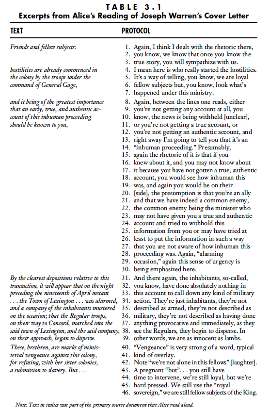

前三行，由一系列代词构成，传达了阅读历史的复杂性：这些人究竟是谁？开篇，历史学家以实际读者的身份出现（第1行），承认她已经对文本的某个特定方面进行了评论。但到了第2行，她迅速切换到模拟作者的角色，与沃伦共同构建文本（如第2行的“我们”和第3行的“我们”所示），以“你们”——大不列颠的居民，以及后来的乔治国王本人——来与他们共同的读者对话，而不是以“他们”的身份。第4-7行进一步突出了实际读者和模拟读者之间的交流。在第4行，模拟读者首先揭示了“敌对行动已经开始”这句话的潜台词。实际读者观察着模拟读者的思路，澄清道：“这是一种叙述方式”，但随后又切换回模拟读者的语气——“我们是忠诚的同胞”（第5-6行）。在下一节（第8-30行），我们发现实际读者明确表示，她正在构建一个在文本表述中找不到的信息。这里，“你”再次指代模拟读者，历史学家（以约瑟夫·沃伦的口吻）为他们提供贯穿全文的潜台词。在第31-39行，历史学家总结了她所读到的内容（“他们没有被描述为……”），但添加了一些解释性标记，例如“所谓的”（第31行）。在本节的最后一段评论（第39行），爱丽丝从对文本的评论转向对潜台词的总结，再次以模拟读者的口吻说道：“我们像羔羊一样天真无邪。”

The first three lines, a congeries of pronouns, convey the complexity of reading history: Who are all these people? The protocol begins with the historian as actual reader (line 1), acknowledging that she has already commented on a particular aspect of the text. But in line 2 she quickly assumes the role of mock writer, co-constructing the text with Warren (as indicated by the use of “we” in line 2 and “us” in line 3) to address their joint audience—not as “them” but as “you” the inhabitants of Great Britain and, later, King George himself. Lines 4–7 further highlight the flow of communication between actual and mock reader. In line 4, the mock reader begins by laying bare the subtext of the sentence “hostilities are already commenced.” Monitoring the mock reader, the actual reader offers a clarifying “It's a way of telling” but then flips back to the voice of the mock reader—“we are loyal fellow subjects” (lines 5–6). In the next section (lines 8–30), we find an explicit statement by the actual reader that she is constructing a message not found in the manifest text. Here again “you” refers to the mock audience, for whom the historian (taking on the voice of Joseph Warren) provides a running subtextual commentary. In lines 31–39, the historian summarizes what she has read (“they're not described as…”), but adds a few interpretive markers such as “so-called” (line 31). In the final comment of this section (line 39), Alice turns from a review of the text to a summary of the subtext, again taking the voice of the mock reader: “we are as innocent as lambs.”

在这段节选中，阅读模拟了社会交流中的互动。首先，我们听到沃伦的声音，他用略显生硬的文风阐述着隐藏在字里行间的真实信息。接下来是“你们”，指的是英国公民，甚至是乔治国王本人。然后是“我们”，指的是扮演历史学家角色的虚构作家，他与沃伦共同构建了文本。最后，是真正的读者——“我”，她如同舞台导演一般，指挥着这群虚构人物，指导他们的台词，审视他们的言行，并最终注意到自身理解与虚构读者所言之间的鸿沟。正是这个“我”，最终因自身想法与她所创造的人物之间的巨大差异而捧腹大笑。

In this excerpt, reading simulates the give and take of social exchange. First we hear Warren's voice, enunciating the real message behind his stilted prose. Next there is “you” the citizens of Great Britain or King George himself. Then there is “we” a reference to the historian as mock writer co- constructing the text with Warren. Finally, there is the “I” of the actual reader, who acts as stage director for this cast of mental characters, dictating their lines, monitoring what they say, and ultimately noting the breach between her own understanding and the claims made by the mock reader. And it is this “I” who ultimately breaks down in laughter at the disparity between her own thoughts and those of the characters she has created.

文字难以捕捉到这种朗读方式所蕴含的滑稽元素。这是一种游戏式的朗读，它充满玩笑和嘲讽，时而采用戏谑的英雄腔调，时而采用戏谑的悲剧腔调，最终，当真正的朗读者和扮演朗读者的角色变得如此疏离，以至于彼此几乎无法辨认时，朗读便沦为一场笑声。事实上，历史学家在第42行的笑声就暗示了这种隔阂。扮演朗读者的角色变成了被嘲笑的对象，她以一种矫揉造作的模仿方式念着台词。

Written words fail to capture the elements of burlesque that characterize this reading. This is a ludic reading that jokes and jibes, that adopts mock-heroic and mock-tragic voices, and that ultimately degenerates into laughter when the actual and mock reader become so estranged that they barely recognize each other. Indeed, the historian's laughter in line 42 hints at this breach. The mock reader turns into an object of ridicule enunciating her lines in melodramatic parody.

在这里，阅读超越了作者与读者之间的对话，而变成了一系列对话——真实读者和模拟读者之间的交流。在模拟作者和模拟读者之间，在模拟读者和模拟读者之间，以及在这些角色中的任何一个与实际读者的“我”之间，都存在着互动。成熟的历史读者不会像传统读者那样，由单一的“执行者”自上而下地指挥流程，而是会在自己的脑海中构建一个“执行委员会”，成员们会就争议点大声疾呼、争论不休。<sup>22</sup>文本与其说是被“处理”，不如说是被“复活”。而将读者比作信息处理器或计算设备——这种比喻在当前的阅读讨论中常常占据主导地位——似乎不如另一种比喻更贴切：读者如同死灵法师。

Here reading moves beyond an author-reader dialogue to embrace a set of conversations—exchanges between actual and mock reader, between mock writer and mock audience, between mock reader and mock audience, and between any one of these characters and the “I” of the actual reader. Instead of a single “executive” directing a top-down process, mature readers of history may create inside their own heads an “executive board” where members clamor, shout, and wrangle over controversial points.<sup>22</sup> Texts are not “processed” as much as they are resurrected, and the image of reader as information processor or computing device, which often dominates current discussions of reading, seems less apt than another metaphor: the reader as necromancer.

为了说明读者如何根据文本残存部分重构作者，<sup>23</sup>让我描述一下我使用的另一个资料来源，即1775年耶鲁学院院长埃兹拉·斯泰尔斯的一篇日记。斯泰尔斯不仅记录了他作为学院管理者的生活，还详细描述了他所处时代的事件。他关于列克星顿的日记开头写道：“皮特凯恩少校（英国指挥官）为人正直，却身处险境，他至死都坚持认为殖民者先开火……他明确表示自己没有看到是谁先开的火；但他仍然相信是农民先开的。” <sup>24</sup>这时，日本历史专家玛丽评论道：

To illustrate how readers reconstructed authors from their textual remainders,<sup>23</sup> let me describe another one of the sources I used, a diary entry by Ezra Stiles, president of Yale College in 1775. Stiles not only wrote about his life as a college administrator but described in great detail the unfolding events of his day. His entry about Lexington began: “Major Pitcairn [the British commander] who was a good man in a bad cause, insisted upon it to the day of his death, that the colonists fired first…. He expressly says he did not see who fired first; and yet believed the peasants began.”<sup>24</sup> At this point, Mary, a specialist in Japanese history, commented:

尽管埃兹拉·斯泰尔斯标榜自己是民主人士，但某种程度上，他给人的感觉却非常阶级化。我的意思是，你可以看出皮特凯恩和斯泰尔斯出身同一阶层。或许并非如此，但他们都因各自的成长经历而为人正直，所以他算是“身处险境的好人”。我从斯泰尔斯使用的一些词语中也能感受到这一点——我不知道斯泰尔斯的背景，但我推测他并非贵族出身，但他受过良好的教育，如果他在十八世纪末担任耶鲁大学校长，那他很可能是一位神职人员；在那个时期，耶鲁大学的大多数校长可能都是神职人员。所以，即使他并非贵族，也受过良好的教育。但皮特凯恩很可能出身贵族，因为我相信，直到二战之前，大多数英国指挥官或军官都出身于某种贵族阶层。<sup>25</sup>

Ezra Stiles for all his supposed democracy comes across as very kind of classist in a way. I mean, you can tell that Pitcairn is from the same class as Stiles. Maybe not, but they both are men of integrity because of their upbringing, so he's “a good man in a bad cause.” And I get that sense from some of the terms that Stiles uses—I don't know what Stiles' background is but I assume he's not aristocratic but he’s educated, probably a man of the cloth if he was president of Yale in the late eighteenth century; at that point probably most of them were clergy. So he was educated even if not a noble. But Pitcairn probably was, because until World War II, I believe, most British commanders were, or its officers were, from nobility of some sort.<sup>25</sup>

在玛丽的解读中，埃兹拉·斯泰尔斯是一个“阶级主义者”（基于他傲慢的语气和使用“农民”一词），一个神职人员（基于文本线索和她的背景知识），受过良好教育但可能并非贵族成员，也是一个伪君子（基于斯泰尔斯的爱国情怀与他称同胞为“农民”之间的矛盾）。玛丽在其他地方谈到了斯泰尔斯的写作动机，但在这里，她的评论并非针对作者的意图，而是针对斯泰尔斯本人。同样，当汤姆——一位研究葡萄牙在新大陆殖民的专家——阅读斯泰尔斯的条目时，他压低了声音，嘴里叼着铅笔，仿佛那是一根烟斗。

In Mary's reading, Ezra Stiles is a “classist” (based on his haughty tone and his use of “peasants”), a cleric (based on textual cues and her background knowledge), well-educated but probably not a member of the aristocracy, and a hypocrite (based on the discrepancy between Stiles' patriotism and his reference to his compatriots as “peasants”). Elsewhere Mary talks about Stiles' motives for writing, but here her comments are not about the author’ intentions but about the man himself. Similarly, when Tom, an expert on Portuguese colonization in the New World, read Stiles' entry, he deepened his voice and dangled his pencil from his mouth as if it were a pipe:

我心想（声音低沉）：一个和蔼的耶鲁人想说点什么，你知道，（声音再次低沉）“皮特凯恩少校是个非常好的人。”我当时就觉得，这是理性的声音，常春藤盟校高深的圣公会正统观念…… “农民”——这词真妙……我的意思是，我们现在读的是美国革命。毕竟，它应该是一群自耕农奋力捍卫自身权利的故事，而这里是耶鲁大学的校长……他的祖先来自英国，赚够了钱送他去耶鲁，让他当上了耶鲁的校长……这是精英阶层在谈论农民。<sup>26</sup>

I'm thinking [voice deepens]: a nice Yale man trying to say something, you know, [voice deepens again] “Major Pitcairn was a veeeeery good man.” I'm just thinking that this is the voice of reason, Ivy League high Episcopalian orthodoxy…. “Peasants”—it's just a great word…I mean here we are reading about the American Revolution. After all, it's supposed to be a bunch of yeoman farmers vigorously defending their rights and here is the president of Yale…whose ancestors came from England and who made enough money to send him to Yale and get him to be president of Yale…. This is the elite talking about the peasant.<sup>26</sup>

在这两种解读中，文本并非毫无生气的罗列事实，而是开启人性之门的钥匙，揭示人有其喜好、偏见、弱点、姿态和信念。文字具有质感和形态，正是这种近乎触觉般的特质，让读者得以塑造出使用它们的作者的形象。这些形象随后会根据阅读语境和读者的倾向，被质疑、嘲讽、赞扬或否定。在这样的解读中，作者和文本一样，都被解码。

In both of these readings, texts are not lifeless strings of facts, but the keys to unlocking the character of human beings, people with likes and dislikes, biases and foibles, airs and convictions. Words have texture and shape, and it is their almost tactile quality that lets readers sculpt images of the writers who use them. These images are then interrogated, mocked, congratulated, or dismissed, depending on the context of the reading and the disposition of the reader. In such readings, authors, as well as texts, are decoded.

但反过来也成立：正如读者解读作者一样，文本也解读读者。因为文本呈现的是各种可能性，而非一成不变的意义集合，所以我收集到的这些出声思考记录或许更多地反映了文本的读者，而非文本的作者。 <sup>27</sup>在上述记录中，激怒历史学家的词语是“农民”，这个词让人联想到农民与精英之间的阶级斗争。无论埃兹拉·斯泰尔斯在1775年写作的本意是什么，在这两位20世纪后半叶分别就读于哈佛和斯坦福的历史学家看来，斯泰尔斯笔下的农民变成了马克思和恩格斯笔下的农民，他们与城市无产阶级联合起来推翻了资产阶级。然而，当我们查阅《*牛津英语词典》*中“peasant”（农民）一词的历史用法时，会发现它其实可以简单地指“在土地上劳作的人，无论是小农还是工人……主要依靠自己和家人劳动所得维持生计的人”。那么，埃兹拉·斯泰尔斯究竟是什么意思呢？

But the converse is also true: Just as readers decode authors, so texts decode readers. Because texts present plays of potentialities, not sets of meanings forever fixed, the think-aloud protocols I obtained may tell us more about those who read these texts than about those who wrote them.<sup>27</sup> In the above protocol, the word that riles the historians is “peasants” a word that calls up images of class struggle between peasants and elites. Whatever Ezra Stiles writing in 1775 may have meant, in the minds of these two historians, educated at Harvard and Stanford in the latter half of the twentieth century, Stiles' peasants become the peasants of Marx and Engels, who join with the urban proletariat to overthrow the bourgeoisie. Yet, when we look at the historical uses of “peasant” in the *Oxford English Dictionary*, we find that the word can simply mean “one who works on the land, either as small farmer or as laborer…one who relies for his subsistence mainly on the produce of his own labor and that of his household.” So what did Ezra Stiles mean?

毫无疑问，将十九世纪后半叶成书的*《资本论》*中“农民”一词的含义与埃兹拉·斯泰尔斯1775年的条目联系起来是有问题的。事实上，有人可能会认为这两位历史学家都理解错了：斯泰尔斯并非在区分富人和穷人、特权阶层和受压迫者、农民和精英，而只是在指出城市和乡村之间的差异，指出那些像他一样通过管理学院谋生的人和那些靠辛勤劳动谋生的人之间的差异。

It is no doubt problematic to attach the connotations of “peasant” found in *Das Kapital*, written in the latter half of the nineteenth century, to Ezra Stiles' entry of 1775. In fact, one could argue that these two historians have got it wrong: Stiles was not making a distinction between rich and poor, privileged and downtrodden, peasant and elite, but simply noting a difference between urban and rural, between those who, like himself, earned their bread by administering a college and those who earned it by the sweat of their brow.

如果问题真有那么简单就好了！《*牛津英语词典》*列举了斯泰尔斯生前及生前“peasant”（农民）一词的其他用法。早在1550年，这个词就带有了贬义，暗示着无知、愚蠢和粗鲁，常与“buzzardly”（秃鹫般的）等形容词连用，并与“coward”（懦夫）和“rascal”（恶棍）等词语并列。因此，问题依然存在：斯泰尔斯是否仅仅把这些人看作农民？或者，他是否认为他们是愚昧无知之徒，与正直的皮特凯恩少校——毕竟，他是一位“身处险境的好人”——几乎没有任何共同之处？

If only the problem were that simple! The *Oxford English Dictionary* enumerates other ways in which “peasant” was used before and during Stiles' lifetime. As early as 1550, the word had taken on pejorative connotations, implying ignorance, stupidity, and boorishness, modified by adjectives like “buzzardly” and placed in apposition to “coward” and “rascal.” So the question remains: Did Stiles think of these men as farmers, nothing more? Or did he think of them as ignoramuses, men who shared little in common with the honorable Major Pitcairn, who was, after all, a “good man in a bad cause”?

为了解决这一困境，一些历史学家建议我们摒弃当下的观念，沉浸于过去的语言之中，感受过去人物的感受，理解他们（而非我们）赋予词语的内涵。唯有放弃我们自身的局限，我们才能真正从历史的角度去认识它。历史学家有时为此不遗余力；罗伯特·E·李的传记作者道格拉斯·弗里曼就试图通过限制自己只了解李的认知范围，并在这些认知和认知的界限内撰写传记，从而重构李的思想。 <sup>28</sup>

To solve this dilemma, some historians would recommend that we shed our presentist conceptions, immerse ourselves in the language of the past, feel what past actors felt, and understand the connotations that they, not we, attach to words. Only by renouncing our own condition can we come to know the past on its own terms. Historians have sometimes gone to great lengths to do this; Robert E. Lee's biographer Douglas Freeman tried to reconstruct what Lee thought by limiting himself to what Lee knew, and then writing a biography within these boundaries of knowledge and ignorance.<sup>28</sup>

毫无疑问，当我们了解到“农民”一词有多种含义时，我们的理解会更加丰富，但这并不能解答斯泰尔斯究竟意欲何为的问题；它只是拓宽了这个问题。正因如此，读者心中构建的作者形象始终只是形象而已——正如卡尔·贝克尔所言，这个形象总是受到“我们当下的目的、欲望、先入之见和偏见的影响，所有这些都参与到认知过程中……实际事件会为想象的画面贡献一些东西；但持有这种想象画面的头脑也总是会做出一些贡献。” <sup>29</sup>

No doubt our understanding is enriched when we learn that “peasant” has multiple meanings, but this knowledge does not put to rest the question of what Stiles meant; it simply widens it. This is why the image of the author constructed in reader's minds remains just that—an image—which, in Carl Becker's words, is always shaped by “our present purposes, desires, prepossessions, and prejudices, all of which enter into the process of knowing…. The actual event contributes something to the imagined picture; but the mind that holds the imagined picture always contributes something too.”<sup>29</sup>

文本认识论

AN EPISTEMOLOGY OF TEXT

当我们比较历史学家和学生如何解读这些文献时，几乎在任何评判标准上都会发现显著差异。单就这一点而言，这并不令人惊讶；毕竟，历史学家掌握的历史知识远比学生丰富。但仔细分析后，这种解释却意义不大。当我们说历史学家“做得更好”是因为他们是历史学家时，我们只是用归因代替了解释。那么，“掌握更多历史知识”究竟意味着什么？当一位研究二十世纪劳工史的历史学家或一位专攻十三世纪伊斯兰文献的中世纪史学家坐下来阅读美国革命史时，他们的理解又会如何呢？

When we compare how historians and students read these documents, we see dramatic differences on practically any criterion we select. By itself, this news should shock no one; after all, historians know much more history. But on closer examination, this explanation tells us precious little. We simply substitute ascription for explanation when we say that historians “did better” because they are historians. What does it mean to “know more history”? What goes on when a historian of labor in the twentieth century or a medievalist who specializes in thirteenth- century Islamic texts sits down to read about the American Revolution?

人们或许会认为，这两组学生在历史知识方面存在巨大差异，尤其如果我们把这种“知识”定义为历史考试中经常出现的美国革命相关人名、日期和概念。事实上，两名高中生回答的辨识题（例如，“提康德罗加堡是什么？” “乔治·格伦维尔是谁？” “汤森法案是什么？”）比一位历史学家还要多，而另一位历史学家也只比大多数学生多答对一道题。但了解历史远比回答这类问题复杂得多。学生们很少能理解阅读材料中的弦外之音，他们对观点的理解仅限于判断一份文件属于哪一方，他们很少将不同的叙述进行比较，而是一味地寻找正确答案，并在遇到矛盾时感到慌乱——所有这些都表明，仅仅记住人名和日期是不够的。

One might suppose that dramatic differences in topical knowledge separated these two groups, particularly if we define such “knowledge” as the names, dates, and concepts of the American Revolution that often appear in history tests. In point of fact, two high school students answered more of the identification questions (e.g., “What was Fort Ticonderoga?” “Who was George Grenville?” “What were the Townshend Acts?”) than one of the historians, and another historian got only one more answer than most students. But knowing history is more complicated than answering such questions. That students so rarely saw subtexts in what they read, that their understanding of point of view was limited to which “side” a document was on, that they rarely compared one account with another, instead searching for the right answer and becoming flustered in the face of contradictions—all hint at a need for something more than knowing names and dates.

我认为，各组学生研究方法上的差异可以追溯到他们对历史探究的根本信念，或者说，可以称之为文本认识论。对学生而言，阅读历史并非探究作者意图或将文本置于社会语境中的过程，而是收集信息，文本仅仅是信息的载体。如此聪颖的学生怎会对那些令历史学家一眼就能发现的潜台词视而不见呢？答案或许在于二世纪教父特土良的一句格言。特土良的圣经诠释首要原则是“我信，为知”（*credo ut intelligam* ）。学生必须首先相信潜台词的存在，才能看到它们。如果缺乏这种信念，学生们要么会忽略文本，要么根本不知道如何去寻找那些旨在塑造他们认知或引导他们以特定方式看待事件的特征。学生们或许“处理”了文本，但却未能真正与之产生共鸣。

The differences in each group's approach can be traced, I think, to sweeping beliefs about historical inquiry, or what might be called an epistemology of text. For students, reading history was not a process of puzzling about author's intentions or situating texts in a social world but of gathering information, with texts serving as bearers of information. How could such bright students be oblivious to the subtexts that jumped out at historians? The answer may lie in an aphorism of Tertullian, the second-century church father whose first principle of biblical exegesis was *credo ut intelligam* (“I believe in order to understand”). Before students can see subtexts, they must first believe they exist. In the absence of such beliefs, students simply overlooked or did not know how to seek out features designed to shape their perceptions or make them view events in a particular way. Students may have “processed texts” but they failed to engage with them.

这种信念或许有助于解释“来源启发式”（即在阅读正文之前先阅读文献来源）使用上的差异。历史学家几乎总是使用这种启发式方法（98%），而学生使用率不到三分之一（31%）。对大多数学生而言，文本的出处并不重要；它仅仅是一系列文本命题中的最后一条信息。对历史学家来说，文献的出处并非文献的终点，而是起点；他们视来源为人，而非物；视来源为社会交流，而非命题集合。从这个意义上讲，来源启发式仅仅体现了一种信念体系，在这种体系中，文本由其作者定义。

Such beliefs may help to explain differences in the use of the “sourcing heuristic” the practice of reading the source of the document before reading the actual text. Historians used this heuristic nearly all of the time (98 percent), while students used it less than a third (31 percent). For most students, the text's attribution carried no special weight; it was merely the final bit of information in a string of textual propositions. To historians, a document's attribution was not the end of the document but its beginning; sources were viewed as people, not objects, as social exchanges, not sets of propositions. In this sense, the sourcing heuristic was simply the manifestation of a belief system in which texts were defined by their authors.

当文本被视为人类的创造物时，其中所表达的内容就变成了这与作者是谁密不可分。但对一些学生来说，作者和他们的叙述之间只有松散的联系。所以，当一位学生最初读到霍华德·法斯特的节选时，他就知道有些不对劲：“你不能完全相信他们说的。细节肯定不对。”但当这位学生读到最后一份文献时，他对法斯特的疑虑就烟消云散了，因为这篇虚构叙述中的一些元素清晰地融入了他的理解之中。另一方面，一位美国史专家在看到殖民者列队“整齐列队”的说法时停顿了一下。他想起之前有一份文献描述过战斗阵型，于是翻回法斯特的节选，然后突然大笑起来：“哦，那是法斯特说的！算了！我不能相信法斯特；我做不到。但这很有趣；它一直萦绕在我的脑海里。”这里我们看到了相反的情况：一个细节被记住了，但历史学家却记不起它的出处。这位历史学家将细节与作者重新联系起来后，便将其否定了，因为他知道没有独立存在的细节——只有与证人相关的细节。

When texts are viewed as human creations, what is said becomes inseparable from who says it. But for some students, authors and their accounts were only loosely connected. So, when one student initially read the excerpt from Howard Fast, he knew something was wrong: “You can't really believe exactly what they're saying. It's going to be, the details are going to be off.” But by the time this student reached the last document, his reservations about Fast had fallen by the wayside, as elements from this fictitious account were clearly present in his understanding. An Americanist, on the other hand, paused when he encountered the claim that the colonists were drawn up in “regular order.” Remembering that an earlier document described the battle formation, he flipped back to the Fast excerpt and then burst into laughter: “Oh, that's from Fast! Forget it! I can't hold on to Fast; I can't do that. But it's funny; it stuck in my mind.” Here we see the opposite case: a detail is remembered, but the historian cannot remember its source. Reunited with its author, the detail is rejected, for this historian knows that there are no free-floating details—only details tied to witnesses.

法庭的比喻或许有助于我们理解这些差异。历史学家研读这些文献时，如同扮演检察官一般；他们不仅聆听证词，更积极地将文献并列比较，找出矛盾之处，质疑史料来源，并探究其有意或无意的动机，从而推动事件发展。而学生则如同陪审员，耐心聆听证词，并对所听到的内容进行自我反思，但却无法直接质问证人或对其进行交叉询问。对学生而言，权威在于文本本身；而对历史学家而言，权威则在于他们围绕文本提出的问题。<sup>30</sup>

The metaphor of the courtroom may help us understand these differences. Historians worked through these documents as if they were prosecuting attorneys; they did not merely listen to testimony but actively drew it out by putting documents side by side, locating discrepancies, and questioning sources and delving into their conscious and unconscious motives. Students, on the other hand, were like jurors, patiently listening to testimony and questioning themselves about what they heard, but unable to question witnesses directly or subject them to cross-examination. For students, the locus of authority was in the text; for historians, it was in the questions they formulated about the text.<sup>30</sup>

一群才华横溢的高中毕业生为何对历史文本的阅读能力如此匮乏？他们明明掌握了如此丰富的历史知识，为何却对如何阅读历史文本如此缺乏理解？这些问题并不简单，其答案也超出了本章的讨论范围。但至少，我们可以从学生在历史课上阅读的文本类型入手。教科书主导着历史课堂，正如彼得·施拉格所指出的，历史教科书的写作方式往往“仿佛作者根本不存在，仿佛他们只是某种神圣智慧的工具，记录着官方的真理”。 <sup>31</sup>艾文·克里斯莫尔证实了施拉格的观点。她对历史教科书、学术历史文本和通俗历史文本进行了话语分析，发现“元话语”（即判断、强调和不确定性的表达）在历史写作中被频繁使用，但在传统教科书中，这种现象极为罕见。克里斯莫尔发现，大多数教科书都避免使用“可能”、“或许”、“似乎”或“也许”之类的限定词，几乎没有表明解释与书页上的文字有任何关联。这种写作方式可能会导致学生无法超越字面理解：“当限定词缺失时，批判性阅读（学习评估和判断真假条件）会发生什么变化？当偏见不明显时（就像大多数教科书那样），年轻的读者是否会被蒙蔽？” <sup>32</sup>

What accounts for the fact that a group of bright high school seniors displayed such a rudimentary sense of how to read a historical text? How could they know so much history yet have so little sense of how to read it? These are not simple questions, and their answers lie beyond the scope of this chapter. But, at the very least, we can point to the types of texts students have read in their history classes. Textbooks dominate history classrooms, and, as Peter Schrag has noted, history textbooks are often written “as if their authors did not exist at all, as if they were simply the instruments of a heavenly intelligence transcribing official truths.”<sup>31</sup> Avon Crismore has documented Schrag's claim. In a discourse analysis of history textbooks and academic and popular historical texts, she found that “metadiscourse” or indications of judgment, emphasis, and uncertainty, was used frequently in historical writing but appeared rarely in conventional textbooks. Crismore found that most textbooks abjured hedges like “may” or “might” “appears” or “perhaps” providing little indication that interpretation had anything to do with the words on the page. Such writing may contribute to student's inability to move beyond the literal: “What happens to critical reading (learning to evaluate and make judgments about truth conditions) when hedges…are absent? When bias is not overt (as it is not in most textbooks) are young readers being deceived?”<sup>32</sup>

或许克里斯莫尔的论点有些夸大其词。或许她的发现和我的研究结果都无需过度担忧；或许学生们对文本的幼稚看法会在他们进入大学后自然而然地被抛弃。然而，证据却表明并非如此。例如，詹姆斯·洛伦斯在观察大学新生时，发现他们持有与此处描述类似的信念。他写道，许多学生“期望一份文件能够揭示他们认为的‘真理’……他们坚持不懈地寻求对眼前资料可靠性的最终结论。” <sup>33</sup>同样，罗伯特·伯克霍弗也曾撰文指出，他在本科生中经常遇到“历史原教旨主义”，这些学生“将指定的阅读材料和教科书，甚至他们的老师，都视为神圣启示。” <sup>34</sup>在卡内基梅隆大学，研究人员克里斯蒂娜·哈斯和琳达·弗劳尔让本科生在阅读一系列论战性文本时进行思考。她们发现，大学生能够轻松地解读文本的基本含义，并概括其要点。然而，

Perhaps Crismore overstates her case. Perhaps her findings and mine are little cause for alarm; perhaps student's naive beliefs about text will simply be sloughed off when they get to college. The evidence, however, suggests otherwise. For example, James Lorence, in observations of college freshmen, found beliefs similar to those described here. Many students, he wrote, “expect a document to reveal something which they may regard as ‘the truth.’…They persist in seeking a definitive conclusion on the reliability of the source before them.”<sup>33</sup> Similarly, Robert Berkhofer has written about the “historical fundamentalism” he encounters frequently among undergraduates, who “treat their assigned readings and textbooks, if not their teachers, as divinely inspired.”<sup>34</sup> At Carnegie Mellon University, researchers Christina Haas and Linda Flower had undergraduates think aloud as they read a series of polemical texts. They found that college students could easily decipher the basic meaning of texts and formulate the gist of what they read. However,

这些学生常常让我们感到沮丧，因为他们只会复述而非分析，只会概括而非批判文本……我们可以假设，学生在批判性阅读晦涩文本时遇到的问题，与其说是他们构建的表征有问题，不如说是他们未能构建的表征有问题。他们对文本的表征与内容紧密相关：他们阅读是为了获取信息。我们的学生可能认为，只要他们理解了所有单词，并且能够复述文本的主旨内容，就意味着他们成功地阅读了文本。<sup>35</sup>

these same students often frustrate us, as they paraphrase rather than analyze, summarize rather than criticize texts…. We might hypothesize that the problem students have with critical reading of difficult texts is less the representations they are constructing than those they fail to construct. Their representations of text are closely tied to content: they read for information. Our students may believe that if they understand all the words and can paraphrase the propositional content of the text they have successfully read it.<sup>35</sup>

事实上，持有这些观点的可能并非只有学生；有时他们也会与老师分享这些观点。在对高中社会研究教师知识增长情况进行的一项研究中，我和苏珊娜·威尔逊采访了一位老师，她告诉我们，诠释在历史理解中几乎不起作用：“历史就是发生了什么的基本事实。发生*了*什么事。你不会问它是如何发生的。你只会问，‘发生了什么事？’” <sup>36</sup> 总之，我们可以找到历史上某些时期——例如中世纪——青少年和成年人都接受了前批判性的历史编纂观念。 <sup>37</sup>这种观点认为……学生进入成年后自然而然会放弃某些信念，但这既没有数据也没有历史依据。

Indeed, students may not be the only ones who embrace these beliefs; sometimes they share them with their teachers. In a study of knowledge growth among high school social studies teachers, Suzanne Wilson and I interviewed one teacher who told us that interpretation had little role to play in historical understanding: “History is the basic facts of what happened. What *did* happen. You don't ask how it happened. You just ask, ‘What are the events?’”<sup>36</sup> In sum, we can locate entire epochs of history—the Middle Ages, for one—when precritical notions of historiography were embraced by adolescent and adult alike.<sup>37</sup> The notion that such beliefs are naturally abandoned as students enter adulthood has neither data nor history on its side.

从阅读方式到认知方式

FROM WAYS OF READING TO WAYS OF KNOWING

我们急于构建包罗万象的阅读模式，却常常忽略了文本中那些赋予其形态和意义的特质。当历史文本从学科领域进入学校课程时，我们强迫它们放弃自身的独特性。 <sup>38</sup>历史文本变成了“学校教材”，很快就与其他学科的教材——例如生物、语言艺术等——更加相似，而非与其原本所属学科的文本相似。 <sup>39</sup> 例如，历史话语的显著特征——通过脚注不断引用文献记录——恰恰是历史文本变成历史教科书时被忽略的方面。当我们压制了历史叙事是如何被构建的证据时，难怪许多学生会将历史视为一个封闭的故事。

In our zeal to arrive at overarching models of reading, we often ignore qualities of the text that give it shape and meaning. When historical texts make the journey from the discipline to the school curriculum, we force them to check their distinctiveness at the door.<sup>38</sup> The historical text becomes the “school text” and soon bears a greater resemblance to other school texts—in biology, language arts, and other subjects—than to its rightful disciplinary referent.<sup>39</sup> So, for example, the defining feature of historical discourse—its constant reference to the documentary record through footnotes—is the very aspect that drops out when historical texts become history textbooks. No wonder many students come to see history as a closed story when we suppress the evidence of how that story was assembled.

更广泛地说，最初催生“历史”、“物理”、“文学”和“数学”这些标签的认识论区分，在学校课程中逐渐被掩盖。尽管我们将学校课程划分成不同的时段，希望借此培养学生运用多种认知方式的能力，但我们最终往往只教授一种认知方式。尽管学生在不同的课程中学习不同的词汇——生物课上的“有丝分裂”、英语课上的“主题”、历史课上的“陈述行为”以及数学课上的“功能”——但这些词汇上的区分却有着共同的深层结构：知识脱离经验，是确定无疑的，没有任何限定和保留，其来源是教科书和教师，并且可以通过考试来衡量，而考试的每个问题都有一个正确答案。<sup>40</sup>

More broadly, the epistemological distinctions that first gave rise to the labels “history” “physics” “literature” and “mathematics” become eclipsed in the school curriculum. Although we carve the school day into separate periods, hoping thereby to teach students to be multilingual in various ways of knowing, we too often end up teaching a single tongue. Although students learn different vocabularies in different classes—“mitosis” in biology, “theme” in English, “Declaratory Acts” in history, and “function” in mathematics—these lexical distinctions share a common deep structure: Knowledge is detached from experience, it is certain and comes shorn of hedge and qualification, its source is textbooks and teachers, and it can be measured with tests in which every question has a right answer.<sup>40</sup>

学科同质化的进程甚至在教师培训教材中也显而易见。例如，一本流行的阅读教材告诉未来的教师，在阅读历史文献时，“学生需要学习阅读策略，以识别文献的用途并学习如何阅读它们。” <sup>41</sup>然而，这本书并没有详细阐述这些策略或描述历史学家的工作，而是引导读者阅读“科学阅读”章节。但是，将阅读DNA结构与阅读美国革命结构等同起来的“学科阅读”方法，掩盖了赋予文本意义的潜在假设。即使是认知心理学文献中对领域特定知识的日益重视，可能无意中加剧了这种混淆，因为它将知识等同于信息。 <sup>42</sup>在这种观点下，知识本身变得泛化，并根据语义网络中呈现的事实和关系的数量，或产生式系统中形式化的“如果/那么”条件进行分类。但正如路易斯·O·明克提醒我们的那样，领域超越了事实和概念的汇编或产生式的执行。它们构成了“独特且不可简化的理解世界的方式”， <sup>43</sup>是组织经验和探究我们自身本质的宏大途径。因此，西部山脉这一主题对地质学家、历史学家和安塞尔·亚当斯来说，意义各不相同。阅读不仅仅是学习新信息的一种方式，更成为参与新型思维方式的一种途径。

The process of disciplinary homogenization is evident even in textbooks used in teacher training. So, for example, one popular reading textbook tells prospective teachers that, when reading historical documents, “students need to be guided to reading strategies for recognizing the uses of documents and for learning how to read them.”<sup>41</sup> But rather than delineating such strategies or describing what historians do, this book directs readers to the chapter on “Reading in Science.” However, approaches to “reading in the content areas” that equate reading about the structure of DNA with reading about the structure of the American Revolution obscure the underlying assumptions that give texts meaning. Even the increased emphasis on domain-specific knowledge in the cognitive psychological literature may have unwittingly contributed to this confusion by equating knowledge with information.<sup>42</sup> In this view knowledge itself becomes generic, classified according to the number of facts and relationships represented in a semantic net or “if/then” conditions formalized in a production system. But domains, as Louis O. Mink reminded us, go beyond compilations of facts and concepts or executions of productions. They constitute “unique and irreducible modes of comprehending the world,”<sup>43</sup> sweeping ways of organizing experience and conducting inquiry into who we are. Thus, the topic of Western mountain ranges means one thing to a geologist, another to a historian, and still another to Ansel Adams. Reading is not merely a way to learn new information but becomes a way to engage in new kinds of thinking.

本文呈现的阅读理解图景与教育文献中常见的图景截然不同。为什么呢？首先，每种图景的出发点都不同。我们对“优秀读者”的大多数印象都来自学龄儿童，他们是尚未被学科知识体系所塑造的懵懂读者。阅读理解的本质变成了在都市成就测验、尼尔森-丹尼测验、盖茨-麦金尼测验或众多其他标准化阅读测试中取得好成绩所需的一切。然而，这些测试虽然高度相似，却远不能反映我们在现实世界中遇到的那些复杂多变的文本。我们对“阅读理解”的定义变成了阅读理解测试所衡量的内容：能够读懂由缺席作者撰写的、独立成篇且脱离其学科语境的特制文章；能够正确回答那些预设存在明确正确答案的选择题；熟悉那些掩盖文本作者信仰不可避免地渗透到文字中的格式；擅长解读字面意义而非隐含意义；以及能够处理独立段落而非在多个文本中建立互文联系。简而言之，阅读理解由文本、读者以及我们用来研究它的方法所定义。<sup>44</sup>

The image of reading comprehension presented here differs dramatically from images that often emerge from the education literature. Why? First, each image has a different starting point. Most of our portraits of the “good reader” come from schoolchildren, naive readers not yet socialized into disciplinary ways of knowing. The essence of reading comprehension becomes whatever it takes to do well on the Metropolitan Achievement Test, the Nelsen-Denny, the Gates-MacGinite, or any of a host of standardized reading measures. But these tests, all of which bear a strong family resemblance, are poor approximations of the slippery and indeterminate texts we encounter in the real world. Our definition of “reading comprehension” becomes what the reading comprehension tests measure: the ability to do well on specially designed passages written by absentee authors, each passage self-contained and decontextualized from the discipline that gives it meaning; the ability to respond correctly to multiple-choice questions that presume an unambiguous right answer; familiarity with formats that disguise the fact that texts are written by people whose beliefs ineluctably creep into their prose; skill at decoding literal as opposed to latent meaning; and the ability to process independent passages rather than create intertextual connections across multiple texts. In short, reading comprehension is defined by the texts, by the readers, and by the measures we use to study it.<sup>44</sup>

当我们放弃阅读理解文章中受控的词汇，不再关注小学生，而是关注以阅读为生的人时，我们对阅读理解的理解就会呈现出不同的面貌。<sup>45</sup>这并不是说这两种理解方式孰对孰错；显然，它们各自告诉我们不同的信息。但当两者之间存在不匹配时，我们确实会遇到问题。我们提出的问题以及我们选择的阅读方式都至关重要。如果我们问“理解历史文本意味着什么？”，并且仅仅依赖于通用阅读理解测试的结果，我们或许能学到很多关于阅读的知识，但却对如何阅读历史知之甚少。

When we abandon the controlled vocabulary of the comprehension passage and look not at schoolchildren but at people who read for a living, we end up with a different image of comprehension.<sup>45</sup> It is not that one of these images is right and the other wrong; clearly, each tells us different things. But we do have a problem when there is a mismatch between the questions we ask and the image of reading we select. If we ask, “What does it mean to comprehend a historical text?” and rely exclusively on what generic reading comprehension tests tell us, we may learn a great deal about reading, but little about reading history.

如果情况属实，我们应该用什么标准来评判学生对历史文本的理解？尽管对中小学生历史和社会研究文章的理解能力进行了广泛的测试，但即使在如今这个痴迷于标准的时代，标准问题也鲜少被提及。罗伯特·林恩对此深感遗憾，他写道：“与探究标准究竟从何而来相比，人们投入了过多的精力来解决那些假定存在某种标准的问题。” <sup>46</sup>那么，我们的标准应该从何而来？在我看来，只有一个站得住脚的答案：我们必须从学科本身出发。

If this is true, what standard should we use to judge the comprehension of historical texts? Despite widespread testing of schoolchildren's comprehension of history and social studies passages, the question of standards is seldom addressed, even in an age obsessed with standards. Robert Linn lamented this situation when he wrote that “there has been a disproportionate amount of effort devoted to the solution of problems that assume the existence of a standard in comparison to answering questions about where the standard comes from in the first place.”<sup>46</sup> And where should our standard come from? To me, there is only one defensible answer. We must look to the discipline.

这一系列活动引发了关于诸多议题的深刻思考——小学阶段空洞乏味的“拓展视野”课程、教科书的质量、关于学生学习能力的说法是否站得住脚，以及标准化考试对学生学习的影响。这些批评标志着任何改革努力都迈出了宝贵的第一步。然而，我们最需要解答的问题——“教师需要做出哪些改变才能创建真正能促进学习的历史课堂？教师又该如何学习这些不同的教学方法？”——却鲜少在这些报告中得到解答。布拉德利委员会在教学法问题上大多保持沉默，但指出，正如生活一样，“多样性是学习的调味品”，并鼓励教师从各种教学方法和技巧中进行选择。然而，这些报告却鲜有提及。教学并非仅仅是选择合适的教学方法组合，正如历史诠释并非仅仅是选择合适的文献组合一样：正如苏珊娜·威尔逊所指出的，多样性或许令人愉悦，但未必具有教育意义。 <sup>50</sup>卓越的教学并非在于选择教学方法，而在于知识的转化。 <sup>51</sup>历史教师必须运用自身已有的知识，创造出能够激发学生新理解的内容呈现方式，而这些学生往往缺乏学习动力。做到这一点是一项极高的智力成就——其重要性不亚于对所要教授的内容有深刻的理解。

历史学家在教学法方面鲜有沉默，汤姆·霍尔特（Tom Holt）的《历史*思考》（Thinking Historically）*一书是个例外，该书由美国大学理事会出版。 <sup>52</sup> 霍尔特在书中深思熟虑地反思了他在芝加哥大学教授本科历史的经历，其中蕴含着许多宝贵的见解。他描述了一门本科历史课程，该课程以“反学习”为开端，旨在消除学生认为历史是一个固定不变的故事的印象。学生们不再像伍德罗·威尔逊（Woodrow Wilson）所说的那样，在考试中罗列“一个又一个该死的事实”，而是拿到原始文献，并扮演博物馆馆长的角色，为展览对这些文献进行注释。霍尔特有意将观点对立的史料并置，让学生构建叙事，从而与过去展开持续的对话，而不是“一套封闭的教条或一系列已经得到解答的问题”。 <sup>53</sup>

One exception to historian's reticence on pedagogy is Tom Holt's *Thinking Historically*, published by the College Board.<sup>52</sup> A thoughtful meditation on his teaching of undergraduates at the University of Chicago, Holt's work contains much of value. He describes an undergraduate history course that begins with “unlearning” an attempt to disabuse students of the impression that history is a fixed story. Instead of examinations in which students list, as Woodrow Wilson once put it, “one damn fact after another” they receive primary documents and pretend to be museum curators who must annotate these documents for an exhibit. Holt purposely juxtaposes sources with opposing viewpoints and has students construct narratives that constitute ongoing conversations with the past, not “a closed catechism or a set of questions already answered.”<sup>53</sup>

这些想法都很有意思。但它们共同指向了我们集体的无知，指向了我们对如何改变学生历史观念知之甚少这一事实。<sup>54</sup> 然而，如果我们等到高中才教学生用不同的问题去理解一篇短篇小说，用另一套问题去理解历史书，那么我们的努力注定会失败；他们必须在第一次接触到关于过去的说法时就学会提出这些问题。事实上，当我们检验我们对儿童能力的假设时，我们发现，在合适的条件下，即使是三年级的学生也能理解历史的不确定性，从而对过去做出深刻的解读。<sup>55</sup>

These are all intriguing ideas. But together they point to our collective ignorance, to the fact that we know little about changing student's beliefs about history.<sup>54</sup> Our efforts to do so, however, will surely founder if we wait until high school to teach students to ask a short story one set of questions and their history book a different set; they must learn to ask such questions when they first encounter claims about the past. In fact, when we put our assumptions about children's capabilities to the test, we find that, under the right conditions, even third graders can grasp something of history's indeterminate nature and thereby arrive at sophisticated interpretations of the past.<sup>55</sup>

结论

CONCLUSION

20世纪30年代初，著名历史学家卡尔·贝克尔撰写了一篇题为《人人皆可作历史学家》的论文，他在文中声称，就像……一样。不管怎样，我们都是历史学家。<sup>56</sup>他的意思是，我们都被召唤去进行历史思考——被召唤去洞察我们所读文本中的人性动机；被召唤去从每天试图吞噬我们的暗示、半真半假和谎言的流沙中挖掘真相；被召唤去勇敢地面对这样一个事实：至少在理解社会世界方面，确定性仍然难以捉摸，超出了我们的掌控。如果贝克尔的观点是正确的，那么学校历史课程就具有培养学生进行复杂思考和推理的巨大潜力。然而，我们是否能够充分利用这种潜力，则是另一回事了。

In the early thirties, the eminent historian Carl Becker wrote a paper entitled “Everyman His Own Historian” in which he claimed that, like it or not, we are all historians.<sup>56</sup> What he meant was that we are all called on to engage in historical thinking—called on to see human motive in the texts we read; called on to mine truth from the quicksand of innuendo, half-truth, and falsehood that seeks to engulf us each day; called on to brave the fact that certainty, at least in understanding the social world, remains elusive and beyond our grasp. If Becker was right, then school history possesses great potential for teaching students to think and reason in sophisticated ways. Whether we exploit this potential, however, is another story.

这里所描述的文本观并非仅限于历史领域。<sup>57</sup>语言并非用来作用于无生命物体的园艺工具，而是影响人心、改变观点、激发或平息激情的媒介。理解这一点对于阅读报纸、收听广播、评估竞选承诺，甚至根据塞尔公司的研究结果决定是否饮用纽特斯威特产品都至关重要。如果学生始终无法区分“反政府武装”和“自由战士”、“星球大战”和“战略防御倡议”、“恐怖分子”和“巴解组织成员”，如果他们将这些术语视为中性名称而非蕴含不同意义体系的符号，那么他们就很容易成为各种江湖骗子的猎物。我们只需回顾布什-杜卡基斯总统竞选时期，就能明白“威利·霍顿”——一位因强奸白人女性而被定罪的黑人——是如何成为家喻户晓的人物的。这则广告的潜台词花了近五个月的时间才成为公众辩论的话题——这比 NAEP 迄今为止设计的任何项目都更能有力地表明国民的批判性思维能力。

The view of text described here is not limited to history.<sup>57</sup> Language is not a garden tool for acting on inanimate objects but a medium for swaying minds and changing opinions, for rousing passions or allaying them. This is a crucial understanding for reading the newspaper, for listening to the radio, for evaluating campaign promises, or for making a decision to drink a Nutrasweet product based on research conducted by the Searle Company. If students never learn to see the difference between the “contras” and the “freedom fighters” between “Star Wars” and the “Strategic Defense Initiative” between “terrorists” and “members of the PLO” if they think of these terms as neutral appellations rather than charged symbols tapping different meaning systems, they become easy marks for snake-oil vendors of all persuasions. We need to search our memories no farther back than the Bush-Dukakis presidential campaign, when “Willie Horton” a black man convicted of raping a white woman, became a household name. It took nearly five months for the subtext of this advertisement to become an issue of public debate—a more powerful indicator of national critical thinking skills than any NAEP item yet devised.

一本关于教授思维的新书广告声称，我们可以毫不费力地做到这一点——事实上，它声称我们可以“在不改变教案的情况下，将思维技能融入到所有课程中”。 <sup>58</sup>我对此并不确定。如果我们希望学生以不同于阅读驾驶手册的方式来阅读历史文本，如果我们希望他们能够理解文本及其潜台词，我认为我们必须改变教案——更不用说教科书了。至少，我们必须重新审视我们对从文本中获取知识的理解。传统的观点认为知识从文本页面直接传递到读者的头脑中，这种观点是不充分的。但元认知观点认为知识是通过学生对固定且易于理解的文本进行自我提问而构建的，这种观点同样不充分。我们最好还是听从这些话语。罗伯特·斯科尔斯说：“如果智慧，或者像更高的意识这样不那么宏大的概念，是我们努力的最终目标，那么我们就必须认识到，智慧不是从文本传递给学生的，而是学生通过质疑文本而发展出来的。” <sup>59</sup>

An advertisement for a new book on teaching thinking claims that we can do so with little effort—indeed, it claims that we can “teach thinking skills across the curriculum without changing lesson plans.”<sup>58</sup> I'm not so sure. If we want students to read historical texts differently from their driver's education manuals, if we want them to comprehend both text and subtext, I think we will have to change our lesson plans—not to mention our textbooks. If nothing else, we will have to reexamine our notions of what it means to acquire knowledge from text. The traditional view, in which knowledge goes from the page of the text to the head of the reader, is inadequate. But the metacognitive view, in which knowledge is constructed by students questioning themselves about a fixed and friendly text, is equally inadequate. We could do no better than to heed the words of Robert Scholes: “If wisdom, or some less grandiose notion such as heightened awareness, is to be the end of our endeavors, we shall have to see it not as something transmitted from the text to the student but as something developed in the student by questioning the text.”<sup>59</sup>

笔记

NOTES

本文最初发表于*《美国教育研究杂志》*第28卷（1991年）。它基于作者于1990年在斯坦福大学完成的博士论文，该论文由李·舒尔曼、大卫·泰克和已故的迪克·斯诺指导。拉里·库班、凯瑟琳·克雷恩-索雷森、帕姆·格罗斯曼、鲍勃·汉佩尔、黛比·克德曼、大卫·马德森、苏珊·莫纳斯、希拉·瓦伦西亚和苏珊娜·威尔逊对本章的早期版本提出了宝贵意见。该文的早期版本曾于1990年10月在哈佛大学举行的麦克阿瑟“思维语言”会议上发表。感谢大卫·奥尔森的邀请和持续鼓励。

This essay originally appeared in the *American Educational Research Journal* 28 (1991). It is based on a dissertation completed at Stanford in 1990 and supervised by Lee Shulman, David Tyack, and the late Dick Snow. Previous versions of this chapter benefited from comments by Larry Cuban, Catherine Crain-Thoreson, Pam Grossman, Bob Hampel, Debby Kerdeman, David Madsen, Susan Monas, Sheila Valencia, and Suzanne Wilson. An earlier version was presented at the MacArthur “Languages of Thinking” conference at Harvard University in October 1990. I thank David Olson for inviting me and for his ongoing encouragement.

近年来，关于学生阅读文献的研究成果颇丰。詹姆斯·F·沃斯（James F. Voss）的综述文章《历史学习中的问题》（“Issues in the Learning of History”），*载于《教育问题：教育心理学贡献》（Issues in Education: Contributions from Educational Psychology）*第4卷（1998年），第163-209页，概述了近期的发展。关于未来利用网络原始文献进行教学的创新观点，可参阅B·塔利（B. Tally）的《历史数字化：当网络进入课堂时如何教学》（“History Goes Digital: Teaching When the Web Is in the Classroom”），载于《*D-Lib杂志*》（1996年9月），网址：[http://www.dlib.org/dlib/september96/09tally.html。](http://www.dlib.org/dlib/september96/09tally.html.)

A great deal of work has come out in recent years on student's reading of documents. An overview of recent developments is the review by James F. Voss, “Issues in the Learning of History” *Issues in Education: Contributions from Educational Psychology* 4 (1998), 163–209. For a provocative view of the future of teaching with primary documents on the Web, see B. Tally, “History Goes Digital: Teaching When the Web Is in the Classroom” *D-Lib Magazine* (September 1996), online: http://www.dlib.org/dlib/september96/09tally.html.

1. William B. Willcox，“一位历史学家眼中的社会变革”，载于 A. S. Eisenstadt 编，《美国*历史的技艺*》 （纽约，1966 年），第 25 页。

1. William B. Willcox, “An Historian Looks at Social Change” in A. S. Eisenstadt, ed., *The Craft of American History* (New York, 1966), 25.

2.关于历史学“入门指南”类书籍，可参阅亨利·斯蒂尔·康马杰的《*历史的本质与研究》*（俄亥俄州哥伦布市，1966年）；伍德·格雷的*《历史学家手册：历史研究与写作的关键*》（波士顿，1959年）；艾伦·内文斯的*《历史之门》*（芝加哥，1962年）；或R· J·谢弗的*《历史方法指南》*（伊利诺伊州霍姆伍德，1969年）。格雷在书中略带神秘色彩地指出，阅读原始资料依赖于一种“第六感”，这种“第六感会提醒[历史学家]注意那些蛛丝马迹”（第36页）。这一趋势的两个显著例外是J· H·赫克斯特的*《历史入门》*（纽约，1971年）以及詹姆斯·韦斯特·戴维森和马克·汉密尔顿·莱特尔合*著的《事后：历史侦查的艺术》*（纽约，1982年）。

2. For a sampling of “how to” books in history, see Henry Steele Commager, *The Nature and Study of History* (Columbus, Ohio, 1966); Wood Gray, *Historian's Handbook: A Key to the Study and Writing of History* (Boston, 1959); Allan Nevins, *Gateway to History* (Chicago, 1962); or R. J. Shafer, *A Guide to Historical Method* (Homewood, Ill., 1969). Gray waxes mystical when he says that the reading of primary sources relies on a “sort of sixth sense that will alert [historians] to the tell-tale signs ”(p. 36). Two notable exceptions to this trend are J. H. Hexter, *The History Primer* (New York, 1971), and James West Davidson and Mark Hamilton Lytle, *After the Fact: The Art of Historical Detection* (New York, 1982).

3.关于出声思考法及其原理的详细讨论，请参见 K. Anders Ericsson 和 Herbert A. Simon 合著的《*协议分析：口头报告作为数据》*（马萨诸塞州剑桥，1984 年）。另请参见 Michael Pressley 和 Peter Afflerbach 合著的*《阅读的口头报告：建构性回应式阅读的本质》* （新泽西州希尔斯代尔，1995 年） ，该书也极具参考价值。

3. For a detailed discussion of the think-aloud methodology and its rationale, see K. Anders Ericsson and Herbert A. Simon, *Protocol Analysis: Verbal Reports as Data* (Cambridge, Mass., 1984). See as well the very useful book by Michael Pressley and Peter Afflerbach, *Verbal Reports of Reading: The Nature of Constructively Responsive Reading* (Hillsdale, N.J., 1995).

4.在我研究的八位历史学家中，六位拥有博士学位，两位是博士候选人。四位历史学家自认为是美国史专家（并且教过美国史），四位则不这么认为。就博士培养而言，他们分别来自以下院校：威斯康星大学（3人）、斯坦福大学（2人）、加州大学伯克利分校（2人）和哈佛大学（1人）。

4. Of the eight historians I studied, six held the Ph.D. and two were doctoral candidates. Four historians considered themselves to be Americanists (and had taught American history), and four did not. In terms of doctoral training, the following institutions were represented: Wisconsin (3), Stanford (2), Berkeley (2), and Harvard (1).

5.有关这些文件的全文以及详细描述，请参阅有关所遵循的方法和程序，请参阅 Samuel S. Wineburg，“历史问题解决：对评估文献和图片证据所使用的认知过程的研究”，*《教育心理学杂志*》83 (1991)，73-87。

5. For the full text of these documents, as well as a detailed description of the methods and procedures followed, see Samuel S. Wineburg, “Historical Problem Solving: A Study of the Cognitive Processes Used in the Evaluation of Documentary and Pictorial Evidence” *Journal of Educational Psychology* 83 (1991), 73–87.

6.沃伦的求职信可以在彼得·S·贝内特的*《列克星顿绿地发生了什么？》*（加利福尼亚州门洛帕克，1970 年）第 20 页找到。沃伦的宣传技巧在亚瑟·B·图特洛特的*《列克星顿和康科德：美国革命战争的开始》*（纽约，1963 年）第 212-236 页中有详细介绍。

6. Warren's cover letter can be found in Peter S. Bennett, *What Happened on Lexington Green?* (Menlo Park, Calif., 1970), 20. Warren's skills as a propagandist are detailed in Arthur B. Tourtellot, *Lexington and Concord: The Beginning of the War of the American Revolution* (New York, 1963), 212–36.

7. Jack 在这里指的是 Jack N. Rakove的专著*《国家政治的开端》*（纽约，1976 年）。

7. Jack refers here to the monograph by Jack N. Rakove, *The Beginning of National Politics* (New York, 1976).

8.这些辨认问题出自美国历史教科书《*美国民族的崛起》*（Lewis Paul Todd 和 Merle Curti 著，1982 年佛罗里达州奥兰多出版）。

8. These identification questions were drawn from a leading U.S. history textbook: Lewis Paul Todd and Merle Curti, *Rise of the American Nation* (Orlando, Fla., 1982).

9.这是弗雷德对沃伦的问候“朋友们和同胞们”的回应。

9. These were Fred‘ words in response to Warren's salutation “Friends and Fellow Subjects.”

10. John Searle，“什么是言语行为？”载于 Max Black 编，*《美国哲学》*（伊萨卡，纽约，1965 年），第 221-39 页。

10. John Searle, “What Is a Speech Act?” in Max Black, ed., *Philosophy in America* (Ithaca, N.Y., 1965), 221–39.

11.虽然文本设计者的目标可能是写出清晰易懂的文字，但现实往往并非如此。关于从认知心理学的角度对历史教科书的批判，请参见 Isabel L. Beck、Margaret G. McKeown 和 Erika W. Gromoll 合著的《从社会研究文本中学习》，载于《*认知与教学*》 6 (1989)，第 99-158 页。

11. While the goal of the text designer may be to write clear prose, the reality is often quite different. For a critique of history textbooks from the perspective of cognitive psychology, see Isabel L. Beck, Margaret G. McKeown, and Erika W. Gromoll, “Learning from Social Studies Texts” *Cognition and Instruction* 6 (1989), 99–158.

12. Samuel Steinberg，*《美国：一个自由人民的故事》*（波士顿，1963 年），第 92 页。转载于 Bennett，*《发生了什么》*，第 31 页。

12. Samuel Steinberg, *The United States: A Story of a Free People* (Boston, 1963), 92. Reprinted in Bennett, *What Happened*, 31.

13. Diane Ravitch 和 Chester E. Finn, Jr.，《我们*的 17 岁青少年知道什么？**第一次全国历史和文学评估报告》*（纽约，1987 年），第 267-269 页。

13. Diane Ravitch and Chester E. Finn, Jr., *What Do Our 17-Year-Olds Know? A Report of the First National Assessment of History and Literature* (New York, 1987), 267–69.

14.这是第一章中简要描述的学生。

14. This is the student briefly described in Chapter 1.

15.有时，先验知识会妨碍德里克对历史事件的理解。我在塞缪尔·S·温伯格的文章“探究学生历史知识的深度”中探讨了先验知识的弊端*，该文章发表于《美国历史学会通讯》* 30 (1992)，第20-24页。

15. Sometimes prior knowledge got in the way of Derek's understanding of historical events. I explored the downside of prior knowledge in Samuel S. Wineburg, “Probing the Depths of Student's Historical Knowledge” *Perspectives: Newsletter of the American Historical Association* 30 (1992), 20–24.

16. William S. Hall，“阅读理解”，《*美国心理学家》* 44（1989），157-61。

16. William S. Hall, “Reading Comprehension” *American Psychologist* 44 (1989), 157–61.

17. Annemarie Palincsar 和 Ann Brown，“理解促进和理解监控活动的互惠教学”，*《认知与教学*》 1 (1984)，117–75。另见 Alan Collins 和 Edward E. Smith，“阅读理解过程的教学”，载于 Douglas K. Detterman 和 Robert J. Sternberg 编，《*如何以及能提高多少智力》*（新泽西州诺伍德，1982 年），173–85。

17. Annemarie Palincsar and Ann Brown, “Reciprocal Teaching of Comprehension-Fostering and Comprehension-Monitoring Activities” *Cognition and Instruction* 1 (1984), 117–75. See also Alan Collins and Edward E. Smith, “Teaching the Process of Reading Comprehension” in Douglas K. Detterman and Robert J. Sternberg, eds., *How and How Much Can Intelligence Be Increased* (Norwood, N.J., 1982), 173–85.

18.罗兰·巴特，*《S/Z》*（纽约，1974 年）。另见巴特关于历史文本本质的挑衅性论文《历史话语》，载于迈克尔·莱恩编，*《结构主义导论》*（纽约，1970 年），第 145-155 页。

18. Roland Barthes, *S/Z* (New York, 1974). Also see Barthe's provocative paper on the nature of historical texts, “Historical Discourse” in Michael Lane, ed., *Introduction to Structuralism* (New York, 1970), 145–55.

19. David Harlan，“思想史与文学的回归”，《*美国历史评论》* 94（1989），597。

19. David Harlan, “Intellectual History and the Return of Literature” *American Historical Review* 94 (1989), 597.

20.参见列夫·维果茨基，*《社会中的思维*》，迈克尔·科尔、维拉·约翰-施泰纳、西尔维娅·斯克里布纳和艾伦·苏伯曼编辑（马萨诸塞州剑桥，1978 年）。

20. See Lev S. Vygotsky, *Mind in Society*, ed. Michael Cole, Vera John-Steiner, Sylvia Scribner, and Ellen Souberman (Cambridge, Mass., 1978).

21. Walker Gibson，“作者、演讲者、读者和模拟读者”，*《大学英语》* 11（1950），265-69。另见 Louise M. Rosenblatt，*《读者、文本、诗歌》*（伊利诺伊州卡本代尔，1978），131-75。

21. Walker Gibson, “Authors, Speakers, Readers, and Mock Readers” *College English* 11 (1950), 265–69. See also Louise M. Rosenblatt, *The Reader, the Text, the Poem* (Carbondale, Ill., 1978), 131–75.

22.这一点来自艾伦·H·舍恩菲尔德，他在与数学专家合作的过程中也发现了类似的现象。参见他的*《数学问题求解》*（佛罗里达州奥兰多，1985 年），第 140-141 页。

22. This point is from Alan H. Schoenfeld, who recognized a similar phenomenon in his work with expert mathematicians. See his *Mathematical Problem Solving* (Orlando, Fla., 1985), 140–41.

23.多米尼克·拉卡普拉认为，历史学家“与过去进行‘对话式的交流’”，并与“通过其‘文本化’的遗存而得以重构的逝者进行对话”。参见他的*著作《历史与批评*》 （伊萨卡，纽约，1985年）。此引文出自第37页。

23. Dominick LaCapra says that historians “enter into a ‘conversational's exchange with the past” and engage in “a dialogue with the dead who are reconstituted through their ‘textualized’ remainders.” See his *History and Criticism* (Ithaca, N.Y., 1985). This quotation appears on p. 37.

24. F. B. Dexter 编，《*埃兹拉·斯泰尔斯的文学日记》*（纽约，1901 年）。

24. F. B. Dexter, ed., *The Literary Diaries of Ezra Stiles* (New York, 1901).

25.为了便于阅读，对引文稍作修改。

25. This quotation has been edited slightly for readability.

26.感谢大卫·马德森指出汤姆的错误：埃兹拉·斯泰尔斯和耶鲁大学是公理会教徒，而不是圣公会教徒。

26. I thank David Madsen for pointing out Tom's error: Ezra Stiles and Yale were Congregationalist, not Episcopalian.

27.有关在不同背景下提出的相关观点，请参阅 Margaret S. Steffensen、Chitra JoagDev 和 Richard C. Anderson 的文章“阅读理解的跨文化视角”，*《阅读研究季刊》* 15 (1979)，10-29。

27. For a related point made in a different context, see Margaret S. Steffensen, Chitra JoagDev, and Richard C. Anderson, “A Cross-Cultural Perspective on Reading Comprehension” *Reading Research Quarterly* 15 (1979), 10–29.

28.参见亨利·斯蒂尔·康马杰在其著作*《历史研究》*中对弗里曼的讨论。康马杰总结了他对弗里曼方法的徒劳性的看法，如下：“接受我们的局限性，用现在的眼光看待过去，有很多好处，但最有说服力的一点是：无论我们多么努力，我们最终还是会这样做”（第59页）。

28. See the discussion of Freeman in Henry Steele Commager's *Study of History*. Commager summed up his views on the futility of Freeman's approach this way: “There are many things to be said for accepting our limitations and looking at the past through the eyes of the present, but this is the most persuasive: no matter how hard we try, that is what we do anyway” (p. 59).

29. Carl L. Becker，“什么是历史事实？”载于 Hans Meyerhoff 编，《*我们时代的历史哲学》*（纽约州花园城，1959 年），第 132 页。

29. Carl L. Becker, “What Are Historical Facts?” in Hans Meyerhoff, ed., *The Philosophy of History in Our Time* (Garden City, N.Y., 1959), 132.

30.这一比喻出自罗宾·G·科林伍德的*《历史的观念》*（牛津，1946）。科林伍德（第249页）指出：“正如自然科学在科学家（用培根的比喻来说）向自然提出问题时找到了其恰当的方法……历史学也在历史学家将权威人士置于证人席上，并通过交叉质询从他们那里获取信息时找到了其恰当的方法，这些信息在他们最初的陈述中要么是因为他们不想提供，要么是因为他们根本不掌握。”科林伍德追随了伏尔泰的脚步，伏尔泰曾写道：“阅读历史时，一个头脑健全的人唯一该做的就是反驳它。”

30. This metaphor comes from Robin G. Collingwood, *The Idea of History* (Oxford, 1946). Collingwood (p. 249) noted, “As natural science finds its proper method when the scientist, in Bacon's metaphor, puts Nature to the question…so history finds its proper method when the historian puts his authorities in the witness-box, and by cross-questioning extorts from them information which in their original statements they have withheld, either because they did not wish to give it or because they did not possess it.” Collingwood follows in the footsteps of Voltaire, who wrote that “when reading history, it is but the only business of a healthy mind to refute it.”

31. Peter Schrag，“课堂上的声音：教科书被阉割的声音”，《*星期六评论*》 21（1967 年 1 月），74。关于历史教科书的类似观点，请参阅 Frances FitzGerald 的*《修订版美国*》（纽约，1980 年），尤其是第149-218 页。

31. Peter Schrag, “Voices in the Classroom: The Emasculated Voice of the Textbook” *Saturday Review* 21 (January 1967), 74. For a similar view of the history textbook, see Frances FitzGerald's *America Revised* (New York, 1980), especially pp. 149–218.

32. Avon Crismore，“教科书的修辞：元话语”，《*课程研究杂志*》16（1984），295。

32. Avon Crismore, “The Rhetoric of Textbooks: Metadiscourse” *Journal of Curriculum Studies* 16 (1984), 295.

33. James L. Lorence，“文献证据的批判性分析：历史课堂中的基本技能”，《历史*教学》* 8，第2 期（1983 年），78。

33. James L. Lorence, “The Critical Analysis of Documentary Evidence: Basic Skills in the History Classroom” *History Teaching* 8, no. 2 (1983), 78.

34.参见 Robert F. Berkhofer, Jr.，“揭开历史权威的神秘面纱：课堂上的批判性文本分析” *，《视角：美国历史学会通讯》* 26 （1988 年 2 月），13-16 页。

34. See Robert F. Berkhofer, Jr., “Demystifying Historical Authority: Critical Textual Analysis in the Classroom” *Perspectives: Newsletter of the American Historical Association* 26 (February 1988), 13–16.

35. Christina Haas 和 Linda Flower，“修辞阅读策略与意义的建构”，*《大学写作与交流*》 39（1988 年 5 月），30-47。关于阅读法律文本的例子，参见 Elizabeth Fajans 和 Mary R. Falk，“反对释义的暴政：反驳文本”，*《康奈尔法律评论*》 78（1993 年），163-205。

35. Christina Haas and Linda Flower, “Rhetorical Reading Strategies and the Construction of Meaning” *College Composition and Communication* 39 (May 1988), 30–47. For an example from the world of reading legal texts, see Elizabeth Fajans and Mary R. Falk, “Against the Tyranny of Paraphrase: Talking Back to Texts” *Cornell Law Review* 78 (1993), 163–205.

36.请参阅本书第 6 章。

36. See Chapter 6 in this volume.

37.请参阅莱昂内尔·戈斯曼 (Lionel Gossman )的*《历史与文学之间*》(Between History and Literature )（马萨诸塞州剑桥，1990 年）中关于“历史的理性”的章节。

37. See the chapter on “The Rationality of History” in Lionel Gossman, *Between History and Literature* (Cambridge, Mass., 1990).

38.例如，参见*《社会教育》杂志*上一篇题为“利用文献进行教学”的专栏文章，其中作者转载了一份关于内战期间护士招募的政策声明。该文件包含以下声明：“经验丰富、品行良好或受过高等教育且性格严肃的成熟女性将优先考虑。整洁、稳重和勤奋是必备条件。”在关于教学活动的章节中，作者并未提及这份文件的弦外之音以及如何指导学生解读其含义。相反，他们推荐了诸如以下活动：“让学生讨论如今护士需要具备哪些资格”或“让学生寻找证据来支持或反驳以下观点：内战是美国历史上最血腥的战争。”参见 Wynell Burroughs、Jean Mueller 和 Jean Preer 合著的《利用文献进行教学：美国卫生局局长办公室》，载于*《社会教育*》第 66 卷（1988 年 1 月），第 66-68 页。

38. See, for example, a column on “teaching with documents” in *Social Education* in which the authors reprinted a policy statement on the recruitment of nurses during the Civil War. The document included the following statement, “Matronly persons of experience, good conduct or superior education and serious disposition, will always have a preference. Habits of neatness, sobriety, and industry are prerequisites.” In their section on teaching activities, the authors make no reference to the subtext of this document and how students could be taught to decipher it. Instead, such activities as the following are recommended: “Ask your students to discuss what qualifications are necessary for a nurse today” or “Ask students to locate evidence to support or disprove the following: The Civil War was the bloodiest war in American history.” See Wynell Burroughs, Jean Mueller, and Jean Preer, “Teaching with Documents: Surgeon General's Office” *Social Education* 66 (January 1988), 66–68.

39. John Seely Brown、Alan Collins 和 Paul Duguid，“情境认知与学习文化”，《*教育研究者》* 18 (1989)，32-42。

39. John Seely Brown, Alan Collins, and Paul Duguid, “Situated Cognition and the Culture of Learning” *Educational Researcher* 18 (1989), 32–42.

40.同上。

40. Ibid.

41. H. Alan Robinson，*《阅读、写作和学习策略教学：内容领域》*（波士顿，1983 年），第 181 页。

41. H. Alan Robinson, *Teaching Reading, Writing, and Study Strategies: The Content Areas* (Boston, 1983), 181.

42.参见 Gregory G. Colomb，“文化素养与意义理论：或教育理论家需要了解我们如何阅读” 《*新文学史》* 20 (1988)，411–50。

42. See Gregory G. Colomb, “Cultural Literacy and the Theory of Meaning: or, What Educational Theorists Need to Know About How We Read” *New Literary History* 20 (1988), 411–50.

43. Louis O. Mink，“理解模式与知识的统一性”，载于 Brian Fay、Eugene O. Golob和 Richard T. Vann 编，*《历史理解》*（伊萨卡，纽约，1987 年），第 36 页。

43. Louis O. Mink, “Modes of Comprehension and the Unity of Knowledge” in Brian Fay, Eugene O. Golob, and Richard T. Vann, eds., *Historical Understanding* (Ithaca, N.Y., 1987), 36.

44.其他人也讨论过一些对阅读理解测试的批评。例如，参见 Peter Winograd 和 Peter Johnston 的《关于推进阅读理解教学的思考》，载于《*教育心理学家*》 22 (1987)，第 219-220 页。关于阅读理解的新方法，参见 Rand J. Spiro、Walter P. Vispoel、John G. Schmitz、Ala Samarapungavan 和 A. E. Boerger 的《知识获取与应用：复杂内容领域的认知灵活性与迁移》，载于 Bruce K. Britton 和 Shawn W. Glynn 主编的《*阅读中的执行控制过程》*（新泽西州希尔斯代尔，1987 年），尤其是第184-193 页。

44. Some of these criticisms of comprehension tests have been discussed by others. See, for example, Peter Winograd and Peter Johnston, “Considerations for Advancing the Teaching of Reading Comprehension” *Educational Psychologist* 22 (1987), 219–20. For a fresh approach to comprehension, see Rand J. Spiro, Walter P. Vispoel, John G. Schmitz, Ala Samarapungavan, and A. E. Boerger, “Knowledge Acquisition for Application: Cognitive Flexibility and Transfer in Complex Content Domains” in Bruce K. Britton and Shawn W. Glynn, eds., *Executive Control Processes in Reading* (Hillsdale, N.J., 1987), especially pp. 184–93.

45.如果我们看看其他以阅读为生的人——例如文学评论家——我们可能会得出另一种理解的形象。

45. If we looked at others who read for a living—literary critics, to name one group—we would probably arrive at still another image of comprehension.

46. Robert Linn，引自 Mary E. Curtis 和 Robert Glaser，“阅读理论与阅读成就的评估”，*《教育测量杂志》* 20 （1983 年夏季），133-47。

46. Robert Linn, cited in Mary E. Curtis and Robert Glaser, “Reading Theory and the Assessment of Reading Achievement” *Journal of Educational Measurement* 20 (Summer 1983), 133–47.

47.参见布拉德利学校历史委员会的《*构建历史课程：学校历史教学指南》*（华盛顿特区，1988 年）及其更完整的声明《*历史素养：美国教育中历史的案例》*，保罗·A·加尼翁编辑（纽约，1989 年）。

47. See the Bradley Commission on History in Schools, *Building a History Curriculum: Guidelines for Teaching History in Schools* (Washington, D.C., 1988) along with its fuller statement, *Historical Literacy: The Case for History in American Education*, ed. Paul A. Gagnon (New York, 1989).

48. Louis R. Harlan，“社会研究改革与历史学家”，*《美国历史杂志》* 77 (1990)，801–11。Harlan的一些提议，例如呼吁举办暑期研修班，让教师们能够“通过学习最新、最优秀的史学研究成果来重振教学”（第809 页），这些提议本身或许可以从过去的经验教训中获益。关于 20 世纪 60 年代大规模历史研修班影响的悲观评价，参见 Karen B. Wiley 和 Jeanne Race*合著的《大学预科科学、数学和社会科学教育现状：1955–1975》*，第 3 卷：*社会学。* *科学教育*（博尔德，1977 年）。有关这些研究所影响力如此之小的原因的分析，请参阅 Richard H. Brown 的文章“历史作为发现：阿默斯特计划的临时报告”，载于 Edwin Fenton 主编的《*中学新社会研究教学：归纳方法》*（纽约，1966 年），第 443-451 页。

48. Louis R. Harlan, “Social Studies Reform and the Historian” *Journal of American History* 77 (1990), 801–11. Some of Harlan's proposals, such as the call for summer institutes in which teachers can “revitalize their teaching by learning of the latest and best historical scholarship” (p. 809), may themselves benefit from the lessons of the past. For a gloomy assessment of the impact of the large-scale history institutes of the 1960s, see Karen B. Wiley and Jeanne Race, *The Status of Pre-college Science, Mathematics, and Social Science Education: 1955–1975*, vol. 3: *Social* *Science Education* (Boulder, 1977). For an analysis of why these institutes had so little influence, see Richard H. Brown, “History as Discovery: An Interim Report on the Amherst Project” in Edwin Fenton, ed., *Teaching the New Social Studies in Secondary Schools: An Inductive Approach* (New York, 1966), 443–51.

49. James L. Sellers，“在我们成为会员之前——密西西比河谷历史协会”密西西比河*谷历史评论*40 (1953)，21。

49. James L. Sellers, “Before We Were Members—the MVHA” *Mississippi Valley Historical Review* 40 (1953), 21.

50.参见 Suzanne M. Wilson 的论文“历史教育学：研究建议”，该论文于 1990 年在华盛顿特区举行的 FIPSE/FIRST 会议上发表。

50. See Suzanne M. Wilson, “The Pedagogy of History: A Recommendation for Research” paper presented at the FIPSE/FIRST Conference, Washington, D.C., 1990.

51. Lee S. Shulman，“知识与教学：新改革的基础”，《*哈佛教育评论》* 57（1987），1-22。

51. Lee S. Shulman, “Knowledge and Teaching: Foundations of the New Reform” *Harvard Educational Review* 57 (1987), 1–22.

52. Tom Holt，*《历史思维：叙事、想象与理解》*（纽约，1990 年）。另见 Richard J. Paxton 和 Sam Wineburg，“历史教学”，载于 Miriam Ben-Peretz、Sally Brown 和 Robert Moon 编，《*劳特利奇国际教育指南》*（伦敦，2000 年）。

52. Tom Holt, *Thinking Historically: Narrative, Imagination, and Understanding* (New York, 1990). See also Richard J. Paxton and Sam Wineburg, “History Teaching” in Miriam Ben-Peretz, Sally Brown, and Robert Moon, eds., *Routledge International Companion to Education* (London, 2000).

53.霍尔特，*《历史思维》*，第13页。

53. Holt, *Thinking Historically*, 13.

54.美国历史学会的一个工作组也得出了同样的结论：“关于大学生的认知能力，以及这些能力如何使他们能够学习历史，我们知之甚少。该工作组敦促就此主题开展研究。研究结果将极大地促进对历史专业及其教学方式的重新思考。” *《视角：美国历史学会通讯》* 30（1990 年 5 月/6 月），18。

54. A task force of the American Historical Association reached the same conclusion: “Concerning the cognitive abilities of students of college age that equip them to learn history, our knowledge is meager. The task force urges that research on this topic be undertaken. The findings would contribute much to the rethinking of the history major and the manner in which history courses are taught” *Perspectives: Newsletter of the American Historical Association* 30 (May/June 1990), 18.

55.参见 Suzanne M. Wilson，“乳齿象、地图与密歇根：探索小学社会研究教学中的未知领域”，小学学科中心系列技术报告第24号（ED 326470），密歇根州立大学教学研究所（东兰辛，1990 年）。另见 Martin Booth，“年龄与概念：对皮亚杰历史教学方法的批判”，载于 Christopher Portal 主编的《*教师历史课程*》 （伦敦，1987 年），第 22-38 页。另见我的评论文章“部分历史”，*《教学与教师教育*》 14（1998 年），第 233-243 页。

55. See Suzanne M. Wilson, “Mastodons, Maps and Michigan: Exploring Uncharted Territory While Teaching Elementary School Social Studies,” Elementary Subject Center Series, Technical Report no. 24 (ED 326470), Institute for Research on Teaching, Michigan State University (East Lansing, 1990). See also Martin Booth, “Ages and Concepts: A Critique of the Piagetian Approach to History Teaching” in Christopher Portal, ed., *The History Curriculum for Teachers* (London, 1987), 22–38. See as well my essay review “A Partial History” *Teaching and Teacher Education* 14 (1998), 233–43.

56.卡尔·贝克尔，《人人都是自己的历史学家》，*《美国历史评论*》 37（1932），221-36。

56. Carl Becker, “Everyman His Own Historian” *American Historical Review* 37 (1932), 221–36.

57.正如查尔斯·巴泽曼所论证的那样，即使是像核酸分子结构研究笔记这样看似简单的文本，也传达了关于知识地位和认知者角色的信念。参见他对文本潜台词的精妙解读，见《书面知识的作用：学术话语的三个例子》，载《*社会科学哲学*》第11卷（1981年），第361-387页。另见盖伊·格拉格森和杰克·塞尔泽合著的《生物学学术文章读者的虚构化》，*载《书面交流*》第7卷（1990年1月），第25-58页。

57. As Charles Bazerman has argued, even such straightforward texts as research notes on the molecular structure of nucleic acids communicate beliefs about the status of knowledge and the role of the knower. See his artful reading of subtexts in “What Written Knowledge Does: Three Examples of Academic Discourse” *Philosophy of the Social Sciences* 11 (1981), 361–87. See also Gay Gragson end Jack Selzer, “Fictionalizing the Readers of Scholarly Articles in Biology” *Written Communication* 7 (January 1990), 25–58.

58. Iris M. Tiedt、Jo E. Carlson、Bert D. Howard 和 Kathleen S. Oda Wan-tanable，《在*K-12 课堂中教授思维技能》*（Needham Heights, Mass., 1989 年）。

58. Iris M. Tiedt, Jo E. Carlson, Bert D. Howard, and Kathleen S. Oda Wan-tanable, *Teaching Thinking Skills in K-12 Classrooms* (Needham Heights, Mass., 1989).

59. Robert Scholes，*《文本的力量：文学理论与英语教学》*（纽黑文，1985 年），第 14 页。

59. Robert Scholes, *Textual Power: Literary Theory and the Teaching of English* (New Haven, 1985), 14.

## 4

## 4

## 阅读亚伯拉罕·林肯

## Reading Abraham Lincoln

*情境化思维案例研究*

*A Case Study in Contextualized Thinking*

本章的早期版本曾发表于 Mario Carretero 和 James F. Voss 主编的《*历史和社会科学中的认知和教学过程》*（新泽西州希尔斯代尔，1994 年）。经 Lawrence Erlbaum Associates 许可转载。

An earlier version of this chapter was previously published in Mario Carretero and James F. Voss, eds., *Cognitive and Instructional Processes in History and the Social Sciences* (Hillsdale, N.J., 1994). Reprinted by permission of Lawrence Erlbaum Associates.

**想象**一下亚伯拉罕·林肯那瘦长的身影，这位来自肯塔基州的美国第十六任总统，人称“诚实的亚伯”，曾任南北战争期间的总司令，也是美国历史上最重要的文件之一——《解放奴隶宣言》的起草者。请思考一下这位常被誉为“伟大的解放者”的人物，就种族关系问题所作的以下言论。

**C**onjure up in your mind the lanky figure of Abraham Lincoln, the sixteenth president of the United States, “Honest Abe” from Kentucky, commander in chief during the Civil War, and author of one of the most important documents in I American history—the Emancipation Proclamation. Consider these words on the topic of race relations from the man often referred to as the “Great Emancipator.”

我无意在白人和黑人之间推行政治和社会平等。两者之间存在生理差异，依我之见，这种差异或许永远无法使他们在完全平等的基础上共同生活。既然这种差异不可避免，那么我……赞成我所属的种族拥有优越的地位。我从未说过任何相反的话。<sup>1</sup>

I have no purpose to introduce political and social equality between the white and black races. There is a physical difference between the two, which in my judgment will probably forever forbid their living together upon the footing of perfect equality, and inasmuch as it becomes a necessity that there must be a difference, I…am in favor of the race to which I belong, having the superior position. I have never said anything to the contrary.<sup>1</sup>

我们该如何看待这些话？至少，它们使林肯作为非裔美国人开明恩人的形象变得复杂化。我们是否被蒙蔽了？这位美国“守护圣人”的形象是否只是个骗局？或许，正如勒罗内·贝内特在黑人权力运动鼎盛时期所宣称的那样，林肯作为“伟大解放者”的形象应该被林肯作为“白人至上主义者”的形象所取代。<sup>2</sup>

How are we to regard these words? At the very least they complicate the image of Lincoln as enlightened benefactor of African Americans. Have we been duped? Is the image of this American “patron saint” a sham? Perhaps, as Lerone Bennett claimed at the height of the Black Power movement, the image of Lincoln as “Great Emancipator” should be replaced by the image of Lincoln as “White Supremacist.”<sup>2</sup>

“伟大的解放者”还是“白人至上主义者”？我们该如何回答这个问题？我们对历史的哪些假设能够（或阻碍）让我们充分理解林肯并做出判断？

“Great Emancipator” or “White Supremacist”? How would we even go about answering such a question? What assumptions about the past enable us (or make it impossible for us) to understand Lincoln well enough to render judgment?

以当今的标准评判过去的事件，会将他们从自身的语境中剥离出来，并使他们受制于我们而非他们自身形成的思维模式。这种以当下视角看待过去的思维方式，是一种默认的心理状态，必须克服才能获得成熟的历史理解。1989年的布拉德利委员会承诺，历史研究能够提升人们“感知过去事件和问题在当时人们眼中的意义……培养历史同理心而非当下思维”的能力。<sup>3</sup>当我们思考希望学生学习（进而教师也应具备）的基本学科理解时，能够以历史自身的视角思考过去无疑是其中之一。如果历史教师都无法“以历史的视角思考”，我们就很难相信他们的学生能够学会这种能力。

Judging past actors by present standards wrests them from their own context and subjects them to ways of thinking that we, not they, have developed. Presentism, the act of viewing the past through the lens of the present, is a psychological default state that must be overcome before one achieves mature historical understanding. The 1989 Bradley Commission promised that historical study sharpens the ability to “perceive past events and issues as they were experienced by people at the time…the develop[ment] of historical empathy as opposed to present mindedness.”<sup>3</sup> When we consider the fundamental disciplinary understandings we want students to learn and, by extension, teachers to possess, the ability to think about the past on its own terms is certainly among them. If teachers of history cannot “think in time” we can have little faith in their student's ability to learn to do so.

这种*情境化的*思考方式是什么样的？我们又该如何促进它的发展？如果我的目标是让读者在本章开头就进行情境化思考，那么我犯下的最大错误莫过于断章取义地展示林肯的话语，而忽略任何相关的细节。因为情境化思考意味着，文字并非脱离时空、脱离语境的符号。我们不能将林肯在本章开头的话语与其发表的场合（与斯蒂芬·A·道格拉斯的辩论，道格拉斯是林肯在竞争激烈的参议员席位上的对手）、辩论的地点（伊利诺伊州渥太华，一个反黑人情绪高涨的地方）、辩论的旁听者（他们大多支持道格拉斯，对林肯抱有怀疑）以及林肯和道格拉斯都以候选人的身份而非先知或道德家的身份与这些人交谈这一事实割裂开来。我们也不能忽视道格拉斯引发林肯回应的言论，以及林肯在引用这段话之后紧接着说的话。那么，林肯一周前在伊利诺伊州哈瓦那，以及一周后在伊利诺伊州弗里波特发表的其他言论又该如何解释呢？当我们思考如何为本章开头这段简短的文字构建历史背景时，这些考量仅仅是冰山一角。

What does such *contextualized* thinking look like, and how can we promote its development? Had my goal been for readers to think contextually at the beginning of this chapter, I could have committed no graver error than to display Lincoln's words shorn of any qualifying detail. For to think contextually means that words are not disembodied symbols transcending time and space. We cannot separate Lincoln's words at the beginning of this chapter from the occasion on which they were uttered (a debate with Stephen A. Douglas, Lincoln's rival for a fiercely contested senatorial seat), the location of this debate (Ottawa, Illinois, a hotbed of antiblack sentiment), the kinds of people who witnessed the debate (largely supportive of Douglas and suspicious of Lincoln), and the fact that both Lincoln and Douglas addressed these people not as prophets or moralists but as candidates courting votes. Nor can we ignore what Douglas said to spark Lincoln's response, or the words Lincoln uttered immediately following the passage quoted. And what about the other things Lincoln said in Havana, Illinois, a week earlier, or in Freeport, Illinois, a week later? Such considerations just begin to scratch the surface when we think about what we would need to create a historical context for the brief passage heading this chapter.

为了构建林肯言论的语境，我主要集中于拼凑时间和空间背景：即当时的具体情况，这些情况或许可以解释林肯的动机和意图。但其他形式的语境——舆论氛围、*心态*或*时代精神；*传记林肯是一个复杂的人，他的言辞风格以及 19 世纪 50 年代的语言习惯——在思考林肯的话语的含义时，也必须加以考虑。

In trying to weave a context for Lincoln's words, I have focused mostly on piecing together the temporal and spatial context: the exigencies of the moment that might explain Lincoln's motivation and intention. But other forms of context—the climate of opinion, *mentalité*, or *Zeitgeist;* the biography of a complex human being and his style with words and utterances; the linguistic practices of the 1850s—must also be considered when thinking about the meaning of Lincoln's words.

读者如何利用我们称之为一手史料的过往碎片来构建历史语境？鉴于文献证据的片面性和省略性，如何从中形成连贯的解读？我们需要哪些知识才能进行这样的解读？正规学习在语境化思维的发展中扮演着怎样的角色？而如果*无法*构建语境又会如何？“非语境化”或时代错置的思维是什么样的？哪些信念和过程会产生并维持时代错置的思维？这些问题正是本研究的出发点。我们将其视为一种“应用认识论”，因为它既不属于现有的心理学研究范畴，也不属于任何形式的学院派历史研究。

How do readers use the fragments of the past that we call primary sources to weave historical contexts? How are coherent interpretations formed from documentary evidence, given its partial and elliptical nature? What kinds of knowledge are needed to produce such interpretations? What is the role of formal study in the development of contextualized thinking? And what about the *inability* to create a context? What does “noncontextualized” or anachronistic, thinking look like? What beliefs and processes give rise to and sustain anachronistic thinking? These were some of the questions that motivated this study, an enterprise we have come to think of as a form of “applied epistemology” because it neither falls into existing categories of psychological work nor qualifies as anything resembling academic history.

打结；或者说，认知任务与深海捕鱼有哪些共同之处

TYING KNOTS; OR, WHAT COGNITIVE TASKS SHARE WITH DEEP SEA FISHING

观察情境化思维比看起来要复杂得多。我们可以尝试从历史学家的文字记载中推断，但这种方法几乎无法揭示那些促成复杂推理的关键决策点。历史学家在发表的作品中删去了他们的直觉、犹豫不决的最初尝试、失误以及徒劳无功的探索。然而，或许正是这些朴实无华、未经雕琢的历史思考，为我们理解复杂历史思维的形成提供了最佳线索。如果是这样，我们就必须找到某种方法来捕捉人们进行情境化思维的过程——在解释出现之前的困惑时刻，在犹豫不决和怀疑弥漫、逻辑连贯性难以捉摸的时期。认知任务正是在此发挥作用，它提供了一个可控的环境，使我们能够在可控的条件下研究那些在实地考察中难以把握的现象。<sup>4</sup>

Observing contextualized thinking is more complicated than it might seem. We can try to infer it from historian's written accounts, but this approach discloses few clues about the crucial decision points that allow sophisticated reasoning to emerge. Historians edit out from their published works their hunches and faltering first steps, their miscues and fruitless pursuits down blind alleys. Yet it may be such homey and unshorn aspects of historical thought that provide the best clues about how sophisticated historical thinking emerges. If this is the case, some way has to be found to capture people in the act of contextualized thinking—in the moments of confusion before an interpretation emerges, while indecision and doubt reign and coherence remains elusive. Here is where the cognitive task comes in, an environment that allows us to study under controlled conditions phenomena that are irritatingly hard to grasp in the field.<sup>4</sup>

即使已经明确了一系列研究问题，任务发布者面临的选择仍然无穷无尽。研究哪个时期、引用哪些文献、涵盖多少种文体等等——可能性似乎无穷无尽。面对这种复杂性，一种应对方式是干脆放弃，承认任何选择都是任意的，不再过分纠结于主题、文体和时期的选择。在这种情况下，任何一组文献都一样好。

The choices before the task maker are endless, even when a set of research questions has been specified. Which time period to study, which documents to draw on, how many genres to include, and so on—the vistas of possibility are limitless. One response to this complexity is to throw up one's hands, recognize that any choice is arbitrary, and refuse to be overly concerned with decisions of topic, genre, and time period. In this case, one set of documents is as good as any other.

我的观点恰恰相反。设计一项旨在考察历史推理能力的任务，可以比作打渔网的结——最艰难的工作始于干船坞。如果渔民打的结太大，无法容纳他们想要捕获的猎物，最终只会捕到各种毫无价值的生物，而真正有价值的东西却会悄无声息地从网中溜走。如果结太小，渔网里就会混入大量的浮游生物和海藻，以至于那些被困在网中的大型生物都被遮蔽了。因此，打结不仅是一个繁琐的过程，更需要极其清晰的目标。任务设计亦是如此。在设计这项任务时，我们力求探索情境化思维，因此选择了一个既与当下息息相关又与之相距甚远的主题和时期，因为情境化思维的核心在于意识到与过去的连续性和断裂性。出于这种考虑，我们排除了诸如盎格鲁-撒克逊人的苦难（与当代经验过于遥远）以及约翰·肯尼迪遇刺（与我们时代过于接近，且已被过度曝光）等话题。<sup>5</sup>我们选择探讨林肯的种族观，是因为种族问题在美国社会根深蒂固，但只有从历史的角度才能理解。<sup>6</sup>我们的文献集始于竞选演讲中的一段对话，这是十九世纪美国生活的一个特征，与现代竞选活动有很多共同之处。另一方面，辩论的主题——奴隶的地位和奴隶制的正当性——对于现代人来说却是一个难以理解的问题。

I hold the opposite position. Designing a task to capture historical reasoning can be likened to tying the knots of a fishing seine—the hardest work begins in dry dock. If fishermen's knots are too big for the prizes they seek, they will end up with all sorts of worthless creatures, while the real beauties slip unnoticed through the net. If the knots are too small, the nets will yield so much plankton and seaweed that the larger beasts lodged in the catch will be obscured. Tying knots, then, is not just a tedious process, but one that demands tremendous clarity of purpose. So it is with task design. In putting together this task, we sought to explore contextualized thinking by choosing a topic and period that was at once close to and remote from present concerns, for the heart of contextualized thinking is an awareness of continuity and discontinuity with the past. This consideration eliminated topics such as Anglo-Saxon ordeals, too remote from contemporary experience, and the assassination of John Kennedy, too close to our time (as well as being overexposed).<sup>5</sup> We chose to explore Lincoln's views about race because race is an enduring issue in American society, but one that can only be understood historically.<sup>6</sup> Our set of documents began with an exchange on the campaign stump, a feature of nineteenth-century American life that has much in common with modern electioneering. On the other hand, the topic under debate—the status of the slave and the justification for slavery—is an issue difficult for the modern mind to fathom.

我们在文档集中构建了一个递进式结构，因为历史推理被认为是一种*归纳推理*，即“推导出特定问题的答案，以获得令人满意的‘契合’”。 <sup>7</sup>我们设计的这项任务，使得提供给读者的文档越来越复杂，希望借此观察人们如何推导出能够解释日益复杂情况的历史解释。在最终选定文档之前，我们审阅了林肯及其同时代人物的一千多篇演讲、信件、笔记和讲话。

We built a progression into our document set because historical reasoning has been referred to as *adductive*, a process of “adducing answers to specific questions so that a satisfactory ‘fit’ is obtained.”<sup>7</sup> We constructed the task so that the documents we provided to readers became increasingly complex, hoping thereby to see how historical explanations that account for increasing complexity are adduced. Before selecting the final documents, we reviewed well over a thousand speeches, letters, notes, and addresses by Lincoln and his contemporaries.

参与者

PARTICIPANTS

本章的数据来源于一项关于不同人群（包括优秀高中生、新教师和经验丰富的教师，以及拥有不同专业领域的历史学家——参见第一章）如何看待历史文本的大型研究。本章的讨论重点是两位未来公立学校教师的思考，他们来自华盛顿大学五年制教师资格认证项目中的更大样本。该项目要求所有申请者……两人均拥有文科学士学位。泰德，32岁，白人男性，本科主修历史，计划毕业后从事历史/社会研究教师的工作。艾伦，34岁，白人女性，本科主修物理，在开始教师教育项目之前曾在私营部门工作过一段时间。泰德的本科课程设置与我们选取的12位准教师样本中历史专业学生的典型情况相符。他的学习项目包括古代史、拉丁美洲近代史、非裔美国人史、女性史以及伊朗史研讨课，此外还有其他必修的概论课程。艾伦为了满足大学的通识教育要求，修读了两门历史课程。由于修读课程的数量通常被用作衡量学科知识水平的指标，因此比较“高知识水平”和“低知识水平”的个体似乎是一个值得探讨的方向。

The data for this chapter were drawn from a larger study on how different people (gifted high school students, beginning and experienced teachers, and historians with diverse specializations—see Chapter 1) think about historical texts. Here the discussion focuses on the thinking of two prospective public school teachers, drawn from a larger sample of pre-service teachers enrolled in a fifth-year teacher certification program at the University of Washington. The program requires all applicants to possess a bachelor's degree in a liberal arts discipline. Ted, a thirty-two-year-old white male, majored in history as an undergraduate and planned to find work as a history/social studies teacher upon graduation. Ellen, a thirty-four-year-old white female, was a physics major who had spent considerable time in the private sector before beginning her teacher education program. Ted's undergraduate course work was typical of the history majors in our larger sample of twelve prospective teachers. His program of study included ancient history, modern Latin American history, Afro-American history, women's history, and a seminar on the history of Iran, as well as other required survey courses. Ellen had taken two history courses as part of her college's distribution requirements. Because the number of courses taken is widely used as a proxy for subject matter knowledge, a comparison between “high-knowledge” and “low-knowledge” individuals seemed an interesting route to pursue.

程序

PROCEDURE

在利用林肯文献进行“出声思考”练习之前，我们采访了所有参与研究的教师，了解他们之前的历史课程学习情况，特别是大学阶段的课程。之后，我们教他们如何进行“出声思考”练习，<sup>8</sup>并向他们展示了一份包含六条规则的清单，这些规则摘自大卫·N·珀金斯（David N. Perkins）的著作。<sup>9</sup>这些规则包括“想到什么就说什么”、“不要过度解释或辩解”以及“不必担心句子是否完整”等指导原则。<sup>10</sup>

Prior to engaging in a think-aloud task using the Lincoln documents, all of the teachers in our study were interviewed about their prior historical course work, particularly at the university level. We then taught them how to “think aloud”<sup>8</sup> and showed them a list of six rules to “keep in mind” taken from the work of David N. Perkins.<sup>9</sup> These rules included guidelines such as “say whatever's on your mind” “don't over-explain or justify” and “don't worry about complete sentences.”<sup>10</sup>

我的目标是为读者重现语境化思考的过程。本文的呈现方式是循序渐进的，遵循呈现给两位教师的文件顺序。我邀请读者“站在两位教师的视角”来阅读，思考他们会如何将文件联系起来，或者尝试为林肯的言论构建语境。虽然完整的思考过程涵盖了127年间撰写的七份文件，但由于篇幅限制，我们在此仅探讨第五份文件。与泰德和艾伦一同参与讨论的，还有一些研究林肯和美国种族关系的重要学者，例如温斯罗普·乔丹、乔治·弗雷德里克森、唐·E·费伦巴赫、理查德·韦弗、理查德·霍夫施塔特等人。

My goal here is to recreate for the reader the unfolding of contextualized thinking. The presentation is sequential, following the order of the documents presented to the teachers. I invite readers to “read over the shoulders” of these two teachers, asking themselves how they would link document to document or try to weave a context for Lincoln's words. Although the full think-aloud task spans seven documents written over a 127-year period, space limitations prevent us from going beyond the fifth document here. Joining Ted and Ellen are the voices of some of the major interpreters of Lincoln and race relations in the United States: Winthrop Jordan, George Fredrickson, Don E. Fehrenbacher, Richard Weaver, Richard Hofstadter, and others.

思想的图像

IMAGES OF THOUGHT

第一份文件出自斯蒂芬·A·道格拉斯之手，他是林肯在1858年参议员竞选中的对手。文件开头，道格拉斯声称：林肯支持赋予奴隶选举权、竞选公职的权利以及担任陪审员的权利。道格拉斯在提出这些主张时，确立了自己的立场，即“主张将公民权限制在白人男性”，并反对“任何形式的”黑人公民权。他随后声称，林肯认为“黑人生来与白人平等”，并且“全能的上帝赋予了他们平等的权利”。文件4.1展示了该文件呈现给读者的原貌。

The first document was by Stephen A. Douglas, Lincoln's opponent in the 1858 senatorial campaign. It begins with Douglas claiming that Lincoln supported giving the franchise to slaves and the right to run for public office and serve on juries. In making these claims, Douglas established his own position as one “in favor of confining citizenship to white men” and opposed to Negro citizenship “in any and every form.” He then went on to claim that Lincoln believed the “Negro was born his equal” and is “endowed with equality by the Almighty.” Document 4.1 shows the document in the form in which it was presented to readers.

对于历史系学生泰德来说，斯蒂芬·A·道格拉斯这个名字听起来“非常熟悉……我不记得他有什么好话，但具体是什么事也想不起来。”泰德在阅读过程中的大部分评论都旨在建立文本的连贯性，即对文本表面含义的基本理解。只有当被问及这份文件揭示了林肯的哪些方面时，泰德才提出了一些可以称之为解读的观点：“嗯，这似乎表明林肯更……站在黑人一边。但我认为可能还有另一种观点。”

For Ted, the history major, the name Stephen A. Douglas sounded “really familiar…I don't remember too [many] good things about him, but nothing specific.” The majority of Ted's comments during this reading were aimed at establishing textual coherence, a basic understanding of the surface meanings of the text. Only when asked what the document disclosed about Lincoln did Ted venture anything that might be called an interpretation: “Well, this makes it seem like Lincoln was much more…on the side of the Negro. But I think that there is probably another view to that.”

另一方面，艾伦虽然对林肯的观点也缺乏深入了解，但她对道格拉斯演讲中“令人难以置信的种族主义言辞”感到震惊，不过她也指出，“这并非煽动性言论”，而是“客观事实，有据可查的信念——这显然是事实，人人都知道”。当被问及这份文件让她对林肯有了哪些了解时，她说它并没有告诉她什么。相反，她提到了阅读时脑海中浮现的一个画面：

Ellen, on the other hand, although also lacking detailed knowledge of Lincoln's views, was struck by the “incredibly racist language” of Douglas' speech, but noted that “it is not inflammatory” but “matter of fact, documented belief—this is obviously true, everyone knows it.” When asked what the document told her about Lincoln, she said that it told her little. Instead she referred to a mental image that came to her while reading:

我读这篇文章的时候并没有刻意去想林肯。我当时更多的是在阅读文字，想象着斯蒂芬·道格拉斯站在讲台上，向人群慷慨激昂地发表这番演讲。听众都是些什么人？当时的文化氛围如何？为什么这番话在1858年可以接受，而现在却不能说了？

When I was reading it I wasn't actively thinking of Lincoln. I was actively reading the words and thinking more of Stephen Douglas on the platform, orating and delivering this to a crowd. Who would be in the crowd listening and what the culture was at this time and why this was acceptable to say in 1858 but is now not acceptable to say.

这里有几点值得注意。首先，艾伦立即开始为这番言论构建社会背景——政治竞选集会、喧闹的人群，以及演讲者对听众感受的体谅。但她所做的第二件事则更为微妙——她意识到自己信念与这份文件中反映的观点之间的差异。通过强调“可接受性”问题，并认识到在她看来“极其种族主义”的言论在当时会被视为“不言而喻、有据可查的信念”，艾伦巧妙地将两个层面的背景交织在一起：一是社会场合的问题，二是“*心态”（mentalité）*的问题，即构成当时精神图景的普遍思维模式。她试图理解这样一个世界：这些观点并非出自暴徒或边缘分子之口，而是出自未来的参议员和选举他们的选民之口。在这种情况下，艾伦的语境化思维的特点是与过去相关的异质性的产生，而不是连续性的产生。

Several things are worthy of note here. First, Ellen immediately began to build a social context for this utterance—political hustings, roaring crowds, and the speaker's awareness of the sensibilities of his listeners. But the second thing she does is more subtle—she recognizes the discrepancy between her own beliefs and those reflected in this document. By calling attention to issues of “acceptability” and recognizing that what struck her as “incredibly racist” would have been considered “matter of fact, documented belief,” Ellen wove together two facets of context: issues of the social occasion and issues of *mentalité*, the sweeping modes of thought that formed the mental landscape of the day. She tried here to understand a world in which such views were expounded, not by thugs or fringe elements, but by future senators and the voters who elected them. It is the creation of foreignness in relation to the past, not the creation of continuity, that characterizes Ellen's contextualized thinking in this instance.

**文件 4.1.**斯蒂芬·A ·道格拉斯的演讲

**Document 4.1.** Speech by Stephen A. Douglas

*1858年，亚伯拉罕·林肯与斯蒂芬·A·道格拉斯竞选美国参议员席位。两人进行了七场公开辩论，引起了全国的关注。尽管林肯最终落选，但他因其在奴隶制问题上的观点而广为人知。以下节选自道格拉斯在1858年8月21日于伊利诺伊州渥太华举行的首次辩论中对林肯的讲话*。

*In 1858, Abraham Lincoln ran against Stephen A. Douglas for a seat in the U.S. Senate. The two engaged in a series of seven public debates, which attracted national attention. Although Lincoln lost the election, he became widely known for his views on slavery. The following is an excerpt from Douglas' address to Lincoln in their first debate at Ottawa, Illinois, August 21, 1858*.

如果你渴望黑人获得公民权，如果你渴望允许他们进入本州与白人共同生活，如果你渴望他们拥有与你们平等的投票权，并赋予他们担任公职、担任陪审员和裁决你们权利的资格，那么就请支持林肯先生和支持黑人公民权的黑人共和党。然而，我本人反对任何形式的黑人公民权。我相信这个政府是由白人建立的，是为了白人及其后代的永远利益，我赞成将公民权限定于白人，即欧洲出生和血统的人，而不是赋予黑人、印第安人和其他劣等种族。

If you desire Negro citizenship, if you desire to allow them to come into the State and settle with the White man, if you desire them to vote on an equality with yourselves, and to make them eligible to office, to serve on juries, and to judge your rights, then support Mr. Lincoln and the Black Republican party, who are in favor of the citizenship of the Negro. For one, I am opposed to Negro citizenship in any and every form. I believe this government was made…by White men, for the benefit of White men and their posterity forever, and I am in favor of confining citizenship to White men, men of European birth and descent, instead of conferring it upon Negroes, Indians and other inferior races.

林肯先生效仿那些四处在学校和教堂地下室演讲的废奴主义演说家，朗读了《独立宣言》中“人人生而平等”的段落，然后质问：怎能剥夺黑人上帝和《独立宣言》赋予他们的平等权利？他和他们坚持认为，黑人的平等权利受到上帝律法的保障，并在《独立宣言》中得到明确阐述……我并不质疑林肯先生的良心信念，即黑人生来就与他平等，因而也是他的兄弟。但就我个人而言，我不认为黑人与我平等，我断然否认他是我的兄弟……林肯认为，黑人生来就与他和你们平等，全能的上帝赋予了他平等的权利，没有任何人间法律可以剥夺他这些权利……然而，我不相信全能的上帝曾打算让黑人与白人平等……数千年来，黑人一直是地球上的一个种族。在这漫长的岁月中，无论身处何地，无论纬度如何，无论气候如何，无论他们迁徙到哪里，无论他们被带到哪里，他们都处于劣势。他们属于一个劣等种族，也注定永远处于劣势地位。

Mr. Lincoln, following the example and lead of all the little abolition orators, who go around and lecture in the basements of schools and churches, reads from the Declaration of Independence, that all men were created equal, and then asks how can you deprive a Negro of that equality which God and the Declaration of Independence award to him. He and they maintain that Negro equality is guaranteed by the laws of God, and that it is asserted in the Declaration of Independence…. I do not question Mr. Lincoln's conscientious belief that the Negro was made his equal, and hence his brother, but for my own part, I do not regard the Negro as my equal, and positively deny that he is my brother…. [Lincoln] holds that the Negro was born his equal and yours, and that he was endowed with equality by the Almighty, and that no human law can deprive him of these rights…. Now, I do not believe that the Almighty ever intended the Negro to be the equal of the White man…. For thousands of years the Negro has been a race upon the earth, and during all that time, in all latitudes and climates, wherever he has wandered or been taken, he has been inferior to the race which he has there met. He belongs to an inferior race, and must always occupy an inferior position.

*资料来源：*亚伯拉罕·林肯，*《演讲与著作》*，第 1-2 卷（纽约，1989 年），第 504-505 页。

*Source:* Abraham Lincoln, *Speeches and Writings*, vols. 1–2 (New York, 1989), 504–5.

*注：斜体字部分为介绍目的，并用于提供书目信息，因此被添加到文档开头*。

*Note: Material in italics was added at the beginning of the document for introductory purposes and to provide bibliographic information*.

文件4.2是林肯-道格拉斯辩论中最著名的文本之一，也是“林肯是白人至上主义者”学派的*原始*文本。通读全文，这份文件似乎比本章开头的节选更难归类。然而，我们无法回避林肯是否是种族主义者这个问题。事实上，提出这个问题——并基于证据给出答案——将我们推到了历史推理的核心。在这方面，值得引用唐纳德·费伦巴赫的话：

Document 4.2 is one of the most famous texts from the Lincoln-Douglas debates, the *Ur*-text of the “Lincoln as White Supremacist” school. Viewed in its entirety, this document appears less easy to classify than the shortened excerpt at the beginning of this chapter. Nonetheless, it is impossible to avoid asking whether Lincoln was a racist. In fact, to pose this question—and to formulate an answer based on evidence—thrusts us into the epicenter of historical reasoning. It is worth quoting Donald Fehrenbacher in this regard:

任何认真探究林肯是否是种族主义者的人，很快就会发现自己身处错综复杂的问题之中，并不得不面对历史研究中一些根本性的难题。其中一类问题涉及历史学家与过去的关系：他的任务是否仅仅是细致的重构，还是有更重要的目的需要实现？他的责任是否包括做出道德判断？如果包括，那么应该采用何种标准——是他所处时代的标准，还是所研究时期的标准？此外，试图从现存的言行记录中解读一个人的思想，尤其是一位政治家的思想，也会遇到诸多复杂情况。例如，他年轻时公开宣称的观点，成年后可能已被他默默抛弃；他对某个问题的看法，其重要性可能不及他信念的强度；他在特定场合的言论，很大程度上可能取决于当时的时代背景，包括听众的构成。 <sup>11</sup>

Anyone who sets out conscientiously to answer [whether Lincoln was a racist] will soon find himself deep in complexity and confronting some of the fundamental problems of historical investigation. In one category are various questions about the historian's relation to the past: Is his task properly one of careful reconstruction, or are there more important purposes to be served? Does his responsibility include rendering moral judgments? If so, using what standards—those of his own time or those of the period under study? Then there are all the complications encountered in any effort to read the mind of a man, especially a politician, from the surviving record of his words and actions. For instance, what he openly affirmed as a youth may have been silently discarded in maturity; what he believed on a certain subject may be less significant than the intensity of his belief; and what he said on a certain occasion may have been largely determined by the immediate historical context, including the composition of his audience.<sup>11</sup>

当泰德读到林肯给道格拉斯的回信时，他感到一种似曾相识的感觉。起初，他觉得这份文件以前见过，读到第六行时，这种感觉更加强烈：“是的，我以前*读过*。”林肯说“他支持他所属的种族”，这更加印证了泰德的看法：林肯并非教科书中描绘的“伟大的解放者”，而是一个“想要重新统一各州，而不仅仅是废除奴隶制”的人。“是啊，你看，这反而让林肯显得更加偏执，而不是那么无私。”读完这份文件，泰德对林肯的先前印象得到了证实。

As Ted read Lincoln's reply to Douglas, he felt a certain familiarity. Initially he sensed that he had seen the document before, and by the sixth line, this feeling had grown stronger: “Yes, I *have* read this before.” Lincoln's statement that “he was in favor of the race to which he belonged” strengthened Ted's view that Lincoln was not the “Great Emancipator” of textbooks, but someone who wanted “to reunite the states, not just get rid of slavery” “Yeah, see, now this makes Lincoln seem more bigoted and not so altruistic.” By the end of the document, Ted's prior understanding of Lincoln was confirmed:

林肯并非出于利他主义的目的，为黑人的利益而努力……他确实说过，在某种程度上，他们应该得到平等的待遇，但他仍然没有给予他们平等——他没有给予他们……人格上的平等。

Lincoln was not so much in the interest—working in the interest of the black man, for altruistic sense…he does say that they deserve equal treatment, in a way, but still he's not giving them equal—he's not giving them…equality in personhood.

在泰德看来，林肯的这些话显得格外独立。它们反映了林肯的信念，没有受到他表达这些信念的场合或他试图达成的社会目的的影响。

For Ted, Lincoln's words stand starkly alone. They mirror Lincoln's beliefs, unfiltered by the occasion on which those beliefs were expressed or the social ends Lincoln tried to achieve in expressing them.

相比之下，艾伦将超过三分之一的发言（306个字中的107个字）用于构建社会背景。林肯在文件第二部分中关于黑人平等的论述引发了表4.1中的评论，该表列出了泰德的评论以供比较。

Ellen, in contrast, devoted over one-third of her comments (107 words out of 306 spoken) to creating a social context. Lincoln's statement of the Negro's equality in the second part of the document prompted the comment that appears in Table 4.1, where Ted's comments are presented for comparison.

在艾伦看来，这份文件揭示了林肯的哪些信息？似乎很少。当被问及这份文件如何阐明林肯的观点时，她重申了之前的解读：“我看待林肯的方式，就像看待一个试图当选的政客一样——他们为了当选会不择手段，什么话都说得出口，什么事都做。所以你不能相信他们。”艾伦的解读与泰德截然不同。泰德认为林肯的回应证明了他的偏见。而艾伦则认为，文件中没有提及偏见，也没有提及这份文件对林肯的评价，除了他像其他政客一样，言行不一。相反，这份文件指向了一个她非常熟悉的社会背景——候选人为了赢得选票，会不择手段。

What does this document disclose about Lincoln in Ellen's view? Very little, it seems. When asked how this document illuminated Lincoln's views, she affirmed her earlier reading: “I view [Lincoln] in the context of how I view a politician trying to get elected—that they'll say anything, do anything to get elected. And that you can't trust them.” Ellen's reading contrasts sharply with Ted's. For Ted, Lincoln's response provided evidence of bigotry. For Ellen, on the other hand, there is no mention of bigotry, no mention of what the document says about Lincoln other than the fact that, like other politicians, he spoke out of both sides of his mouth. Instead, the document points to a social context she knows well—one in which candidates say what is needed to earn votes.

文件 4.2.林肯对道格拉斯的答复

Document 4.2. Lincoln's reply to Douglas

*摘自亚伯拉罕·林肯于 1858 年 8 月 21 日在伊利诺伊州渥太华**对斯蒂芬·A·道格拉斯的回信*。

*From Abraham Lincoln's reply to Stephen A. Douglas at Ottawa, Illinois, August 21, 1858*.

在此我要声明……我无意直接或间接干预各州现有的奴隶制。我认为我没有合法权利这样做，也无意这样做。我无意在白人和黑人之间推行政治和社会平等。两者之间存在生理差异，依我之见，这种差异很可能永远阻碍他们完全平等地生活在一起。既然这种差异不可避免，那么我和道格拉斯法官一样，都赞成我所属的种族拥有优越的地位。我从未说过相反的话，但我认为，尽管如此，没有任何理由可以剥夺黑人享有《独立宣言》中所列举的所有自然权利，即生命权、自由权和追求幸福的权利。我认为，他与白人一样，理应享有这些权利。我同意道格拉斯法官的观点，黑人在许多方面都不如我——肤色肯定不如我，道德或智力方面或许也不如我。但在享用自己劳动所得的权利上，他与我平等，与道格拉斯法官平等，与所有活着的人平等。

I will say here…that I have no purpose directly or indirectly to interfere with the institution of slavery in the States where it exists. I believe I have no lawful right to do so, and I have no inclination to do so. I have no purpose to introduce political and social equality between the white and black races. There is a physical difference between the two, which in my judgment will probably forever forbid their living together upon the footing of perfect equality, and inasmuch as it becomes a necessity that there must be a difference, I, as well as Judge Douglas, am in favor of the race to which I belong, having the superior position. I have never said anything to the contrary, but I hold that notwithstanding all this, there is no reason in the world why the Negro is not entitled to all the natural rights enumerated in the Declaration of Independence, the right to life, liberty and the pursuit of happiness. I hold that he is as much entitled to these as the White man. I agree with Judge Douglas [that the Negro] is not my equal in many respects—certainly not in color, perhaps not in moral or intellectual endowment. But in the right to eat the bread…which his own hand earns, he is my equal and the equal of Judge Douglas, and the equal of every living man.

*资料来源：*亚伯拉罕·林肯，*《演讲与著作》*，第 1-2 卷（纽约，1989 年），第 512 页。

*Source:* Abraham Lincoln, *Speeches and Writings*, vols. 1–2 (New York, 1989), 512.

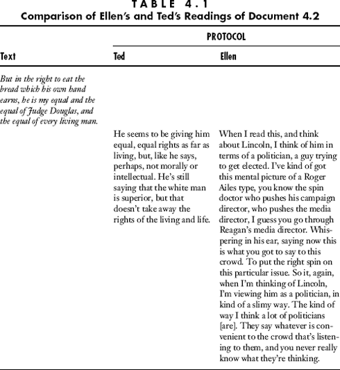

艾伦将林肯描绘成一个虚伪的政客，一心只想赢得选举，这种观点符合一种由来已久的解读传统。理查德·霍夫施塔特在其著作*《美国政治传统》*中对林肯进行了人物刻画，他认为林肯在早期文献中的言论既迎合了废奴主义者，也迎合了“仇视黑人者”。 <sup>12</sup>他评论了林肯1858年7月10日在芝加哥发表的演讲（“让我们抛弃所有关于这个人与另一个人、这个种族与那个种族的争论……团结起来，成为一个民族”），并将其与林肯在……的演讲进行了比较。1858年9月18日，霍夫施塔特在查尔斯顿发表讲话（“我和其他人一样，都赞成将优越地位赋予白种人”），他评论说：

Ellen's framing of Lincoln as a disingenuous politician seeking to get elected falls within a well-established interpretative tradition. Richard Hofstadter, who profiled Lincoln in his *American Political Tradition*, characterized Lincoln's words in the earlier document as appealing at once to abolitionists and “Negrophobes.”<sup>12</sup> Remarking on a speech Lincoln gave in Chicago on July 10, 1858 (“Let us discard all this quibbling about this man and the other man, this race and that race…and unite as one people”) and comparing it with a speech Lincoln gave in Charleston on September 18, 1858 (“I as much as any other man am in favor of having the superior position assigned to the white race”), Hofstadter remarked that it was

很难断定真正的林肯究竟是芝加哥演讲的那位，还是查尔斯顿演讲的那位。或许他当时对自己的每一句话都深信不疑；或许他的内心也早已分裂。无论如何，这一切很容易看出是一位职业政客为了拉选票而采取的手段。<sup>13</sup>

not easy to decide whether the true Lincoln is the one who spoke in Chicago or the one who spoke in Charleston. Possibly the man devoutly believed each of the utterances at the time he delivered it; possibly his mind too was a house divided against itself. In any case it is easy to see in all this the behavior of a professional politician looking for votes.<sup>13</sup>

艾伦和霍夫施塔特都以政治竞选的需要为由，解释了林肯言论中看似矛盾之处。因为林肯需要争取两派选民的支持，所以他不得不言辞前后矛盾。但“分裂的林肯”这种解读并非理解这些文献的唯一途径。

Both Ellen and Hofstadter resolved apparent contradictions in Lincoln's words by appealing to the exigencies of a political campaign. Because Lincoln needed to woo voters from both camps, he needed to talk out of both sides of his mouth. But the “divided Lincoln” interpretation is not the only way to understand these documents.

林肯在文献4.2中的言论使我们陷入了语境化思考的困境。如果我们假定种族关系本质上是连续的，就会发现林肯的言论存在矛盾之处。这些矛盾反过来又促使我们去构建语境，以解释为什么林肯会对不同的人说出不同的话。但如果我们一开始就相信清晰的语言和纯粹的逻辑本身就是历史的一部分，那么面对这些明显的矛盾，我们就能做出不同的回应。这些矛盾就成了我们探索自身与过去断裂的机会——这是试图跨越时空鸿沟的必然结果。

Lincoln's statements in Document 4.2 thrust us into the dilemma of contextualized thinking. If we presume an essential continuity in race relations, we see inconsistencies in Lincoln's words. These inconsistencies in turn lead us to create a context to explain why, for instance, Lincoln would say different things to different people. But if we begin with the belief that clear language and pure logic are themselves historical, then we are open to different responses in the face of apparent inconsistencies. Inconsistencies become opportunities for exploring our discontinuity with the past, the inevitable consequence of trying to bridge spatial and temporal gaps across the ages.

回想一下，道格拉斯和林肯之间的争论焦点在于《独立宣言》中隐含的一个逻辑推理。如果正如《宣言》所言，“人人生而平等”，而正如道格拉斯所言，“黑人与我不平等”，那么按照道格拉斯的定义，黑人就不能被视为人。如果林肯所探讨的问题正是如此，那么他的观点是明确无误的。

Recall that what is at issue between Douglas and Lincoln is an implied syllogism flowing from the Declaration of Independence. If, as the Declaration stated, “all men are created equal” and if, as Douglas stated, “the Negro is not my equal” then, by Douglas' definition, the Negro is not to be considered a man. If this was the question Lincoln addressed, his views were unequivocal.

理查德·韦弗在其*著作《修辞伦理学》*中阐述了林肯如何运用“定义论证”策略，即通过逐一剔除无关的次要问题，揭示问题的本质。 <sup>14</sup>尽管其他政治家从历史、比较政治、圣经或当时的形势等角度审视奴隶制问题，但林肯的策略是从基本原则出发进行论证。他的《皮奥里亚演讲》为我们深入了解这种论证风格提供了重要线索。在这次演讲中，林肯告诉听众，他将聚焦于奴隶制问题的“本质”。他以“人的属”这一问题开篇，而这恰恰是文献4.1和4.2中讨论的核心问题：

In his *Ethics of Rhetoric*, Richard Weaver demonstrated how Lincoln “argued by definition” a strategy that attacked a problem by whittling away at the side issues to reveal its unambiguous inner essence.<sup>14</sup> Although other statesmen examined slavery from the perspective of history, comparative politics, the Bible, or the exigencies of the moment, Lincoln's tack was to argue from first principles. His “Speech at Peoria” provides insight into this style of argument. In this case, Lincoln told his audience that he would focus on the “naked merits” of the issue of slavery. He began his speech with the question of the genus of man, precisely the issue at the heart of the exchange in Documents 4.1 and 4.2:

有人说，对南方人给予平等的正义，就要求我们同意将奴隶制扩展到新的国家。也就是说，既然你们不反对我把我的猪带到内布拉斯加州，那么我也就不能反对你们带走你们的奴隶。我承认，如果猪和黑人之间没有区别，这完全合乎逻辑。但是，既然你们这样要求我否认黑人的人性，我想问问你们南方人自己是否也曾愿意这样做？<sup>15</sup>

Equal justice to the South, it is said, requires us to consent to the extending of slavery to new countries. That is to say, inasmuch as you do not object to my taking my hog to Nebraska, therefore I must not object to your taking your slave. Now, I admit that this is perfectly logical, if there is no difference between hogs and Negroes. But while you thus require me to deny the humanity of the Negro, I wish to ask whether you of the South yourselves have ever been willing to do as much?<sup>15</sup>

林肯问道，如果奴隶只是动产，就像猪或牛一样，那么为什么奴隶贩子和猪贩子受到的待遇不一样呢？

If the slave was mere chattel, like a hog or cow, then why, asked Lincoln, was the seller of slaves treated differently from the seller of hogs?

你对他极其鄙夷。你不把他当朋友，甚至不把他当诚实的人。你的孩子不能和他的孩子玩；他们可以和那些小黑孩们自由嬉戏，但不能和“奴隶贩子”的孩子玩。如果你不得不和他打交道，你会尽量避免和他有任何身体接触。你通常会和遇到的其他人握手；但对于奴隶贩子，你会刻意回避这种礼节——本能地避开这种阴险的接触。即使他发了财，退出了奴隶贩子的生意，你仍然会记得他，仍然会禁止和他以及他的家人来往。这是为什么呢？你对待那些贩卖玉米、棉花或烟草的人却不是这样吗？<sup>16</sup>

You despise him utterly. You do not recognize him as a friend, or even as an honest man. Your children must not play with his; they may rollick freely with the little Negroes, but not with the “slave dealer's” children. If you are obliged to deal with him, you try to get through the job without so much as touching him. It is common with you to join hands with men you meet; but with the slave dealer you avoid the ceremony—instinctively shrinking from the snaky contact. If he grows rich and retires from business, you still remember him, and still keep up the ban of non-intercourse upon him and his family. Now why is this? You do not so treat the man who deals in corn, cotton, or tobacco?<sup>16</sup>

林肯用其他例子进一步阐述了他的观点。例如，南方人应该如何看待当时居住在美国的433,643名自由黑人？此外，如果这些黑人的主人不认为“可怜的黑人对自己拥有某种天然的权利”，那么他们的自由又是如何以主人巨大的经济损失换来的呢？值得引用韦弗的总结：

Lincoln hammered at his point with other examples. How, for instance, should Southerners label the 433,643 free blacks living in the United States at that time? Moreover, how did their freedom come about, at great financial sacrifice to their owners, if these same owners did not feel that the “poor Negro has some sense of natural right to himself”? It is worth quoting Weaver's summary:

林肯始终坚持人类只有一个属的立场；在他早期的律师生涯中，他就明白，与其试图通过一系列论点来构建一个令人印象深刻的论证，不如基于一个无可辩驳的论点来展开论证。多年来，他始终顽固地坚持这一属的概念，并由此得出这样的命题：适用于整个家族的基本真理也适用于家族的各个分支。因此，既然《独立宣言》已经禁止了对人的奴役，那么原则上也禁止了对黑人的奴役。 <sup>17</sup>

Lincoln could never be dislodged from his position that there is one genus of human beings; and early in his career as lawyer he had learned that it is better to base an argument upon one incontrovertible point than to try to make an impressive case through a whole array of points. Through the years he clung tenaciously to this concept of genus, from which he could draw the proposition that what is fundamentally true of the family will be true also of the branches of the family. Therefore since the Declaration of Independence had interdicted slavery for man, slavery was interdicted for the Negro in principle.<sup>17</sup>

如果我们仔细审视林肯在文献4.2中的回应，就会发现一些容易被其充满争议的措辞所掩盖的细节。请注意，林肯唯一愿意明确承认道格拉斯观点的，是“两个种族之间存在生理差异”，但从那以后，林肯的措辞就变得含糊其辞了。林肯说，道德或智力方面或许存在差异。大多数当时的读者忽略了这个*“*或许”，但即便提出两个种族在道德和智力上可能相等，也必须将其置于十九世纪中期种族主义的背景下看待。斯坦福大学历史学家乔治·弗雷德里克森认为，林肯在此追随了他的共和党导师亨利·克莱的脚步。克莱主张逐步解放黑人，并在其政治生涯早期宣称，黑人“和我们一样，是理性的人，能够感受、反思，并判断作为人类一部分，他们自然拥有什么”。 <sup>18</sup>

If we look carefully at Lincoln's response in Document 4.2, we see aspects that are easily overshadowed by its charged language. Notice that the only point Lincoln was willing to concede unequivocally to Douglas is a “physical difference between the two races” but from then on Lincoln equivocated. There is only *“perhaps”* a difference in moral or intellectual endowment, Lincoln said. This “perhaps” goes unnoticed by most contemporary readers, but even to raise the possibility that the two races were morally and intellectually equivalent must be viewed against the backdrop of mid-nineteenth-century racism. The Stanford historian George Fredrickson has argued that here Lincoln followed in the footsteps of his Republican mentor, Henry Clay, who advocated gradual emancipation and early in his career declared that blacks “are rational beings, like ourselves, capable of feeling, of reflection, and of judging of what naturally belongs to them as a portion of the human race.”<sup>18</sup>

弗雷德里克森对克莱的论述将*时代精神*与林肯的个人传记交织在一起。道德权利和法律权利之间看似细微的差别，在林肯以及他许多同时代人的心中却意义重大。由于我们无法想象一个将这种区分视为“进步”的世界，我们往往会认为林肯的言论自相矛盾，甚至更糟——虚伪自私。

Fredrickson's appeal to Clay interweaves aspects of the *Zeitgeist* with Lincoln's personal biography. What appears as a hairsplitting distinction between moral and legal rights was a meaningful difference in Lincoln's mind and in the minds of many of his contemporaries. Because we cannot fathom a world in which such a distinction would be viewed as “progressive” we tend to view Lincoln's statements as contradictory and inconsistent, or worse—as hypocritical and self-serving.

对泰德而言，林肯的话语揭示了林肯的内心世界，而他从中看到的林肯形象却是一个偏执狂。对艾伦而言，林肯的话语更多地反映了当时的社会状况，而非林肯本人的真实面目。韦弗、弗雷德里克森等人指出，“赤裸裸的真相”远比我们想象的更加隐晦。

For Ted, Lincoln's words cast light on Lincoln's soul, and the image perceived was that of a bigot. For Ellen, Lincoln's words disclosed more about the social situation than the naked truth about the man in that situation. What Weaver, Fredrickson, and others suggest is that the “naked truth” is more veiled than we think.

第三份文件出自林肯人生中的不同时期，属于另一种文献类型。与公开回应道格拉斯的信件不同，文件4.3是林肯写给肯塔基州玛丽·斯皮德的一封私人信件，玛丽是林肯的挚友约书亚·斯皮德的妻子。在信中，林肯描述了他乘坐密西西比河轮船的旅程，船上载着一群奴隶被沿河贩卖。

The third document was drawn from a different time in Lincoln's life and exemplifies a different genre of documentary evidence. Unlike the public response to Douglas, Document 4.3 was a private letter to Mary Speed of Kentucky, the wife of Joshua Speed, a close friend. In this letter, Lincoln described a journey on a Mississippi riverboat on which a group of slaves were literally being sold down the river.

**文件 4.3.**致玛丽·斯皮德的信

**Document 4.3.** Letter to Mary Speed

*亚伯拉罕·林肯于 1841 年 9 月 27 日写信给他的私人朋友玛丽·斯皮德*。

*Abraham Lincoln, writing to Mary Speed, a personal friend, September 27, 1841*.

顺便一提，船上有一个很好的例子，可以用来思考境遇对人类幸福的影响。一位绅士在肯塔基州的不同地方买了十二个黑人，准备把他们带到南方的一个农场。他们六六一组地被铁链锁在一起。每个人的左手腕上都套着一个小铁环，就像鱼线一样，把他们串成一串。在这种情况下，他们即将永远离开童年的家园、朋友、父母、兄弟姐妹，许多人甚至还要离开妻子和孩子，从此沦为奴隶……然而，在所有这些令人痛苦的境遇中……他们却是船上最快乐、最开朗的人。其中一个黑人，因为对妻子过于溺爱而被卖掉，他几乎不停地拉着小提琴；其他人则每天都跳舞、唱歌、讲笑话、玩各种纸牌游戏。“上帝使人类最糟糕的境遇也能忍受……”这句话真是至理名言。

By the way, a fine example was presented on board the boat for contemplating the effect of condition upon human happiness. A gentleman had purchased twelve Negroes in different parts of Kentucky and was taking them to a farm in the South. They were chained six and six together. A small iron clevis was around the left wrist of each so that the Negroes were strung together precisely like so many fish upon a trot-line. In this condition they were being separated forever from the scenes of their childhood, their friends, their fathers and mothers, and brothers and sisters, and many of them, from their wives and children, and going into perpetual slavery…yet amid all these distressing circumstances…they were the most cheerful and apparently happy creatures on board. One, whose offense for which he had been sold was an over-fondness for his wife, played the fiddle almost continually; and the others danced, sung, cracked jokes, and played various games with cards from day to day. How true it is that “God renders the worst of human conditions tolerable…”

*资料来源：*亚伯拉罕·林肯，*《演讲与著作》*，第 1-2 卷（纽约，1989 年），第 74 页。

*Source:* Abraham Lincoln, *Speeches and Writings*, vols. 1–2 (New York, 1989), 74.

这份文件有几个方面使其具有争议性。首先，历史学家在判断文件的可信度时通常会考虑其文体，而且在缺乏其他信息的情况下，他们往往认为私人信件比公开声明更具说服力。 <sup>19</sup> 其次，这份文件的内容乍一看呈现出一种令人费解的对比。面对奴隶们被锁链紧紧捆绑在狭小空间里的景象，林肯感到有必要评论的不是人类的苦难，而是人类的幸福。

Several aspects of this document make it provocative. First, historians typically consider the genre of a document when making judgments of probity, and, in the absence of other information, they tend to regard personal correspondence as more probative than public pronouncements.<sup>19</sup> Second, the substance of this document presents, at first glance, a perplexing contrast. Faced with the scene of slaves chained to each other in close quarters, Lincoln felt compelled to remark, not on human misery, but on human happiness.

泰德脑海中似乎形成某种解读的第一个点（见表4.2）是林肯描述那位“对妻子过分溺爱”的奴隶时。当被问及他对林肯的印象是否有所改变时，泰德回答说：

The first point at which an interpretation seemed to form in Ted's mind (see Table 4.2) was when Lincoln described the slave who had an “over-fondness for his wife.” When Ted was asked if his image of Lincoln had changed or stayed the same, he replied:

嗯，我还是不太确定。这可能需要我再读一遍，而且，我真的很想了解更多。他提出这个想法的真正目的是什么？除了“上帝”之外，他的最终结论是什么？“使最糟糕的人类境况也能忍受”？他似乎在说，人们能在最糟糕的条件下做到最好，这有点令人遗憾……这让他显得很关心他人。我相信他的确如此。然而，另一方面，就像我说的，把黑人看作是无忧无虑的人，那种形象……我不知道。这让我感到冒犯。所以，我想我不喜欢读这样的文章。

Well, I'm still kind of not sure. It's probably [a document] that I would have to read again, and really, I'd like to know more about this. Where was he really going with this idea? What was his total summation, rather than “God renders the worst of human conditions tolerable”? He seems to be saying that it is kind of unfortunate that people, that [they] could make the best of worst conditions…. So it gives him a sense of being caring. Which I do believe that he was. Yet, on the other hand, like I said, that the little, seeing Blacks as just happy-go-lucky people, that kind of image. I don't know. It's offensive to me. So, I don't like to read it, I guess.

这段评论有几个方面值得注意。首先，泰德有足够的自知之明，他意识到这份文件让他感到困惑，为了更好地理解，他或许应该再读一遍。其次，这段评论进一步阐述了泰德之前对林肯的刻板印象——一个偏执狂，尽管关于林肯“富有爱心”的评论暗示着他对这位第十六任总统仍抱有一些“守护神”式的看法。最后，泰德意识到自己对这段文字的情感反应，这些反应源于他认为带有根深蒂固偏见的描述。

Several aspects of this comment deserve note. First, Ted was sufficiently self-aware to know that the document leaves him uncertain, and that to understand it better he should probably read it again. Second, there is an elaboration of Ted's earlier image of Lincoln as bigot, though the comment about Lincoln “being caring” hints at some vestige of the “patron saint” view of the sixteenth president. Finally, Ted displayed an awareness of his emotional reactions to the text, reactions to images that he perceived as deeply bigoted.

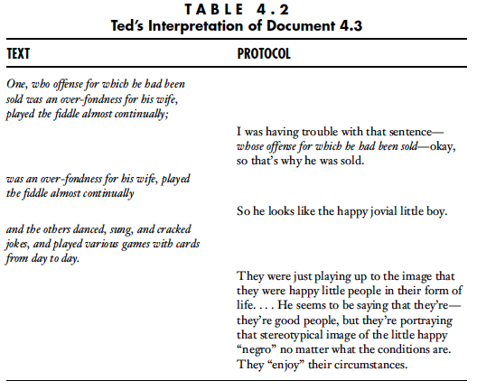

艾伦的解读与此惊人地相似（见表4.3）。这封信令人困惑：林肯怎么会如此冷酷无情，将人类的苦难误认为快乐？但林肯真的像他字里行间所暗示的那样冷酷无情吗？哪些缺失的背景信息可能会让我们对斯皮德的信有不同的理解？

Ellen's reading was remarkably similar (see Table 4.3). The letter generated perplexity: How can Lincoln be so callous as to mistake human misery for cheerfulness? But is Lincoln really as callous as his words suggest? What missing pieces of context might lead us to view the Speed letter differently?

林肯对那些被迫离开家园和亲人的人们的苦难视而不见吗？还有什么比他对玛丽·斯皮德说的这些话更能证明他对奴隶的痛苦麻木不仁呢？乔治·弗雷德里克森在写下这些话时，想到了林肯在写给斯皮德的信中所说的话在现代人听来会是怎样的感受：

Was Lincoln blind to the suffering of people wrenched from their homes and families? What better evidence could there be for a gross insensitivity to the pain of slaves than these words to Mary Speed? George Fredrickson had in mind how Lincoln's words in the Speed letter would strike the modern ear when he wrote:

这种哲学思辨很难说是反奴隶制热情的体现，反而很容易被斥为自满、麻木或缺乏想象力的表现。然而，它却基于一个在19世纪40年代日益罕见的假设：黑人对自身处境的反应可以用共同的人性来理解，而不是由特殊的种族特征造成的。<sup>20</sup>

Such philosophizing was hardly indicative of antislavery zeal, and it can easily be condemned as a manifestation of complacency, insensitivity, or lack of imagination. But it was nevertheless based on the assumption, increasingly rare in the 1840s, that blacks responded to conditions in a way that could be understood in terms of a common humanity and not as the result of peculiar racial characteristics.<sup>20</sup>

很难想象一个奴隶的人格地位受到质疑的世界，但这恰恰是亚伯拉罕·林肯出生的世界。试图重构一个我们无法完全了解的世界，这本身就是一件难事。这或许就是对过去进行语境化解读和时代错置解读之间的区别。

It is difficult to imagine a world in which the human status of slaves was in question, but that is precisely the world into which Abraham Lincoln was born. Trying to reconstruct a world we cannot completely know may be the difference between a contextualized and an anachronistic reading of the past.

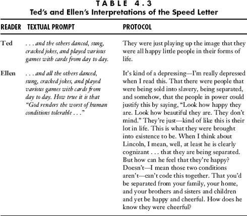

泰德对文件4.4（林肯呈递给他的三份文件中的最后一份）着墨不多。 <sup>21</sup>他表示自己对建立自由奴隶殖民地的计划已有所了解，阅读这份文件并没有对他关于林肯的看法产生任何影响。而艾伦则利用这份文件来丰富她对林肯的印象。她首先关注的是时间因素，指出这篇演说是在内战中期发表的。随着阅读的深入，她脑海中逐渐形成了林肯的另一个形象：

Ted had relatively little to say about Document 4.4, the last of three documents by Lincoln presented to him.<sup>21</sup> He noted that he was broadly familiar with plans for colonies of freed slaves and that reading this document did little to influence his views about Lincoln one way or the other. Ellen, on the other hand, used it to flesh out her image of Lincoln. She began with its temporal aspects, noting that the address was delivered in the middle of the Civil War. As she read it, a different image of Lincoln formed in her mind:

林肯正在认真地处理一个在当时看来似乎合情合理的问题。但我感觉他正在努力解决一个根本没有完美解决方案的问题。这已经是目前最好的办法了。所以我把他看作是一个问题解决者……而不是那种试图给出含糊其辞的油滑政客。他是一位首席执行官或其他类型的……决策者试图处理某个问题或棘手的问题。他在第一篇文章[Doc. 4.2]中形象非常单一，有点像个油滑的政客。但在写给玛丽·斯皮德的信中，他展现了另一面，有人情味。而现在，他的形象又开始丰满起来，我感觉他更像是一位首席执行官，试图解决问题，试图平衡战争，未雨绸缪，思考战后该如何应对，并想出办法——这一切都发生在《解放奴隶宣言》颁布之前。是在《解放奴隶宣言》颁布之前吗？是的，是在之前。所以，我的意思是，他可能已经有了这个想法，他一直在思考，我们该如何处理如此庞大的奴隶群体？也许在1862年，殖民确实是一个可行的选择。这让我想起了英国对澳大利亚的做法。把所有不受欢迎的人都运到澳大利亚。

[Lincoln] is conscientiously trying to deal with a problem that is something that apparently made sense in that time frame. And I get the feeling that he is wrestling with something that doesn't really have a good solution. This is the best you can have for now. So I kind of see him as problem-solver…not the slimy politician trying to give [unclear]. [He is a] CEO or some type of decision-maker trying to deal with a problem or acute problem. He was real one-dimensional in the first article [Doc. 4.2], kind of a slimy politician. Then he has another side with the letter to Mary Speed, kind of human. And now this is again another, it's beginning to fill out, but now I see him more as the chief executive and trying to deal with problems, trying to balance a war, thinking ahead, what are we going to do after the war and sort of coming up with—and this is prior to the Emancipation Proclamation. Is this prior to the Emancipation Proclamation? Yes, this is prior. So, I mean he may have had this idea in mind, so he's thinking forward, and how are we going to deal with this huge number of slaves? Maybe colonizing is certainly a viable option in 1862. It kind of reminds me of what the British did with Australia. Ship all the undesirables down to Australia.

艾伦在此提供了丰富的互文性解读。她引用了前三份文件中的两份，并以这些早期文件为背景，构建了她对文件4.4的理解。在她脑海中浮现出一个多面人物的形象：有时是“油滑的政客”，有时是充满爱心的人，而在这份文件中，他则是一位从事战略规划的首席执行官。她似乎意识到，这样的计划虽然在今天看来匪夷所思，但在十九世纪后半叶却更有意义。她将林肯的计划比作澳大利亚，意在寻找能够进一步阐释其背景的相似之处。为了理解林肯，艾伦将*时代精神*的元素与内战的年表相结合，并以此为基础，开始构建林肯生平的传记背景。

Ellen provided a richly intertextual reading here. She made reference to two of the three previous documents, and her understanding of Document 4.4 was formed with these earlier documents as backdrop. What emerged in her mind was an image of a multifaceted human being, a “slimy politician” in one instance, a caring person in another, and in this document a CEO engaged in strategic planning. There seems to be a recognition that such a plan, although outlandish today, made more sense in the latter half of the nineteenth century. The analogy to Australia represented a search for parallels that would further contextualize Lincoln's plan. To understand Lincoln, Ellen combined elements of the *Zeitgeist* with a chronology of the Civil War, and in so doing began to form the basis for a biographical context of Lincoln's life.

**文件 4.4.**关于殖民化的讲话

**Document 4.4.** Address on Colonization

*殖民化获释黑人的想法早在十九世纪初就已提出。许多反对奴隶制的白人积极倡导殖民化，他们认为只有将黑人迁徙到其他地方，才能实现真正的自由和平等。亚伯拉罕·林肯长期以来都支持这一想法，1862年，国会拨款资助一项殖民化计划。以下摘自林肯于1862年8月14日在白宫向一群自由黑人发表的《关于殖民化的演说》*。

*Colonization of freed blacks was an idea proposed early in the nineteenth century. Many whites who opposed slavery actively advocated colonization, maintaining that true freedom and equality could be realized only by relocating the black population. Abraham Lincoln had long favored the idea, and, in 1862, a sum of money was appropriated by Congress to aid in a colonization program. The following is from Lincoln's “Address on Colonization” delivered to a group of free black men at the White House on August 14, 1862*.

你们种族为何要被殖民？又该在哪里殖民？如果我们一开始就选择那些不自由、思想被奴役蒙蔽的人，那么我们一开始的条件就非常差。如果聪明的有色人种能够参与其中，或许就能取得更大的成就。至关重要的是，我们一开始就必须选择那些能够像白人一样思考的人，而不是那些长期遭受压迫的人……我考虑建立殖民地的地方是中美洲……那里的土地非常适合任何民族，拥有丰富的自然资源和优势，尤其气候与你们的故乡相似，因此非常适合你们的体质。

Why…should the people of your race be colonized, and where? If we deal with those who are not free at the beginning, and whose intellects are clouded by slavery, we have very poor materials to start with. If intelligent colored men…would move in this matter, much might be accomplished. It is exceedingly important that we have men at the beginning capable of thinking as White men, and not those who have been systematically oppressed…. The place I am thinking about having for a colony is in Central America…. The country is a very excellent one for any people, and with great natural resources and advantages, and especially because of the similarity of climate with your native land—thus being suited to your physical condition.

*资料来源：*亚伯拉罕·林肯，*《演讲与著作》*，第 1-2 卷（纽约，1989 年），第 368 页。

*Source:* Abraham Lincoln, *Speeches and Writings*, vols. 1–2 (New York, 1989), 368.

约翰·贝尔·罗宾逊在其演讲（文献4.5）中，以宗教论证来支持奴隶制：“上帝创造他们是为了让他们成为有用的奴隶，并要求我们这样使用他们。如果我们背信弃义，将他们抛弃，让他们自生自灭，我们就把他们重新变成了野蛮人。”这些话语掷地有声，在我们看来却荒谬至极。但我们应该意识到，以宗教为由为奴隶制辩护，可以追溯到英国与非洲接触之初。 <sup>22</sup>读着约翰·贝尔·罗宾逊的言论，泰德对那些与他自身种族观念相悖的观点感到愤怒。当罗宾逊将奴隶制与松树传教团联系起来时，他脱口而出：“我的脑子一片混乱，*啊！*我无法用语言来形容。”当罗宾逊声称如果将黑奴送回非洲，他们“不到五十年就会退回到异教和野蛮状态”时，泰德镇定下来回应道：“他是不是认为他们是*野蛮人*？我的意思是，这是在否定他们原本的生活方式和文化，我认为这不应该这样做。”当被问及阅读罗宾逊的文字是否对林肯的观点有所启发时（泰德在前三份文件中重新接触到了林肯的观点），泰德回答说：“没有，因为我没有看到罗宾逊在文中提到林肯，而且，我重新阅读了作者的名字，这个名字听起来很陌生，我根本无法将它与林肯联系起来。”

John Bell Robinson begins his address (Document 4.5) by advancing a religious argument for slavery: “God himself has made them for usefulness as slaves and requires us to employ them as such and if we betray our trust and throw them off on their own resources, we reconvert them into barbarians.” These are powerful words that strike us as absurd, but we should recognize that a religious justification for slavery goes back to the inception of English contact with Africa.<sup>22</sup> Reading John Bell Robinson, Ted bristled at ideas foreign to his own views on race. When Robinson linked slavery to the pine mission, he blurted: “My mind is going, *Argh!* I can't describe it in words.” When Robinson stated that if Negro slaves were sent back to Africa, they would fall back into “heathenism and barbarism in less than fifty years,” Ted composed himself and responded: “Is that what he thinks they were—*barbarians*—I mean it's putting down their own natural life style and culture as they were, which I don't think should be done.” And when he was asked if reading Robinson's words shed any light on Lincoln's views, with which he had been reacquainted in the previous three documents, Ted responded: “No, because it's, I don't see Lincoln being addressed in this or, rereading his name who wrote it, that name doesn't sound familiar and I can't connect it to Lincoln at all.”

我们应该如何解读泰德的解读？当然，从某种程度上来说，泰德是对的。约翰·贝尔·罗宾逊贬低了他所认识的非洲人的“自然生活方式”，他的言辞中充满了对与他不同的人的偏见和不尊重。但从另一个层面来看，泰德的评论也让我们得以窥见许多大学生所持有的对过去的一种看法，这种看法被大卫·洛文塔尔描述为一种“永恒的过去”，在这种过去中，我们用来理解当下的概念（“种族主义”、“偏见”、“宽容”、“多元文化理解”）被视为静态的范畴，在时间和空间中保持不变。 <sup>23</sup>在这样的过去中，约翰·贝尔·罗宾逊本应有不同的想法。但公平地说，罗宾逊先生也不应该出生在一个像温斯罗普·乔丹和乔治·弗雷德里克森所提醒我们的那样，将白人欧洲男性奉为评判人类标准的时代。

How should we construe Ted's reading? On one level, of course, Ted is right. John Bell Robinson is “putting down the natural life style” of the Africans he knew, and his words smack of intolerance and disrespect for people unlike himself. But on another level, Ted's comments provide a glimpse into a view of the past shared by many college students, a view David Lowenthal characterized as a “timeless past” in which the constructs we use to make sense of our present (“racism” “bigotry” “tolerance” “multicultural understandings”) stand as static categories unchanged across time and space.<sup>23</sup> In such a past, John Bell Robinson should have thought differently. But to be fair to Mr. Robinson, he also should not have been born into a world that, as Winthrop Jordan and George Fredrickson remind us, exalted the white European male as the standard by which humanity was to be judged.

文件 4.5.奴隶制的益处

Document 4.5. Benefits of Slavery

*摘自*《奴隶制与反奴隶制图片集：从道德、社会和政治角度考虑黑人奴隶制的优势和黑人自由的益处》，*作者约翰·贝尔·罗宾逊，一位支持奴隶制的白人发言人，宾夕法尼亚州，1863 年，第42 页*。

*From* Pictures of Slavery and Anti-Slavery: Advantages of Negro Slavery and the Benefits of Negro Freedom Morally, Socially, and Politically Considered *by John Bell Robinson, a White pro-slavery spokesperson, Pennsylvania, 1863, p. 42*.

上帝创造他们是为了让他们成为有用的奴隶，也要求我们这样使用他们。如果我们背信弃义，任由他们自生自灭，我们就把他们重新变成野蛮人。我们的天父创造我们是为了*统治*，而让黑人服侍。如果我们……为了人类的福祉和祂自身的荣耀而背弃祂神圣的安排，篡改祂的律法，我们必将覆灭，永远蒙受耻辱，甚至沦为其他文明国家的臣民……将所有黑人安置在他们原先的土地上几乎是不可能的，因此永远无法实现，这片绿色的地球上也没有其他地方适合他们。把他们送到其他任何地方都是极其残忍和野蛮的行为。即使能把他们全部安置在非洲海岸，不到五十年，他们就会重新回到异教和野蛮的状态。

God himself has made them for usefulness as slaves, and requires us to employ them as such, and if we betray our trust, and throw them off on their own resources, we reconvert them into barbarians. Our Heavenly Father has made us to *rule*, and the Negroes to serve, and if we…set aside his holy arrangements for the good of mankind and his own glory, and tamper with his laws, we shall be overthrown and eternally degraded, and perhaps made subjects of some other civilized nation…. Colonization in their native land of all the Negroes would be so nearly impracticable, that it will never be done, and no other spot on this green earth will do for them. It would be the height of cruelty and barbarism to send them anywhere else. If they could all be colonized on the coast of Africa, they would fall back into heathenism and barbarism in less than fifty years.

我们也从泰德的言论中看出，语境化的思考方式并非*如此*。泰德说罗宾逊没有提及林肯，这没错。但从另一个层面来看，泰德错了，因为罗宾逊让我们对林肯时代的思想图景有了更深入的了解。罗宾逊是这一图景一端的标志，正如威廉·劳埃德·加里森（见文献4.6）是另一端的标志一样。在一个由各种不同层次的思想构成的世界里，林肯的思想又呈现出怎样的层次？他在思想谱系中的位置又在哪里？

We also see what contextualized thinking does *not* look like when Ted tells us that Robinson teaches him nothing about Lincoln. Ted is right in saying that Robinson does not mention Lincoln. But on another level, Ted is wrong, for Robinson tells us a great deal about the mental landscape that prevailed in Lincoln's day. Robinson is a marker at one end of that landscape, just as William Lloyd Garrison (see Document 4.6) is a marker at the other end. In a universe of ideas of different textures, what is the texture of Lincoln's ideas? Where can he be located on the spectrum of ideas?

这个问题也让艾伦感到困惑。罗宾逊的文件并没有让艾伦对林肯发表任何自发的评论。她完全被罗宾逊充满煽动性的言辞所困扰，并将此与希特勒的“最终解决方案”相提并论。罗宾逊声称被遣返的奴隶会“重新堕入异教和野蛮状态”，这番话引发了艾伦如下的反应：

This question provided a stumbling block for Ellen as well. Robinson's document elicited from Ellen no spontaneous comments about Lincoln. She was consumed by Robinson's charged words, drawing comparisons with Adolf Hitler's “Final Solution.” Robinson's statement that repatriated slaves would “fall back into heathenism and barbarism” sparked this response:

我简直不敢相信有人会这么想。真的不敢相信！这太糟糕了。但这真的不会影响我对林肯的看法。我一直都很关注他这个人。我简直气愤不已！真正奇怪的是，我又一次想象他在某个演讲厅里演讲的情景，而这些话——虽然现在看来相当具有煽动性，但在1863年可能并没有那么具有煽动性。[这]反而凸显了……一部分人认为奴隶是次等人，我们这样做是为了他们好，如果我们不让他们成为我们的奴隶，他们就会变成异教徒，就会迷失方向。

I mean I can't believe that anybody thinks this. I can't believe! I mean this is awful. It really doesn't impact how I think about Lincoln. I'm really focused on this guy. I'm just outraged! The thing that is really strange is that, again, I can picture him speaking in some type of lecture hall, and again this being delivered and it not being—this is pretty inflammatory stuff, but I mean it probably wasn't all that inflammatory back in 1863. [It] kind of emphasizes how one section of the population viewed slaves as subhumans and we're doing this for their own good and if we didn't bring them into our servitude that they would be heathens and they'd be lost.

文件 4.6.废除声明

Document 4.6. Statement on Abolition

*摘自威廉·劳埃德·加里森 (William Lloyd Garrison) 于**1830 年 2 月 12 日*在《普遍解放的天才》(Genius of Universal Emancipation)上发表的一篇社论。加里森 (1805–79) 是一位杰出的白人废奴主义者，*在 1831 年创办自己的反奴隶制期刊之前，**曾短暂担任《*天才》的助理编辑。

*From an editorial by William Lloyd Garrison appearing in the* Genius of Universal Emancipation, *February 12, 1830. Garrison (1805–79) was a leading white abolitionist and worked for a short time as the assistant editor of the* Genius *before beginning his own antislavery periodical in 1831*.

我否认上帝创造了……人类中的某一部分优于另一部分的说法。无论多少个种族融合在一起——无论部落或国家之间存在多少种肤色差异——只要给予他们相同的进步机会和公平的起点，结果都将同样辉煌、同样卓有成效、同样伟大。

I deny the postulate, that God has made…one portion of the human race superior to another. No matter how many breeds are amalgamated—no matter how many shades of color intervene between tribes or nations—give them the same chances to improve, and a fair start at the same time, and the result will be equally brilliant, equally productive, equally grand.

理想情况下，艾伦应该能够意识到，罗宾逊为奴隶制辩护的宗教理由，恰恰是林肯极力避免的那种论调。事实上，当林肯在谈及奴隶制时提及上帝，是为了强调不同种族的人们在上帝之下所共享的共同纽带（文献4.3）。从这个意义上讲，罗宾逊和林肯的观点可谓截然相反。

Ideally Ellen would have recognized that Robinson's religious justification for slavery is precisely the kind of statement Lincoln eschewed. Indeed, when Lincoln did refer to God in the context of slavery, it was to comment on the common bond under God shared by people of different races (Document 4.3). In this sense, Robinson and Lincoln could not have been further apart.

结论

CONCLUSION

这两位老师对这些文献的处理方法截然不同。对于历史系学生泰德来说，林肯的观点与这些文献中的文字直接对应；而物理系学生艾伦则对通过这些文献探寻“真实的”林肯持谨慎态度，她试图理解不同环境下不同时期的林肯。艾伦的解读与泰德的另一个区别在于，她对不同文献进行了大量的互文性分析。我们认为，这些交叉引用是她试图在本次任务的框架内，通过重构林肯所处的社会舆论环境来构建语境。在任务的最后，当艾伦遇到勒罗内·贝内特关于林肯是“一个悲剧性的缺陷人物，与他同时代的大多数白人一样抱有种族偏见”的说法时，她能够运用在本次任务中学到的知识来丰富这一论断。<sup>24</sup> 艾伦部分同意贝内特的说法，但她补充道：“林肯显然和……罗宾逊的想法不一样。”此外，她还对贝内特的文章本身进行了背景说明：“1968年，嗯，那一年，就在罗伯特·肯尼迪和马丁·路德·金遇刺之前。”

These two teachers differed dramatically in their approach to the documents. For Ted, the history major, Lincoln's views corresponded directly to the words in these documents; Ellen, the physics major, was wary of pursuing the “real” Lincoln through these documents, trying instead to understand the different Lincolns who responded to different circumstances. Further distinguishing Ellen's reading from Ted's were her many intertextual connections across documents. We view these cross-references as attempts to create a context within the confines of this task by reconstructing the climate of opinion in which Lincoln dwelled. At the end of the task, when Ellen encountered Lerone Bennett's claim that Lincoln was a “tragically flawed figure who shared the racial prejudice of most of his white contemporaries” she was able to use what she had learned in this task to add texture to this statement.<sup>24</sup> Agreeing in part with Bennett's assertion, Ellen added this qualifier: “Lincoln clearly wasn't on the same wavelength as…Robinson.” Moreover, she contextualized Bennett's article itself: “1968, let's see, that was a year, this is just prior to the Bobby Kennedy and Martin Luther King assassinations.”

在整个过程中，艾伦在权衡林肯的观点时，始终保持着自己的立场。她能够表达反对意见，却并不感到惊讶。她可以拒绝，但仍然能够理解。在阅读斯蒂芬·道格拉斯的著作时，她注意到其中“极其种族主义的语言”，但她也指出，“这并非煽动性的言论。这只是事实，是有据可查的信念——这显然是真的，人人都知道。这就是所谓的传统智慧，常识。”艾伦在此获得了对历史的基本理解。过去并非仅仅是现在的序幕，而是与现在截然不同的。她将自己的观点与她所阅读的人物的观点拉开距离，使她能够像路易斯·O·明克所说的那样，将历史视为“一个持续不断的邀请，邀请我们去发现并进入与我们截然不同的视角”。 <sup>25</sup> 艾伦的理解具有相似之处。1850年白人社会所看到的，以及促使这个社会在美国土地上传播奴隶制的因素，与我们今天所看到的截然不同。

Throughout the task, Ellen gauged Lincoln's views without losing sight of her own. She was able to disapprove without being astonished. She could reject and still understand. When reading Stephan Douglas, she called attention to the “incredibly racist language” but noted that “it's not inflammatory. It's matter of fact, documented belief—this is obviously true, everyone knows it. It's what they would call conventional wisdom, common knowledge.” Ellen here achieved a fundamental historical understanding. The past is not mere prologue to the present but is discontinuous with it. The distance she created between her own views and those of the people she read about allowed her to view history, in Louis O. Mink's words, as a “standing invitation to discover and enter into modes of seeing quite different from our own.”<sup>25</sup> What Ellen understood is analogous. What white society saw in 1850, what allowed this society to propagate the institution of slavery on American soil, is not what we see today.

两位教师提出的难题在于，历史学方面的学术训练与历史语境思维能力之间似乎存在一种反比关系。然而，这种模式并非完全反常；我们早期的研究结果，尽管样本量很小（仅12位教师），却表明本科专业与构建历史语境的能力之间并无明确的关联。

The two teachers here present the puzzle of an inverse relationship, or so it would seem, between academic training in history and the disposition to think contextually. This pattern, however, is not entirely anomalous; our early findings, although based on a very small sample (twelve teachers), showed no clear-cut relationship between undergraduate major and the ability to create a historical context.

这一发现虽属初步且暂定，但对于关注教师学科知识的研究者而言并非全新。 <sup>26</sup>本科专业教学的前提是学生在入学前已掌握学科的基本概念。而这些基本概念正是向学生传授该学科的核心。然而，通常情况下，大学一年级、二年级、三年级乃至四年级学生头脑中假定存在的这些概念很少经过检验、测试或评估。在很多情况下，大学教师所假定的基础仅仅是他们凭空想象出来的。

This finding, tentative and provisional, is not entirely new to researchers concerned with teacher's subject matter knowledge.<sup>26</sup> The undergraduate major proceeds on the assumption that students have mastered fundamental disciplinary conceptions prior to coming to the university. It is precisely these fundamental conceptions that are at the center of teaching that discipline to the young. But, as is often the case, the notions presumed to exist in the minds of college freshmen, sophomores, juniors, and seniors are rarely checked, tested, or assessed. In many cases, the foundation assumed by university instructors is a figment of their imaginations.

当历史系学生进入教育硕士项目时，我们假定他们精通历史。教师教育的任务是教导未来的教师如何教学。但是，如果……诸如此类的评估——这些评估使我们能够检验学科的基本假设——是否会削弱我们对学生基础知识的信心？当我们在教人如何教书的过程中意识到，我们首先必须教他们如何认识知识时，教师教育的工作就变得格外复杂了。

When history majors come to M.A. programs in teaching, we presume that they know their history. The job of teacher education is to teach prospective teachers about teaching. But what happens when assessments such as these, assessments that allow us to examine fundamental disciplinary assumptions, undermine our confidence in student's fundamental knowledge? The job of teacher education becomes doubly complicated when, in the midst of teaching people how to teach, we realize that we first must teach them how to know.

本章结尾，我提出了一个“那又怎样”的问题，因为如今人们经常听到“真实性评估”的说法，认为这种评估能够考察学生“像历史学家一样思考”的能力。这些说法常常得到热烈的赞同，但赞同的人往往从未问过一个更根本的问题：我们为什么要关心学生（或者教师）是否能够像历史学家一样思考？

I end this chapter with the “so what” question, for one hears a great deal nowadays about “authentic assessments” that tap student's ability to “think like historians.” These pronouncements are often greeted with enthusiastic nods, often by people who never ask a prior—and, in my eyes, more basic—question: Why should we care if students, or teachers for that matter, are able to think like historians?

这里所描述的那种历史思维方式，尤其是认识到自身概念体系的局限性并以此来思考过去的倾向，对于教导人们如何理解与自己不同的人至关重要。如果我们从未意识到个人经验的局限性，又怎能指望理解那些逻辑与我们相悖、用我们自身的标准来评判时显得难以理解的人呢？

Historical thinking of the type described here, and in particular the disposition to think about the past by recognizing the inadequacy of one's own conceptual apparatus, is essential in teaching people how to understand others different from themselves. If we never recognize that our individual experience is limited, what hope is there of understanding people whose logic defies our own, whose choices and beliefs appear inscrutable when judged against our own standards?

许多问题依然存在：我们并不确切地知道人们是如何学会情境思考的。我们不知道他们是在何时何地学会的。我们甚至不知道正规学习在情境思考能力发展过程中扮演着怎样的角色。然而，有一点我们确信无疑：情境思考能力并非如大卫·哈克特·费舍尔所言，是某种“纯粹的学术完美目标”。 <sup>27</sup>

Many questions remain: We do not know how, exactly, people learn to think contextually. We do not know where they learn it when they do. We do not even know the role of formal study in its development. We are convinced, however, of one thing: The ability to think contextually is not, in David Hackett Fischer's words, some “pristine goal of scholarly perfection.”<sup>27</sup>

如果我们继续犯下用核前思维来理解核世界问题的错误，就不会有后核世界。如果我们坚持用昨天的方案来解决今天的问题，我们可能会突然发现明天的可能性已经耗尽。如果我们在二十世纪中期继续追求十九世纪的意识形态目标，那么二十一世纪的前景将越来越黯淡。<sup>28</sup>

If we continue to make the…error of conceptualizing the problems of a nuclear world in prenuclear terms, there will not be a postnuclear world. If we persist in the error of applying yesterday's programs to today's problems, we may suddenly run short of tomorrow's possibilities. If we continue to pursue the ideological objectives of the nineteenth century in the middle of the twentieth, the prospects of a twenty-first are increasingly dim.<sup>28</sup>

正如菲舍尔提醒我们的那样，面对那些威胁要撕裂我们社会和世界的种种问题，理性是一种极其脆弱的武器。然而，它却是我们唯一拥有的武器。

Reason, as Fischer reminds us, is a pathetically frail weapon in the face of the problems that threaten to rend our society and our world. It is, however, the only weapon we possess.

笔记

NOTES

本章是为1992年10月在马德里自治大学举办的“历史与社会科学中的推理”研讨会而撰写的。它最初以印刷形式发表，由Janice Fournier担任第二作者，收录于一本基于……的书中。会议论文集：Mario Carretero 和 James F. Voss 主编，*《历史与社会科学中的认知与教学过程》*（新泽西州希尔斯代尔，1994 年）；概述发表于*《历史新闻》*第 48 期（1993 年）。我运用相同的文献和方法，研究了历史学家如何解读这些文献（见第一章）。该研究的完整描述发表于*《认知科学》*第 22 期（1998 年），第 319-346 页。

This chapter was prepared for a conference on “Reasoning in History and the Social Sciences” at Autonoma University of Madrid in October 1992. It first appeared in print, with Janice Fournier as second author, in a book based on the conference: Mario Carretero and James F. Voss, eds., *Cognitive and Instructional Processes in History and the Social Sciences* (Hillsdale, N.J., 1994); an overview appeared in *History News* 48 (1993). Using the same documents and procedure, I studied how historians read these documents (see Chapter 1). A full description of that study appeared in *Cognitive Science* 22 (1998), 319–46.

1.亚伯拉罕·林肯，*《演讲与著作》*，第 1-2 卷（纽约，1989 年），第 512 页。

1. Abraham Lincoln, *Speeches and Writings*, vols. 1–2 (New York, 1989), 512.

2. Lerone Bennett, Jr.，“亚伯拉罕·林肯是白人至上主义者吗？” 《*Ebony》* 23（1968 年 2 月），35-42。

2. Lerone Bennett, Jr., “Was Abe Lincoln a White Supremacist?” *Ebony* 23 (February 1968), 35–42.

3.布拉德利学校历史委员会，*《构建历史课程：学校历史教学指南》*（华盛顿特区，1988 年），第 9 页。

3. Bradley Commission on History in Schools, *Building a History Curriculum: Guidelines for Teaching History in Schools* (Washington, D.C., 1988), 9.

4.此处并非为认知任务环境辩护之时，批评者抨击这些环境扭曲了思维在其“自然环境”中的运作方式。我们目前正处于对认知理解的钟摆式摇摆之中，人类学方法比心理学实验室中更为传统的实验条件更受青睐。我深切理解这些批评；例如，参见迈克尔·科尔和芭芭拉·米恩斯主编的《*人们如何思考的比较研究：导论》*（马萨诸塞州剑桥，1981年）。然而，我们没有策略性地思考如何结合多种方法（每种方法都有其自身的局限性），而是陷入了非此即彼的争论，争论哪种方法最好。历史为这种思维弊病提供了一剂强效的解药。参见库尔特·勒温的《在特定时期定义“场域”》，载*《心理学评论*》第50卷第3期（1943年）。

4. This is not the place to offer a defense of cognitive task environments, which critics have assailed for distorting the way thinking goes on in its “natural habitat.” We are currently in the midst of a pendulum swing in understanding cognition, privileging anthropological approaches over the more traditional experimental conditions of the psychological laboratory. I am deeply sympathetic to the critiques; see, for example, Michael Cole and Barbara Means, eds., *Comparative Studies of How People Think: An Introduction* (Cambridge, Mass., 1981). However, rather than thinking strategically about how to combine multiple methods, each of which bears its own liabilities, we have debased ourselves with either/or contests over which method is best. The past offers a powerful antidote to this malady of thought. See Kurt Lewin, “Defining the ‘Field’ at a Given Time” *Psychology Review* 50, no. 3 (1943).

5.参见阿拉里克·K ·迪金森和彼得·J·李合著的《理解历史》（“Making Sense of History”），载于阿拉里克·K·迪金森、彼得·J·李和彼得·J·罗杰斯主编的*《学习历史》*（伦敦，1984年），第117-153页。李、迪金森及其同事丹尼斯·谢米尔特的开创性工作使一度萎靡不振、脆弱不堪的历史学习领域重焕生机。他们在20世纪80年代提出的问题至今仍在指导着全球各地的研究者。如果没有英国历史学习研究的影响，我无法想象自己的研究计划会是什么样子。

5. See Alaric K. Dickinson and Peter J. Lee, “Making Sense of History” in Alaric K. Dickinson, Peter J. Lee, and Peter J. Rogers, eds., *Learning History* (London, 1984), 117–53. The pioneering work of Lee, Dickinson, and their colleague Denis Shemilt invigorated a field that had grown moribund and brittle. The questions they framed in the eighties continue to guide researchers across the globe. I cannot envision my own program of research apart from the influence of the British work on learning history.

6.参见 Ronald Takaki 的著作《来自不同镜子的反思》，载《*教学宽容》* 3 (1994)，第 11-15 页；Winthrop D. Jordan 的著作《*白人凌驾于黑人之上：美国人对黑人的态度，1550-1812 年*》（纽约，1968 年）；George Fredrickson 的著作《一个人，却不是兄弟：亚伯拉罕·林肯与种族平等》，载《*南方历史杂志*》 41 (1975)，第 39-58 页。

6. See the work of Ronald Takaki, “Reflections from a Different Mirror” *Teaching Tolerance* 3 (1994), 11–15; Winthrop D. Jordan, *White Over Black: American Attitudes Toward the Negro, 1550–1812* (New York, 1968); George Fredrickson, “A Man but Not a Brother: Abraham Lincoln and Racial Equality” *Journal of Southern History* 41 (1975), 39–58.

7.大卫·哈克特·费舍尔，*《历史学家的谬误：走向历史思想的逻辑》*（纽约，1970 年）。

7. David Hackett Fischer, *Historian's Fallacies: Toward a Logic of Historical Thought* (New York, 1970).

8.请参阅本书第 3 章。

8. See Chapter 3 in this volume.

9. David N. Perkins，*《心灵的最佳作品*》（马萨诸塞州剑桥，1981 年）。

9. David N. Perkins, *The Mind's Best Work* (Cambridge, Mass., 1981).

10.先前对这些文件的研究表明，缺乏相关知识的人很容易对林肯生平事件的顺序感到困惑。为了减少这种情况的发生，并帮助参与者更好地理解任务，我们制作了一份林肯生平重大事件的时间线，从他当选伊利诺伊州议员到遇刺身亡。参与者会拿到这份时间线，并被告知可以随时查阅。文件逐一呈现，每份文件打印在单独的页面上，文件来源以粗斜体字显示在页面顶部。参与者完成对每份文件的评述后，会被要求回顾性地报告“任何内容”。否则，你还记得你在阅读这份文件时的想法吗？”如果参与者在评论中没有明确提及林肯的观点（并且在阅读过程中也没有明确提及），他们会被问到：“这份文件对林肯的种族观点有何启示？”

10. Previous work with these documents showed that people with little content knowledge quickly became confused about the sequence of events in Lincoln's life. To lessen this possibility and to help orient participants to the task, we developed a timeline of major events in Lincoln's life, from his election to the Illinois legislature to his assassination. People were given this timeline and told to refer to it at any time. Documents were presented one by one, each printed on a separate page, with the source of the document appearing at the top of the page in bold italics. Once participants finished commenting on each text, they were asked to report retrospectively on “anything else you remember yourself thinking as you read this document.” If participants did not explicitly address Lincoln's views in their comments (and had not done so explicitly during the reading), they were asked, “What light does this document shed on Lincoln's views about race?”

11. Donald E. Fehrenbacher，“只有他的继子：林肯与黑人”*内战史*20 (1974)，293–310。

11. Donald E. Fehrenbacher, “Only His Stepchildren: Lincoln and the Negro” *Civil War History* 20 (1974), 293–310.

12.理查德·霍夫施塔特，*《美国政治传统及其缔造者》*（纽约，1948 年）。

12. Richard Hofstadter, *The American Political Tradition and the Men Who Made It* (New York, 1948).

13.同上，第 116 页。

13. Ibid., 116.

14. Richard M. Weaver，*《修辞伦理学》*（芝加哥，1953 年）。

14. Richard M. Weaver, *The Ethics of Rhetoric* (Chicago, 1953).

15.林肯，《*演讲集》*，第 325-26 页。

15. Lincoln, *Speeches*, 325–26.

16.同上，第 326 页。

16. Ibid., 326.

17. Weaver，《*伦理学》*，第95页。

17. Weaver, *Ethics*, 95.

18. Fredrickson ，“不是兄弟”42。

18. Fredrickson, “Not a Brother” 42.

19.有关历史学家如何权衡文献证据体裁的例子，请参见本书第3章。另见路易斯·戈特沙尔克，*《理解历史：历史方法入门》*（芝加哥，1958年）。

19. See Chapter 3 in this volume for examples of historians weighing the genre of documentary evidence. See also Louis Gottschalk, *Understanding History: A Primer of Historical Method* (Chicago, 1958).

20. Fredrickson ，“不是兄弟” 44。

20. Fredrickson, “Not a Brother” 44.

21.这份文件附带了一篇冗长的序言，因为试点工作表明，即使是那些学习过这一时期课程的读者，也很少有人熟悉林肯在中美洲建立自由奴隶殖民地的计划。

21. This document was accompanied by a lengthy preamble because pilot work had shown that few readers, even those with course work in this period, were familiar with Lincoln's plans to establish colonies of freed slaves in Central America.

22.参见乔丹，《*白上黑》*。

22. See Jordan, *White Over Black*.

23. David Lowenthal，*《过去是一个异国他乡》*（英国剑桥，1985 年）；David Lowenthal，“永恒的过去：一些英美历史先入之见”，《*美国历史杂志*》 75（1989 年），1263-80。有关 Lowenthal 的最新立场，请参阅他的《*被过去所占据：遗产十字军东征和历史的战利品》*（纽约，1996 年）。

23. David Lowenthal, *The Past Is a Foreign Country* (Cambridge, England, 1985); David Lowenthal, “The Timeless Past: Some Anglo-American Historical Preconceptions” *Journal of American History* 75 (1989), 1263–80. For an update on Lowenthal's positions, see his *Possessed by the Past: The Heritage Crusade and the Spoils of History* (New York, 1996).

24. Bennett，“是亚伯拉罕·林肯吗？” 42 .

24. Bennett, “Was Abe Lincoln” 42.

25. Louis O. Mink（Brian Fay、Eugene O. Golob 和 Richard T. Vann 编辑），*《历史理解》* （纽约州伊萨卡，1987 年），第 103 页。

25. Louis O. Mink (Brian Fay, Eugene O. Golob, and Richard T. Vann, eds.), *Historical Understanding* (Ithaca, N.Y., 1987), 103.

26.参见国家教师学习研究中心，《学习*教学的研究成果*》（密歇根州东兰辛，1992 年）。

26. See the National Center for Research on Teacher Learning, *Findings on Learning to Teach* (East Lansing, Mich., 1992).

27. Fischer，《*历史学家的谬误》*，第 215 页。

27. Fischer, *Historian's Fallacies*, 215.

28.同上。

28. Ibid.

## 5

## 5

## 描绘过去

## Picturing the Past

**清空**思绪，试着想象两位历史人物的形象：一位清教徒和一位西部拓荒者。你脑海中的清教徒戴着高高的黑色带扣帽子吗？还是戴着一顶小巧的蕾丝帽？你脑海中的拓荒者是戴着头巾和皮套裤放牛吗？还是戴着遮阳帽在草原上照看鸡群？为什么你会想到这些特定的形象？为什么有些形象比其他形象更容易浮现在脑海中？

**C**lear your mind and try to conjure up images of two historical figures, a Pilgrim and a Western Settler. Does your Pilgrim wear a tall black hat with a buckle? Or a small lace cap? Is your Settler herding cattle in bandanna and chaps? Or tending chickens on the prairie in a sunbonnet? Why do these particular images come to mind? And why do some of these images come to mind more easily than others?

这篇简短的练习旨在引出我们的主题：文化假设在历史学习中的作用。这些假设往往根深蒂固，被视为理所当然，以至于我们甚至意识不到它们的存在。在历史的学习和教学中，假设扮演着关键角色。它们标示着历史中哪些内容是重要的，并将易于理解的经典推到前台。我们通常不假思索地按照时间顺序组织历史，根据特定的政治、外交和军事事件划分时代：制宪会议、重建时期、新政时期、卡特总统时期。与此同时，我们将其他主题视为“特殊”内容，作为对主要叙事的补充或延伸，这些内容通常出现在教科书的侧边栏中，但很少出现在章末测试中。我们常常隐含的假设塑造了我们对历史核心和边缘、关注点和忽略点的认知。正是这些假设让我们在阅读“清教徒及其妻子”的故事时能够轻松理解。

This brief exercise serves to introduce our topic: the role of cultural assumptions in the learning of history. Often these assumptions run so deep and are so taken for granted that we do not even recognize them. In the learning and teaching of history, assumptions play a key role. They signal what is important in history, pushing to the forefront an easily recognized canon. Without much thought, we typically organize history chronologically, according to eras defined by specific political, diplomatic, and military events: the Constitutional Convention, Reconstruction, the New Deal, the Carter presidency. At the same time, we designate other topics as “special” as additions or supplements to the main story, often addressed in textbook sidebars but rarely in end-of-chapter tests. Often our implicit assumptions shape our ideas about what is central in history and what is peripheral, what to look for and what to overlook. Our assumptions allow us not to miss a beat when reading about “Pilgrims and their wives.”

想想历史教科书通常是如何处理殖民时期新英格兰的贸易问题的。标准的美国历史教科书通常是这样描述的。教科书通常会重点介绍“三角贸易”，即美洲殖民地、西印度群岛和英国之间交换奴隶、甘蔗和朗姆酒的网络。一本广为使用的教科书，温斯罗普·乔丹及其同事合著的*《美国人》<sup>1</sup>*，用了近三页的篇幅来论述这一主题，并以粗体小标题“北方发展商业和城市——糖蜜与朗姆酒”作为引子。这两个词“糖蜜”和“朗姆酒”在后面的章节复习部分以及章末词汇表中均有出现。乔丹在叙述历史时强调的是民族国家的经济生活，就本书而言，这指的是人们从事的贸易和商业活动。

Consider how history textbooks normally treat the topic of trade in colonial New England. The standard U.S. history textbook routinely highlights the “triangular trade” the network through which the American colonies, the West Indies, and Great Britain exchanged slaves, sugar cane, and rum. One widely used textbook, *The Americans* by Winthrop Jordan and his colleagues,<sup>1</sup> devotes nearly three pages to the topic, introducing it with a boldfaced subheading, “The North Develops Commerce and Cities—Molasses and Rumbullion.” These two terms, “molasses” and “rumbullion” appear later in the chapter review section and also as end-of-the-chapter vocabulary words. Jordan's emphasis in the telling of history is on the economic life of nation-states, which in this case means the trade and commercial activities that men engaged in.

在题为“家庭农场”的章节中，约旦的殖民经济中出现了女性的身影。我们了解到，女性“不停地操持着各种家务”，用金属锅做饭，在烟囱的空心隔间里烤东西，纺粗布，然后缝制成丈夫和孩子的衣服。约旦和他的同事写道：“她们用自制的肥皂在木桶里洗衣服和被褥”，而“大部分繁重的户外工作都由男性承担” 。<sup>2</sup>

Women appear in Jordan's colonial economy in the section headed “Family Farms” where we learn that women “performed an unending round of tasks” cooking in metal pots, baking in hollow compartments in the chimney, spinning rough cloth, and sewing it into clothes for husband and child. “They washed clothes and bedding in wooden tubs with soap they made themselves” write Jordan and his colleagues, while “men did most of the heavy outdoor work.”<sup>2</sup>

乔丹列举的任务清单，如同许多其他传统历史著作一样，将女性的存在局限于侍奉丈夫和家庭的角色。<sup>3</sup>这种叙述会让学生认为，在殖民时期和革命后的新英格兰，女性很少参与商品和服务的经济交换。然而，试想一下，如果我们对历史重要性的假设有所不同呢？试想一下，如果我们关注的不是商业活动，而是日常生活的点点滴滴呢？在这种历史叙述中，我们或许会了解到男女之间相互依存的伙伴关系，他们共同承担着家庭和社区的经济支持。除了朗姆酒的生产之外，还会加入让·罗兰·马丁所说的“生殖功能”——这一范畴涵盖了人类生命周期中的主要活动，这些活动在1790年和2001年都同样重要：受孕和分娩、养育子女、管理家庭和家务、照顾病人、照料临终者和逝者。<sup>4</sup>

Jordan's list of tasks, like so many other conventional histories, confines a woman's existence to her role as servant to husband and home.<sup>3</sup> This account would lead students to believe that women rarely participated in the economic exchange of goods and services in colonial and post-Revolutionary New England. Imagine, however, that our assumptions about historical importance were different. Imagine that instead of commercial enterprise, our focus was the ordinary accounts of daily life. In this version of history, we might learn about the interdependent partnership of women and men engaged in the economic support of their families and communities. Added to the production of rum would be information about what Jean Roland Martin calls “reproductive functions”—a category that includes the major life-cycle activities that marked human existence as much in 1790 as in 2001: conception and birth, rearing children, managing families and households, caring for the sick, tending to the dying and dead.<sup>4</sup>

劳雷尔·撒切尔·乌尔里希荣获普利策奖的传记《*助产士的故事*》让我们得以一窥此类历史的样貌。<sup>5</sup>乌尔里希以玛莎·巴拉德的生平开篇，巴拉德是一位居住在缅因州哈洛韦尔的助产士，她在1785年至1812年间坚持写日记。从乌尔里希的叙述中，我们了解到玛莎·巴拉德做了很多事。她不仅接生婴儿，还在其他方面有所欠缺。在不到一个月的时间里，即1787年8月3日至8月24日期间，她就……

Laurel Thatcher Ulrich's Pulitzer Prize-winning biography, *A Midwife's Tale*, provides a glimpse of what such a history might look like.<sup>5</sup> Ulrich begins her story with the life of Martha Ballard, a midwife who lived in Hallowell, Maine, and kept a diary during the years 1785–1812. We learn from Ulrich's reconstruction that Martha Ballard did much more than deliver babies. In the course of less than one month, between August 3 and August 24, 1787, she

她接生了四名婴儿，处理了一起产科假警报，进行了十六次医疗出诊，为三具遗体做了葬礼准备，给一位邻居分发了药丸，为另一位邻居采集并配制了草药，还为自己的丈夫治疗了咽喉痛。用二十世纪的话来说，她同时扮演着助产士、护士、医生、殡仪员、药剂师和贤惠妻子的角色。此外，在记录自己工作的过程中，她也成为了重要记录的保存者，她所在城镇医疗史的编年史家。<sup>6</sup>

performed four deliveries, answered one obstetrical false alarm, made sixteen medical calls, prepared three bodies for burial, dispensed pills to one neighbor, harvested and prepared herbs for another, and doctored her own husband's sore throat. In twentieth-century terms she was simultaneously a midwife, nurse, physician, mortician, pharmacist, and attentive wife. Furthermore, in the very act of recording her work, she became a keeper of vital records, a chronicler of the medical history of her town.<sup>6</sup>

玛莎的故事以及其他类似的故事，传统上鲜为人知——无论是在我们现在的教科书中，还是在她同时代人的日记和记述中，都没有记载。亨利·休厄尔是玛莎在哈洛韦尔的邻居，他的日记涵盖的时期与玛莎的日记大致相同。但休厄尔的日记比玛莎·巴拉德的日记更接近温斯罗普·乔丹的编年史。我们从玛莎的日记（而非亨利的日记）中得知，在亨利的妻子塔比莎最终分娩之前，玛莎曾八次前往她的床边。我们依靠玛莎而非亨利的记载来了解塔比莎分娩时的种种并发症以及玛莎收取的服务费用。最后，也只有玛莎的日记记录了塔比莎·休厄尔如何通过制作和出售女帽积极参与女性经济活动。玛莎·巴拉德详细记录了许多经济往来，其中不乏女性之间关于服装、医疗保健、食品和药品的往来——这些往来从未出现在亨利·休厄尔的账簿中，也从未出现在温斯罗普·乔丹对殖民地时期和早期美国经济生活的描述中。如果我们沿用传统的历史意义认知，很容易想象教科书中会出现关于玛莎·巴拉德的侧边栏。但如果我们采用不同的历史意义认知，同样也能看到关于朗姆酒的侧边栏。

Martha's story and others like it have traditionally not been told—neither in our present textbooks nor in the diaries and accounts of her contemporaries. Henry Sewall was Martha's neighbor in Hallowell, and his diary covers roughly the same period as hers. But Sewall's diary more closely parallels Winthrop Jordan's chronicle than Martha Ballard's entries. From Martha's diary, not Henry's, we learn that Martha traveled on eight occasions to the bedside of Henry's own wife, Tabitha, before she finally delivered. We rely on Martha, not Henry, to tell us of the complications that attended Tabitha's delivery and the fees Martha charged for her services. And, finally, only Martha's diary records how Tabitha Sewall participated actively in the economy of women by making and selling bonnets. Martha Ballard details many economic exchanges, often between and among women, of clothing, health care, food, and medicine—exchanges that never appear in Henry Sewall's account books or in Winthrop Jordan's description of colonial and early American economic life. Using traditional assumptions about historical significance, we could easily imagine a textbook sidebar on Martha Ballard. But if we were to employ different assumptions about historical significance, we could just as easily see a sidebar on rum.

当然，并非所有历史观念都基于性别。但认识到性别如何影响我们对历史的理解，使我们能够质疑以往关于历史成就中“性别差异”的报道。从J. Carleton Bell和D. P. McCollum于1917年对德克萨斯州学童的研究（“几乎在所有班级中，男孩都明显优于女孩”） <sup>7</sup> ，到Diane Ravitch和Chester Finn于1987年关于首次全国历史与文学教育进步评估的报告 <sup>8</sup> ，都指出男孩在历史知识方面优于女孩。这一发现被轻描淡写地呈现出来，却忽略了这种差异可能反映出当时的课程设置对女性生活关注不足的可能性。

Of course, not all historical preconceptions hinge on gender. But the recognition of how gender frames our understanding of history allows us to question previous reports of “sex differences” in historical achievement. From J. Carleton Bell's and D. P. McCollum's 1917 study of Texas schoolchildren (“boys were markedly superior to the girls in almost every class”)<sup>7</sup> to Diane Ravitch and Chester Finn's 1987 report on the first National Assessment of Educational Progress in History and Literature,<sup>8</sup> boys are reported to be superior to girls in historical knowledge. This finding is reported matter-of-factly, without considering the possibility that such differences reflect a curriculum that pays little attention to the lives of women.

在撰写历史或编写学校课程时，关于历史重要性的假设总是占据主导地位，而历史和学校课程的编写者历来都是男性。哲学家内尔·诺丁斯（Nel Noddings ）<sup>9</sup>提出疑问：为什么学生更容易了解潘兴将军和巴顿将军，而不是1946年诺贝尔和平奖得主艾米莉·格林·巴尔奇？诺丁斯指出，巴尔奇的名字“甚至没有出现在20世纪50年代出版的一部主要百科全书中”，而两位将军却占据了篇幅很长的条目。<sup>10</sup>她问道：发动战争的人比维护和平的人更值得被关注吗？

Assumptions about historical importance loom large whenever we write history or school curricula, and the writers of each have traditionally been men. The philosopher Nel Noddings<sup>9</sup> asks why students are more likely to know about Generals Pershing and Patton than about Emily Green Balch, the winner of the Nobel Peace Prize in 1946. According to Noddings, Balch's name “does not even appear in a major encyclopedia published in the fifties” whereas lengthy entries are devoted to the two generals.<sup>10</sup> She asks: Are those who wage war more worthy of comment than those who wage peace?

尽管近年来历史/社会研究课程日益受到学术界的关注，但性别与学生历史理解之间的关系这一问题却鲜有研究涉及。 <sup>11</sup>然而，在学校里，人们已经做出了一些尝试，将更多女性史和社会史的内容融入现有课程。 <sup>12</sup> 事实上，加利福尼亚州和其他一些主要州的教科书选用标准要求社会研究教材必须体现男性和女性贡献的均衡比例。 <sup>13</sup>这些努力是否改变了孩子们对历史的认知？这正是我们着手探究的问题。

Although in recent years the history/social studies curriculum has become an area of increased scholarly attention, the issue of gender and student's historical understanding has received attention in only a few studies.<sup>11</sup> In schools, however, there have been several attempts to integrate more women's and social history into existing curricula.<sup>12</sup> Indeed, textbook adoption criteria in California and other major states require that social studies texts reflect an equal balance of male and female contributions.<sup>13</sup> Have any of these efforts changed children's images of the past? This is what we set out to explore.

方法

METHOD

我们的问题很简单：男孩和女孩如何看待过去？当历史角色不分性别时，孩子们会如何将自己投射到这些历史角色中？我们选择了三种历史人物，分别来自美国历史上的不同世纪——清教徒、西部拓荒者和嬉皮士——并设计了一份简短的问卷。

Our question was straightforward: How do boys and girls picture the past? In what ways do children project themselves into historical roles when those roles are gender-neutral? We selected three kinds of historical figures, each from a different century in American history—Pilgrims, Western Settlers, and Hippies—and constructed a short questionnaire.

由于这是一项探索性研究，我们并未事先列出正式的假设，部分原因是找不到其他明确研究小学生如何描绘美国历史人物的文献。但我们并非毫无头绪。数十年来对儿童绘画的研究表明，我们可以预期存在一种“性别中心主义”的偏见；也就是说，男孩倾向于画男性人物，女孩倾向于画女性人物。四十多年的临床心理学研究表明，当给孩子提供“画一个完整的人”这样不具体的提示时，他们绝大多数都会画出反映自身性别的图像。 <sup>14</sup> 此外，当要求孩子同时画男性和女性人物时，他们通常会先画与自己性别相同的人物，并添加更多细节。 <sup>15</sup>儿童绘画研究领域的领军人物之一伊丽莎白·科皮茨认为，“画一个人”的提示实际上是在邀请孩子创作一幅图画。孩子最了解的人。“孩子最了解的人就是他自己；因此，他对一个人的印象就成了他内心世界的写照。” <sup>16</sup>

Since this was an exploratory study, we did not set out with a list of formal hypotheses, in part because we could find no other work that looked explicitly at how schoolchildren depicted figures from the American past. But we were not without ideas about what we might find. Decades of research on children's drawing suggested that we could expect a “gendercentric” bias; that is, boys would tend to draw male figures, and girls female ones. Over forty years of clinical psychological research has shown that when children are provided with the nonspecific prompt to “draw a whole person” they overwhelmingly draw images that reflect their own gender.<sup>14</sup> Further, when children are asked to draw both male and female figures they typically draw the figure of their own sex first and provide more detail to that drawing.<sup>15</sup> Elizabeth Koppitz, one of the leading researchers on children's drawings, sees the charge to “draw a person” as an invitation for the child to draw a picture of the person the child knows best. “The person a child knows best is himself; his picture of a person becomes therefore a portrait of his inner self.”<sup>16</sup>

在我们的问卷中，我们并没有要求孩子们画一个普通的“人物”，而是让他们画出媒体和主流文化中通常被描绘成男性的形象。学生们会把我们的提示理解为邀请他们把*自己*描绘成清教徒、定居者或嬉皮士（在这种情况下，我们会看到男女作品数量相等），还是我们的问卷会引导他们描绘出一系列通常以男性形象出现的文化偶像？

In our questionnaire we did not ask children to draw a generic “person” but to draw figures typically portrayed as male in the media and the culture at large. Would students see our prompts as invitations to depict *themselves* in the roles of Pilgrims, Settlers, or Hippies (in which case we would see equal numbers of male and female drawings), or would our questionnaire elicit a set of cultural icons typically male in form?

每份问卷都只涉及这些人物中的一位，并且每份问卷都包含两部分。第一部分要求孩子们“想出一个清教徒”（“西部拓荒者”、“嬉皮士”），并在“下面的方框中”画出他们的形象。第二部分要求孩子们先阅读一段关于他们所选历史人物的简短的、类似教科书式的段落，然后为这段段落配图。我们尽量设计在形式和内容上都保持性别中立的段落；我们使用复数代词，并且描述的是男性和女性都会参与的活动（见附录）。<sup>17</sup>我们设计第二部分的目的之一是激发学生对学校历史的理解。我们想知道，教科书式的文字是否会唤起一种“学校历史框架”，从而导致学生对历史人物进行更传统的描绘，或者段落的性别中立性是否会引导学生同时描绘男性和女性的形象。与第一部分不同，第二部分的题目要求学生通过绘制多个人物形象来阐释文章内容，例如：“清教徒耕作土地”、“西部拓荒者乘坐篷车”或“嬉皮士参加抗议”。因此，每个孩子都有两次机会描绘过去：一次是在问卷的开头，另一次是在阅读完结尾一段类似教科书的短文之后。

Each of the questionnaires dealt with only one of these figures, and each had two parts. Part 1 asked children to “think of a Pilgrim” (“Western Settler” “Hippie”) and to draw their depiction “in the box below.” Part 2 asked children to first read and then illustrate a short, textbook-like passage about their historical figure. We tried to design passages that were gender-neutral in form and content; our sentences used plural pronouns and were about activities in which both men and women engaged (see Appendix).<sup>17</sup> One of our intentions in designing part 2 was to engage student's ideas about school history. We wondered whether the textbook prose would invoke a “school history framework” that would lead to more traditional depictions of historical figures, or whether the gender neutrality of the passage would lead students to draw both male and female figures. In contrast to part 1, the prompt in part 2 asked students to illustrate the passage by drawing multiple figures: “Pilgrims farming the land” “Western Settlers in a wagon” or “Hippies at a protest.” Each child, then, had two opportunities to depict the past: at the beginning of the questionnaire and following a short, textbook-like passage at the end.

样本

SAMPLE

我们对五年级和八年级的学生进行了问卷调查。我们从华盛顿州普吉特海湾地区一个白人中产阶级社区的一所郊区小学（幼儿园至六年级）抽取了73名五年级学生作为样本。我们在三个五年级班级中对27名男生和46名女生进行了问卷调查。我们的第二个调查地点是同一地区一个类似的白人中产阶级社区的一所中学。在这所学校，我们向四个八年级班级中的51名男生和37名女生发放了问卷。在两所学校，我们都对每个年级的所有班级进行了抽样调查。我们在十月初发放了问卷，当时学生们还没有太多时间学习。他们接触过与其年级相符的历史/社会研究课程。虽然我们没有就教师们此前所教授的内容进行访谈，但我们认为他们并未提及历史中的性别角色问题，而且他们课堂上使用的教科书也没有明确涉及这一主题。

We administered the questionnaires to fifth- and eighth-grade students. Seventy-three fifth graders were drawn from a suburban elementary school (K-6) located in a white, middle-class community in the Puget Sound area of Washington state. We administered the questionnaire to twenty-seven boys and forty-six girls in three fifth-grade classrooms. Our second site was a middle school in a similar white, middle-class district in the same area. In this school we gave the questionnaire to fifty- one boys and thirty-seven girls from four eighth-grade classrooms. In both schools we sampled all classrooms at each grade level. We administered the questionnaire in early October, before students had much exposure to the history/social studies curriculum for their grade level. Although we did not interview teachers about the material they had covered to this point, we do not believe that they had raised the issue of sex roles in history, nor was it a topic explicitly raised by the textbooks used in their classrooms.

程序

PROCEDURE

我们向孩子们做了自我介绍，并解释说我们很想了解“像你们这样的孩子是如何看待过去的”。我们向他们保证，我们的问卷“不是绘画比赛”，每一份回答对我们来说都很重要。我们也解释说，并非每个人都会拿到同样的问卷。我们分发了三个版本的问卷，每个班级大约三分之一的学生分别拿到了关于清教徒、西部拓荒者或嬉皮士的问卷，而且相邻座位的学生拿到的问卷也不相同。完成问卷大约需要25到30分钟。

We introduced ourselves to the children and explained that we were interested in how “kids like you think about the past.” We assured them that our questionnaire was “not a drawing contest” and that each response was important to us. We also explained that not everyone would get the same form. We distributed the three versions of the questionnaire so that about one-third of the students in each class received the form for Pilgrims, Western Settlers, or Hippies, and students sitting next to each other did not receive the same form. The questionnaire took about twenty-five to thirty minutes to complete.

分析

ANALYSIS

在分析数据之前，我们从每份问卷中删除了姓名和性别信息，以便在不知道作者性别的情况下进行编码。然后，我们随机抽取了30份问卷，建立了一套编码方案，用于判断学生所绘人物的性别。简而言之，该编码方案遵循以下准则：男性清教徒穿着裤子和/或带有明显帽檐或帽冠的帽子；女性清教徒穿着连衣裙或裙子、戴着软帽和/或留着长发；男性定居者的特征是穿着裤子、宽边帽、靴子或马刺；女性定居者的特征是穿着连衣裙或裙子、戴着软帽和留着长发；男性嬉皮士留着胡须、头发竖立而不是垂落、头发较短或没有头发，并佩戴腰带和/或靴子；女性嬉皮士的特征是穿着连衣裙或裙子、头发或衣服上装饰着鲜花、佩戴耳环和/或具有女性化的面部特征，例如弓形嘴唇或夸张的睫毛。无法通过这些特征区分的图形被编码为“模糊不清”。尽管问卷要求绘制单个图形，但第一部分中的一些图形被编码为“多个图形”。在第二部分中，学生被要求绘制多个图形，图形被编码为（a）全部为男性，（b）全部为女性，（c）模糊不清，或（d）包含男性和女性。<sup>18</sup>

Before analyzing the data, we removed the name and sex from each questionnaire so that coding would be done without knowing whether the artist was a boy or girl. We then used thirty randomly selected questionnaires to create a coding scheme for determining the sex of the figures drawn by students. In abbreviated form, the coding scheme used the following guidelines: Male Pilgrims wore pants and/or a hat with an obvious brim or crown, female Pilgrims wore a dress or skirt, bonnet, and/or had long hair; male Settlers were distinguished by pants, broad-brimmed hat, boots, or spurs; female Settlers were again distinguished by a dress or skirt, bonnet, and long hair; male Hippies had facial hair, hair that stood on end rather than hanging, short hair, or no hair, and wore a belt and/or boots; female Hippies were distinguished by a dress or skirt, flowers in hair or on clothing, earrings, and/or feminine facial features, such as bow-shaped lips or exaggerated eyelashes. Figures that could not be distinguished by these features were coded as “ambiguous.” Some drawings in part 1 were coded as “multiple figures” despite the questionnaire's directions to draw a single figure. In part 2, where students were instructed to draw multiple figures, drawings were coded as (a) all male, (b) all female, (c) ambiguous, or (d) including both sexes.<sup>18</sup>

结果

RESULTS

我们首先注意到的是学生们丰富的想象力和绘画作品的多样性。图 5.1展示了一些历史人物的典型作品。我们按学生性别、年级和历史提示对数据进行了分类。男生的回答表现出惊人的一致性；年级和提示之间没有显著差异。表 5.1中的数据已按年级汇总；结果表明，男生对第一部分中三个提示的回答基本一致。总的来说，在完成这项任务的 76 名男生中，有 64 名画的是男性清教徒、男性定居者或男性嬉皮士；换句话说，我们样本中 84% 的男生画的是男性人物。唯一一个画女性人物的男生是在回答嬉皮士提示时画的。其余 11 名男生（14%）画的是“模糊”的人物，其中大多数是在回答嬉皮士提示时画的（6 个人物，占总数的 8%），或者画的是多个人物的图画（5 个，占总数的 7%）。

Our first impression was of the vividness of student's imaginations and the variety in their drawings. Figure 5.1 shows some of the exemplary depictions of each historical figure. We separated the data by sex of student, grade level, and historical prompt. Boys' responses showed remarkable consistency; there were no significant differences for grade level or prompt. The data shown in Table 5.1 are collapsed across grade levels; they indicate that boys responded similarly to each of the three prompts in part 1. Overall, sixty-four of the seventy-six boys who completed this task drew male Pilgrims, male Settlers, or male Hippies; in other words, 84 percent of the boys in our sample depicted male figures. The one instance in which a boy drew a female figure came in response to the Hippie prompt. The remaining eleven boys (14 percent) drew either “ambiguous” figures, most often in response to the Hippie prompt (six figures, or 8 percent of the total), or pictures of multiple figures (five, or 7 percent).

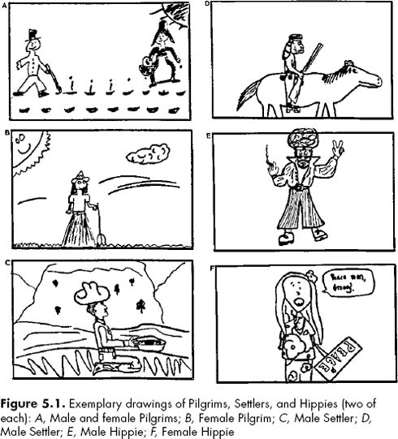

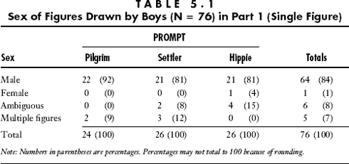

女孩们的回答则不那么直接。虽然年级对结果没有显著影响，但五年级和八年级的女孩对三个提示的反应都与男孩不同（表5.2）。总体而言，女孩们绘制的女性和男性人物数量大致相等。在完成第一部分的80名女孩中，28名（35%）绘制了女性清教徒、定居者或嬉皮士的形象，而26名（33%）绘制了相应的男性形象。然而，这种模式并非在所有提示中都一致。女孩们绘制女性清教徒和嬉皮士的频率高于绘制女性西部定居者（见表5.2）；在回答“定居者”这一提示时，近三分之二的女孩绘制了单个男性形象（23人中有15人，即65%），这表明这些女孩在“描绘”这些历史人物时运用了不同的认知框架。 <sup>19</sup>

Girls' responses were less straightforward. Although no significant effects were found for grade level, girls in both fifth and eighth grades responded differently from the boys to the three prompts (Table 5.2). In general, girls drew approximately equal numbers of female and male figures. Of the eighty girls who completed part 1, twenty-eight (35 percent) drew pictures of female Pilgrims, Settlers, or Hippies, while twenty-six (33 percent) drew their male counterparts. This pattern, however, was not consistent across the prompts. Girls drew female Pilgrims and Hippies more often than female Western Settlers (see Table 5.2); responding to the Settler prompt, almost two-thirds of the girls drew single male figures (fifteen of twenty-three, or 65 percent), suggesting that these girls brought a different schema to bear when “picturing” each of these historical figures.<sup>19</sup>

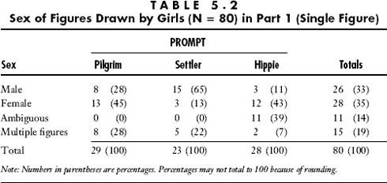

我们发现了男孩和女孩绘画的另一个差异。有20名学生没有按照第一部分的要求画单个人物，而是画了多个人物。如表5.1和表5.2所示，女孩犯这种“错误”的可能性是男孩的三倍。如果“清教徒”、“定居者”或“嬉皮士”这些词不能让人联想到某个特定的历史人物，那么它们会让人联想到什么呢？为了回答这个问题，我们分析了画了多个人物的5名男孩（7%）和15名女孩（19%）的画作（表5.3）。

We discovered another difference between boys's and girls' drawings. Twenty students disregarded the directions in part 1 to draw a single figure and drew multiple figures instead. As shown by the totals of multiple figures in Tables 5.1 and 5.2, girls were three times as likely to make this “mistake” as boys. If “Pilgrim” “Settler” or “Hippie” did not call to mind a picture of a single historical figure, what images did these words elicit? To answer this question, we analyzed the drawings of the five boys (7 percent) and fifteen girls (19 percent) who drew multiple figures (Table 5.3).

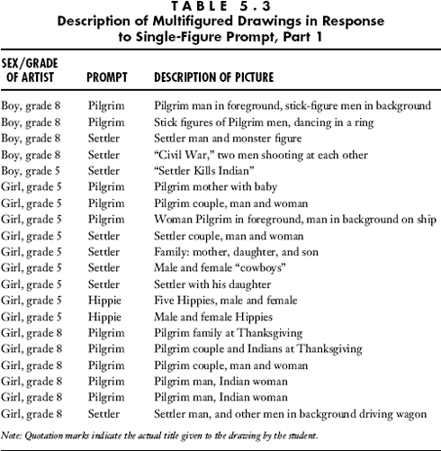

在女孩创作的十五幅多人绘画作品中，有十三幅（87%）描绘了男女在一起的场景，十五幅中有十二幅（80%）描绘了情侣或家庭的形象（见图5.2）。对于这十二位女孩来说，“清教徒”、“定居者”或“嬉皮士”并非以单个人物来表现，而是以家庭或社会单元的形式呈现。

Thirteen of fifteen multiple-figure drawings by girls (87 percent) depicted men and women together, and twelve of the fifteen (80 percent) depicted images of couples or families (see Figure 5.2). For these twelve girls, a “Pilgrim” “Settler” or “Hippie” was represented not by a single figure, but by a family or social unit.

“家庭意象”并非男孩们所描绘的画面。在第一部分中，画多个人物的男孩与只画单个人物的男孩相比，并不更有可能想象一个由女性组成的过去。所有五个画多个人物的男孩都画了男性（表5.3），其中三个男孩的画作带有暴力意味（见图5.3）。换句话说，当男孩们画多个人物时，他们的画作更多地展现的是男性之间的战斗，而非合作。 <sup>20</sup>

The “family image” was not the picture elicited from boys. Boys who drew multiple figures in part 1 were no more likely to envision a past inhabited by women than were the boys who drew single figures. All five of the boys who drew multiple figures drew men (Table 5.3), and in three of five cases the images contained violent overtones (see Figure 5.3). In other words, when boys drew multiple figures, their pictures more often showed men engaged in combat than in cooperation.<sup>20</sup>

如果布置一项任务，要求学生绘制*多个*人物，是否会增加描绘清教徒、定居者和嬉皮士的男女混合形象的数量？为了解答这个问题，我们分析了问卷第二部分的回答。我们想知道，学生在第二部分（要求他们根据一段关于清教徒、定居者或嬉皮士的性别中立段落进行配图）中的回答，与他们在问卷第一部分（要求他们描绘单个人物）中的回答有何不同。

Would a task that instructed students to draw *multiple* figures lead to a greater number of mixed-sex pictures of Pilgrims, Settlers, and Hippies? This question was addressed by examining the responses in part 2 of the questionnaire. We wondered how the student's responses in this section, in which they were asked to illustrate a gender-neutral passage about Pilgrims, Settlers, or Hippies, would compare with their responses in part 1, the depiction of a single figure.

同样，大多数男孩（57%，即完成第二部分的60名男孩中的34名）选择绘制男性形象（表5.4）。虽然这一比例低于第一部分中绘制男性形象的91%（回想一下，男孩们绘制的多人形象中只有男性），但第二部分中没有男孩的画作单独描绘女性。此外，增幅最大的类别并非“男女皆有”，而是“性别模糊”。虽然在画作中包含女性的男孩人数从第一部分的1人（唯一的嬉皮士女性）增加到第二部分的7人，但性别模糊的人物数量却增加了四倍。我们推测，造成这种增长的原因可能包括以下一个或两个：任务的限制使得学生没有足够的时间或动力来完成一幅精细的画作（第二部分中有很多简笔画）；或者，学生被要求描绘的场景（清教徒耕作、定居者乘坐篷车或嬉皮士抗议）不适合描绘特写细节。

Again, a majority of boys (57 percent, or thirty-four of the sixty boys who completed part 2) responded by drawing male figures (Table 5.4). Although this number is less than the 91 percent who drew male figures in part 1 (recall that boys'#x0027;s drawings of multiple figures showed only men), none of the boys'#x0027;s drawings in part 2 depicted women alone. In addition, the category showing the greatest increase was not “both male and female” but “ambiguous.” Although the number of boys who included women in their drawings rose from one in part 1 (the single female Hippie) to seven in part 2, the number of ambiguous figures increased fourfold. Reasons for this rise, we speculated, might include one or both of the following: the constraints of the task left students with little time or motivation to complete a detailed drawing (there were many stick-figure drawings in part 2); or the scene students were asked to illustrate (Pilgrims farming, Settlers in a wagon, or Hippies at a protest) was not suited to close-up detail.

然而，女生的数据对这两种解释都鲜有支持。虽然完成第二部分问卷的男生比第一部分少了16人，但未完成课本段落插图的女生只比男生少了7人，这表明问卷的填写时间是充足的。此外，如表5.5所示，女生回答中被标记为“含糊不清”的比例并没有从第一部分到第二部分显著增加；即使在这些“远景”场景中，女生也提供了足够的细节来区分男性和女性人物。（难道女生只是更认真、更注重细节吗？如果是这样，那么为什么有19%的女生在第一部分中忽略了指示呢？）<sup>21</sup>

The data from girls, however, provided little support for either explanation. While sixteen fewer boys completed part 2 than part 1, only seven fewer girls failed to complete their illustrations of textbook passages, suggesting that the time allotted to complete the questionnaire was adequate. In addition, as Table 5.5 shows, the percentage of girls' responses coded as “ambiguous” did not increase significantly from part 1 to part 2; even in these “far-away” scenes, girls included sufficient detail to distinguish male from female figures. (Are girls simply more conscientious students and more detail-oriented? If this is the case, then why did 19 percent of the girls disregard the directions in part 1?)<sup>21</sup>

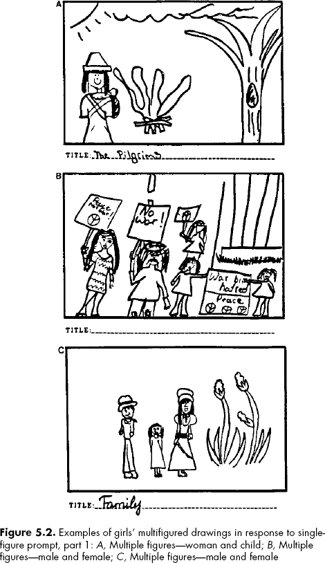

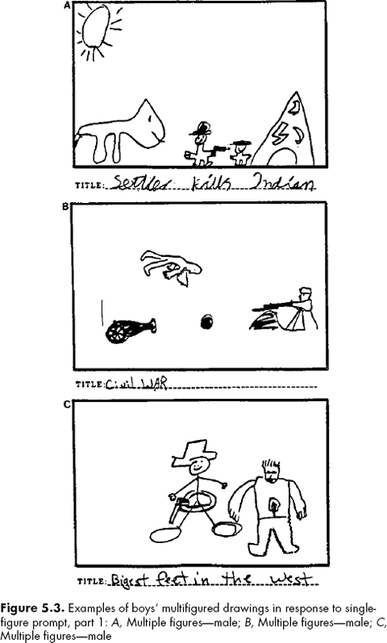

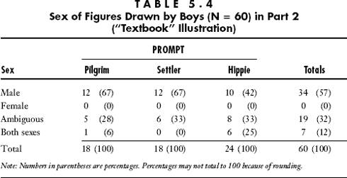

在第二部分中，男孩和女孩的回答还出现了其他差异。虽然课本段落使女孩绘制的包含男性和女性人物的图画数量增加了10%，但同时也使仅包含男性人物的图画数量增加了近10%（9.5%）。然而，与第一部分一样，女孩对三个提示的反应各不相同。阅读课本段落后，女孩绘制男性朝圣者的次数是男孩的两倍多。 与之前相比，这种情况更为常见（59% 对 28%），而第 1 部分和第 2 部分中定居者绘画的模式基本保持不变（表 5.6）。

Additional differences emerged in girls' and boys'#x0027;s responses to part 2. Although the textbook passage elicited from girls a 10 percent increase in the number of drawings that included male and female figures, it also elicited a nearly equal increase (9.5 percent) in the number of drawings containing male figures alone. As with part 1, however, the girls responded differently to each of the three prompts. After reading the textbook passage, girls drew a male Pilgrim or Pilgrims more than twice as often as before (59 percent versus 28 percent), while the pattern of Settler drawings across parts 1 and 2 remained largely unchanged (Table 5.6).

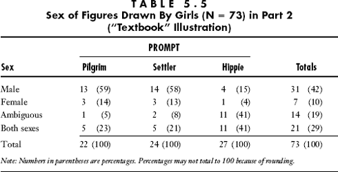

这一发现不仅揭示了女孩们对三种历史提示的不同反应，也揭示了阅读教科书式文章可能对女孩历史观念产生的影响。即使形式和内容都无性别之分，教科书式的散文是否也存在某种特质，会让女孩们误以为过去主要由男性组成？我们不禁思考，为什么阅读一篇关于清教徒（或嬉皮士）的教科书文章会如此深刻地改变女孩们对历史的最初认知，而阅读一篇关于西部拓荒者的文章却几乎不受影响？

This finding speaks not only to the differential responses to the three historical prompts but also to the effect that reading a textbook-like passage may have on girls' conceptions of history. Is there something about textbook-like prose, even when the form and content are gender-neutral, that makes girls imagine that the past was populated mostly by men? And why, we wondered, were girls' initial pictures of the past so greatly altered by reading a textbook passage on Pilgrims (or Hippies), yet minimally affected by a passage on Western Settlers?

这些回答模式促使我们重新审视问卷中是否存在性别偏见。虽然第一部分中的每个提示都只是要求学生“画一个清教徒（西部拓荒者、嬉皮士）”，但第二部分却要求学生画出“清教徒耕作的场景”、“拓荒者乘坐篷车的场景”或“嬉皮士参加抗议的场景”。实际上，这些提示可以被理解为提出了不同的问题：第一部分是“谁是清教徒？”，第二部分是“谁是*耕作的*清教徒？” ；“谁是西部拓荒者？”，第二部分是“谁乘坐拓荒者的篷车？”；“谁是嬉皮士？”，第二部分是“谁参加抗议活动？”。在女孩们的认知中，似乎男性和女性都可以是清教徒，但耕作的清教徒通常是男性。（我们注意到此处存在历史不准确之处，因为除了大规模农业之外，殖民时期的耕作通常由女性承担。）女孩们也把大多数定居者想象成男性，以及少数定居者家庭，这些人正是乘坐马车的人。（然而，似乎女性从未驾驶过马车。）男孩们的回答（表5.7）与女孩们的回答基本相同，只是在“嬉皮士”这一提示的回答上有所不同。男孩和女孩都认为男性、女性（以及许多身份模糊的人物）参与了抗议活动。

These response patterns led us to reexamine our questionnaire for sex bias. Although each of the prompts in part 1 asked students simply to “draw a Pilgrim (Western Settler, Hippie)” the prompts in part 2 asked students to draw a picture of either “Pilgrims farming the land” “Settlers riding in a covered wagon” or “Hippies at a protest.” In effect, these prompts might be construed as asking different questions: “Who is a Pilgrim?” in part 1 versus “Who is a *farming* Pilgrim?” in part 2; “Who is a Western Settler?” versus “Who rides in a Settler wagon?”; and “Who is a Hippie?” versus “Who participates in protests?” In girls' minds, it would seem, both men and women can be Pilgrims, but Pilgrim farmers are men. (We note the historical inaccuracy here, for, with the exception of large-scale agriculture, farming in colonial times was often done by women.) Girls also pictured most Settlers as men, along with a few Settler families, and these are the same people who ride in wagons. (However, it seems that women never drove the wagon.) In boys'#x0027;s responses (Table 5.7), the answers to these questions were largely the same, except in response to the Hippie prompt. For both the boys and the girls, men and women (and many ambiguous figures) participated in protests.

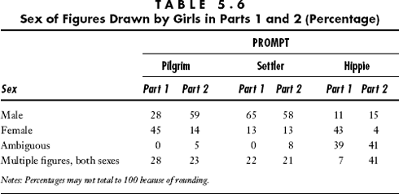

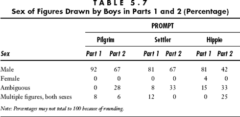

在三个提示中，“嬉皮士”提示引发的差异最大。如表5.6和5.7所示，男孩和女孩的嬉皮士绘画模式都不同于清教徒或定居者的绘画模式。对“嬉皮士”提示的回答也最接近我们预期的结果，即儿童在绘制历史人物时倾向于想象与自己性别相同的人（类似于他们在通用“画人测试”中的回答）。在第一部分中，大多数男孩画的是男性嬉皮士，大多数女孩画的是女性嬉皮士。此外，在第二部分中，男孩和女孩在绘制嬉皮士时，比在绘制清教徒或定居者时更频繁地同时包含男性和女性。虽然仍然不是大多数，但在“嬉皮士”一栏中，同时包含男性和女性形象的图片比例显著增加。（大量模糊不清的人物形象可以被视为反映了“嬉皮士”提示的雌雄同体性质。）

Of the three prompts, the Hippie prompt elicited the greatest variation. For both boys and girls, as shown in Tables 5.6 and 5.7, the pattern of Hippie drawings was different from the patterns of Pilgrim or Settler drawings. Responses to the Hippie prompt also came closest to what we would expect if children possessed a psychological propensity to picture someone of their own sex when drawing a historical figure (similar to their responses in the generic Draw-a-Person Test). Most boys drew male Hippies and most girls drew female Hippies in response to part 1. Additionally, when illustrating the textbook passage in part 2, boys and girls more frequently included both men and women in their drawings of Hippies than in their drawings of Pilgrims or Settlers. Although still not the majority, a sharp increase is seen in the percentage of pictures including both male and female figures in the Hippie column. (The large number of ambiguous figures overall can be seen as reflecting the androgynous nature of the “Hippie” prompt.)

对这一发现的一种可能解释是，我们在嬉皮士绘画中观察到了多样性，描绘的对象涵盖了从越战抗议者、伍德斯托克音乐节参与者到垃圾摇滚爱好者和商场闲逛者等各种人群。这些图像表明，对一些学生来说，嬉皮士并非历史人物，而是生活在当下的人们。这一发现也反映了面向小学和初中学生的历史教科书中对嬉皮士的着墨甚少。具有讽刺意味的是，这些绘画中呈现的男女混合嬉皮士形象在历史上最为准确，而以男性为主导的嬉皮士形象则不然。朝圣者和西部拓荒者——这些学生眼中真正的“历史人物”——并非如此。

One possible explanation of this finding is suggested by the variety we noted in the Hippie drawings, depictions that ranged from Vietnam War protesters and Woodstock attendees to grunge rock enthusiasts and shopping mall loiterers. These images suggest that, for some students, Hippies are not historical figures but people who inhabit the present. This finding also reflects the scant coverage accorded to Hippies in history texts intended for elementary and middle-school students. Ironically, the mixed-sex images of Hippies that emerged from these drawings are historically the most accurate, while the male-biased images of Pilgrims and Western Settlers—the genuine “historical figures” to these students—are not.

讨论

DISCUSSION

这项研究并非对儿童历史观念的深入调查，我们所采用的问卷形式也只能部分揭示儿童如何理解我们布置的任务。*然而*，鉴于我们的目的——了解儿童头脑中的历史意象——这些问卷发挥了有益的作用。它们如同镜子一般，反映了学生对三个历史提示的快速反应，甚至可能是他们无意识的反应，正如艾伦·兰格（Ellen Langer）所定义的那样——一种几乎无需思考的回应。<sup>22</sup>这些图画揭示了学生一些日常的历史观念，这些观念尚未受到“伟大的清教徒女性”或“边疆女牛仔”等专题单元的影响。

This study was not an in-depth investigation of children's conceptions of history, and the form of the questionnaire we administered sheds only partial light on how children construed the task we set for them. However, given our purpose—to understand *something* about the historical images in children's minds—the questionnaires served a useful function. They acted as a kind of mirror for student's quick reactions to three historical prompts, perhaps even their mindless reactions, in the sense in which Ellen Langer uses the term—a response that requires little thinking.<sup>22</sup> The drawings revealed something of student's ordinary historical conceptions, as yet untouched by special units on “Great Pilgrim Women” or “Cowgirls of the Frontier.”

在我们评估的289幅画作中，最引人注目的是男孩和女孩不同的反应模式。我们预感可能会发现同性偏好，尤其是在第一部分中的单人绘画中；我们认为女孩更倾向于画女性形象，而男孩则更倾向于画男性形象。我们也相信第二部分中性别中立的段落会引导学生联想到男性和女性的形象。我们的预测对女孩来说相当准确，她们的画作总体上描绘了一个由男性、女性和儿童组成的过去世界。但即使是女孩，画作中描绘男性形象的比例也最高。在第一部分和第二部分中，女孩共创作了153幅画作，其中58幅（占38%）只画了男性；只画女性的画作只有35幅（占23%）。其余的画作则描绘了男女同时出现（34幅，占22%）或性别模糊的人物形象（25幅，占16%）。

Most striking about the 289 pictures we evaluated are the different response patterns for girls and boys. We had a hunch that we might find a same-sex bias, particularly in the single-figure drawings of part 1; girls, we thought, would more often draw female figures, and boys more male. We also believed that the gender-neutral passages in part 2 would lead students to conjure up images of both men and women. Our predictions turned out to be fairly accurate for girls, whose drawings overall depicted a past populated by men, women, and children. But even for girls, the largest percentage of drawings depicted male figures alone. Of the 153 drawings produced by girls in parts 1 and 2 combined, fifty- eight (or 38 percent) were of men alone; drawings of women alone numbered only thirty-five (23 percent) of the total. The remaining drawings depicted men and women together (thirty-four, or 22 percent) or ambiguous figures (twenty-five, or 16 percent).

我们关注女孩们在描绘类似教科书的段落时，倾向于描绘一个女性少于男性的过去。<sup>23</sup>但我们同样关注男孩们在描绘一个几乎完全由男性主导的过去时的倾向。在这些男孩的画作中，无论是描绘清教徒、定居者还是嬉皮士，女性几乎都隐形。在男孩们创作的136幅画作中，只有8幅（6%）包含女性形象；其中7幅（5%）描绘了男女同时出现，只有1幅（不到1%）描绘了单独的女性。相比之下，男孩们在103幅画作中只画了男性形象。76%的图画清晰可见；其余25幅图画（18%）被判定为含义模糊。如果这些模式表明女孩对过去的认知存在偏差，那么男孩岂不成了一只眼睛瞎了？

We are concerned about girls' tendency, particularly when illustrating textbook-like passages, to depict a past inhabited by fewer women than men.<sup>23</sup> But we are equally concerned about boys'#x0027;s tendency to depict a past inhabited almost exclusively by men. Women are virtually invisible in these boys'#x0027;s pictures, whether they show Pilgrims, Settlers, or Hippies. Of the 136 drawings produced by boys, only eight (6 percent) contained female figures; seven of these (5 percent) depicted men and women together, and only one (less than 1 percent) depicted a woman alone. In contrast, boys drew male figures exclusively in 103 drawings (76 percent); the remaining twenty-five drawings (18 percent) were coded as ambiguous. If these patterns suggest that girls view the past with less than 20–20 vision, then boys are blind in one eye.

只有过去男孩才会这样看待事物吗？现在呢？或许这项研究的结果反映了男孩普遍存在的一种倾向，即无论在哪个时代，除非被明确要求，否则他们倾向于画男性。然而，桑德拉·韦伯和克劳迪娅·米切尔的研究却不支持这种观点。<sup>24</sup>她们研究了600多幅由小学生、实习教师和资深教师根据“画一位老师”这一主题创作的画作。几乎所有这些画作，无论男女学生，画的都是女性。针对批评者认为这种发现是研究主题本身造成的假象，韦伯和米切尔增加了新的主题，例如“画你最喜欢的老师”、“画一位理想的老师”或“画一个课堂”。就老师的形象而言，结果依然一致：“画中典型的老师……是一位白人女性，她站在黑板或课桌前，指着或讲解着。” <sup>25</sup>正如当代教师的形象带有性别色彩一样，历史上的清教徒和定居者的形象也同样如此。我们的研究结果，连同韦伯和米切尔的研究结果，表明任何描绘自我形象的心理倾向都会被文化编码的、指向性别刻板印象的提示所压制。无论这些刻板印象源于过去还是现在，这一结论似乎都成立。

Is it only the past that boys see this way? What about the present? Perhaps the results of this investigation speak to a more generalized tendency among boys to draw males—irrespective of time period—unless explicitly prompted to do otherwise. Such a view, however, is unsupported by the work of Sandra Weber and Claudia Mitchell,<sup>24</sup> who examined over 600 drawings by schoolchildren, student teachers, and experienced teachers in response to the prompt “Draw a teacher.” Nearly every one of these drawings, by male and female students alike, was of a woman. In response to critics who claimed that such findings were artifacts of the research prompt, Weber and Mitchell added new prompts such as “Draw your favorite teacher” “Draw an ideal teacher” or “Draw a class at work.” Insofar as the depiction of the teacher was concerned, the results were consistent: “The typical teacher portrayed in the drawings…was a white woman pointing or expounding, standing in front of a blackboard or desk.”<sup>25</sup> Just as the image of the present-day teacher is gender-coded, so are the historical images of Pilgrims and Settlers. Our findings, together with those of Weber and Mitchell, suggest that any psychological tendency to draw a picture of oneself is overridden by culturally coded prompts that tap into gender stereotypes. This would seem to hold true whether stereotypes are drawn from the past or from the present.

我们如何才能平衡男孩和女孩对历史的认知？有人建议提高女性对历史贡献的重视程度。例如，我们可以庆祝妇女历史月，并在教室里张贴美国著名女性的海报——卢克丽霞·莫特、哈丽特·塔布曼、苏珊·B·安东尼、伊丽莎白·凯迪·斯坦顿和贝蒂·弗里丹。但我们对此仍持怀疑态度。事实上，在我们调查的一间教室里，这五位女性的照片*确实*挂满了墙壁，而且那里的布置方式与其他教室并无二致。

How might we bring balance to both girls' and boys'#x0027;s depictions of the past? One suggestion has been to increase the salience of women's contributions to history. We might, for example, celebrate Women's History Month and line classrooms with posters of famous American women—Lucretia Mott, Harriet Tubman, Susan B. Anthony, Elizabeth Cady Stanton, and Betty Friedan. We remain skeptical. The fact is that pictures of these five women *did* line the walls of one classroom we surveyed, and the patterns there were no different from those in the other classrooms.

在教室墙上张贴杰出女性的照片，或许是出于好意，旨在平衡以男性为主导的历史课程。这类海报在历史和社会研究教科书中也有体现，近年来，这些教科书在整合美国重要女性的贡献方面取得了巨大进步。 <sup>26</sup>但仅仅因为女性占据了更多篇幅就断言教科书现在呈现了平衡的历史观，这是有问题的。正如芭芭拉·莱特及其同事所观察到的。在教科书分析中，关于女性的简短传记和摘录“通常被单独框起来，置于正文之外，强化了她们作为旁注或事后补充的观念。” <sup>27</sup>同样，历史学家琳达·克伯尔指出，女性之所以能进入历史概览课程，仅仅是因为“她们帮助男性做他们想做的事情，无论是开拓边疆还是维持工厂运转；为了博取眼球，比如扮演女巫、妓女或二战中的女飞行员；[或者]参与到女性参政权运动中，而这场运动被认为在1919年就结束了。” <sup>28</sup>